# Assignment 2A — Prompting as System Design

```python
    partial_credit_count = sum(
        record["accuracy_score_0_2"] == 1
        for record in pattern_records
    )

    zero_credit_count = sum(
        record["accuracy_score_0_2"] == 0
        for record in pattern_records
    )

    total_benchmark_tokens = sum(
        int(record["total_tokens"])
        for record in pattern_records
    )

    score_per_1000_tokens = (
        total_accuracy_score
        / total_benchmark_tokens
        * 1000
        if total_benchmark_tokens > 0
        else 0.0
    )

    generation_limit_count = sum(
        bool(record["generation_capped"])
        for record in pattern_records
    )

    fallback_count = sum(
        bool(record["fallback_used"])
        for record in pattern_records
    )

    valid_json_values = [
        record["valid_json"]
        for record in pattern_records
        if record["valid_json"] is not None
    ]

    valid_json_count = (
        sum(bool(value) for value in valid_json_values)
        if valid_json_values
        else None
    )

    summary_record = {
        "pattern": pattern_name,
        "queries": len(pattern_records),

        "total_accuracy_score": (
            total_accuracy_score
        ),
        "maximum_accuracy_score": (
            maximum_accuracy_score
        ),
        "mean_accuracy_score_0_2": round(
            mean(
                record["accuracy_score_0_2"]
                for record in pattern_records
            ),
            4,
        ),
        "normalised_accuracy_percent": round(
            normalised_accuracy_percent,
            2,
        ),

        "full_credit_count": full_credit_count,
        "partial_credit_count": (
            partial_credit_count
        ),
        "zero_credit_count": zero_credit_count,

        "average_input_tokens": round(
            mean(
                int(record["input_tokens"])
                for record in pattern_records
            ),
            2,
        ),
        "average_output_tokens": round(
            mean(
                int(record["output_tokens"])
                for record in pattern_records
            ),
            2,
        ),
        "average_total_tokens": round(
            mean(
                int(record["total_tokens"])
                for record in pattern_records
            ),
            2,
        ),
        "total_benchmark_tokens": (
            total_benchmark_tokens
        ),
        "average_latency_sec": round(
            mean(
                float(record["latency_sec"])
                for record in pattern_records
            ),
            4,
        ),

        "score_per_1000_tokens": round(
            score_per_1000_tokens,
            4,
        ),
        "generation_limit_count": (
            generation_limit_count
        ),
        "fallback_count": fallback_count,
        "valid_json_count": valid_json_count,
    }

    part_a_pattern_summary.append(
        summary_record
    )


# Add rankings without changing the fixed pattern display order.
accuracy_ranking = sorted(
    part_a_pattern_summary,
    key=lambda record: (
        -record["normalised_accuracy_percent"],
        record["average_total_tokens"],
    ),
)

token_efficiency_ranking = sorted(
    part_a_pattern_summary,
    key=lambda record: (
        -record["score_per_1000_tokens"],
        -record["normalised_accuracy_percent"],
    ),
)

latency_ranking = sorted(
    part_a_pattern_summary,
    key=lambda record: (
        record["average_latency_sec"]
    ),
)

accuracy_rank_map = {
    record["pattern"]: rank
    for rank, record in enumerate(
        accuracy_ranking,
        start=1,
    )
}

token_efficiency_rank_map = {
    record["pattern"]: rank
    for rank, record in enumerate(
        token_efficiency_ranking,
        start=1,
    )
}

latency_rank_map = {
    record["pattern"]: rank
    for rank, record in enumerate(
        latency_ranking,
        start=1,
    )
}

for summary_record in part_a_pattern_summary:
    pattern_name = summary_record["pattern"]

    summary_record["accuracy_rank"] = (
        accuracy_rank_map[pattern_name]
    )

    summary_record[
        "token_efficiency_rank"
    ] = token_efficiency_rank_map[
        pattern_name
    ]

    summary_record["latency_rank"] = (
        latency_rank_map[pattern_name]
    )


# ------------------------------------------------------------------
# Save summary artifacts
# ------------------------------------------------------------------

with PART_A_PATTERN_SUMMARY_JSON_PATH.open(
    "w",
    encoding="utf-8",
) as summary_json_file:
    json.dump(
        part_a_pattern_summary,
        summary_json_file,
        indent=2,
        ensure_ascii=False,
    )


summary_csv_fieldnames = [
    "pattern",
    "queries",
    "total_accuracy_score",
    "maximum_accuracy_score",
    "mean_accuracy_score_0_2",
    "normalised_accuracy_percent",
    "full_credit_count",
    "partial_credit_count",
    "zero_credit_count",
    "average_input_tokens",
    "average_output_tokens",
    "average_total_tokens",
    "total_benchmark_tokens",
    "average_latency_sec",
    "score_per_1000_tokens",
    "generation_limit_count",
    "fallback_count",
    "valid_json_count",
    "accuracy_rank",
    "token_efficiency_rank",
    "latency_rank",
]

with PART_A_PATTERN_SUMMARY_CSV_PATH.open(
    "w",
    encoding="utf-8",
    newline="",
) as summary_csv_file:
    writer = csv.DictWriter(
        summary_csv_file,
        fieldnames=summary_csv_fieldnames,
    )

    writer.writeheader()

    for summary_record in part_a_pattern_summary:
        writer.writerow(summary_record)


# ------------------------------------------------------------------
# Save a benchmark-by-pattern score matrix
# ------------------------------------------------------------------

score_lookup = {
    (
        result["benchmark_id"],
        result["pattern"],
    ): result["accuracy_score_0_2"]
    for result in part_a_scored_results
}

with PART_A_SCORE_MATRIX_CSV_PATH.open(
    "w",
    encoding="utf-8",
    newline="",
) as matrix_file:
    matrix_fieldnames = [
        "benchmark_id",
        *PATTERN_REVIEW_ORDER,
    ]
```

```python
    writer = csv.DictWriter(
        matrix_file,
        fieldnames=matrix_fieldnames,
    )

    writer.writeheader()

    for benchmark_number in range(1, 11):
        benchmark_id = (
            f"BQ{benchmark_number:02d}"
        )

        matrix_record = {
            "benchmark_id": benchmark_id,
        }

        for pattern_name in PATTERN_REVIEW_ORDER:
            matrix_record[pattern_name] = (
                score_lookup[
                    (
                        benchmark_id,
                        pattern_name,
                    )
                ]
            )

        writer.writerow(matrix_record)


# ------------------------------------------------------------------
# Final validation
# ------------------------------------------------------------------

scoring_validation_checks = {
    "All fifty responses are present": (
        len(part_a_scored_results) == 50
    ),
    "All fifty responses are manually reviewed": all(
        result["manual_review_completed"]
        for result in part_a_scored_results
    ),
    "All scores are valid": all(
        result["accuracy_score_0_2"]
        in [0, 1, 2]
        for result in part_a_scored_results
    ),
    "Five pattern summaries are present": (
        len(part_a_pattern_summary) == 5
    ),
    "Each pattern contains ten queries": all(
        summary["queries"] == 10
        for summary in part_a_pattern_summary
    ),
    "Maximum score is twenty per pattern": all(
        summary["maximum_accuracy_score"] == 20
        for summary in part_a_pattern_summary
    ),
}


print("FINAL PART A ACCURACY AND COST SUMMARY")
print("=" * 132)

print(
    f"{'Pattern':<20}"
    f"{'Score':>9}"
    f"{'Accuracy':>12}"
    f"{'2s':>6}"
    f"{'1s':>6}"
    f"{'0s':>6}"
    f"{'Avg Tokens':>14}"
    f"{'Avg Latency':>15}"
    f"{'Score/1K Tok':>16}"
)

print("-" * 132)

for summary in part_a_pattern_summary:
    print(
        f"{summary['pattern']:<20}"
        f"{summary['total_accuracy_score']:>5}/20"
        f"{summary['normalised_accuracy_percent']:>11.2f}%"
        f"{summary['full_credit_count']:>6}"
        f"{summary['partial_credit_count']:>6}"
        f"{summary['zero_credit_count']:>6}"
        f"{summary['average_total_tokens']:>14.2f}"
        f"{summary['average_latency_sec']:>14.4f}s"
        f"{summary['score_per_1000_tokens']:>16.4f}"
    )

print("=" * 132)

for check_name, passed in scoring_validation_checks.items():
    print(
        f"{check_name:<58} : "
        f"{'PASS' if passed else 'FAIL'}"
    )

print("-" * 132)
print(
    f"Scored JSON   : "
    f"{PART_A_SCORED_RESULTS_JSON_PATH}"
)
print(
    f"Scored CSV    : "
    f"{PART_A_SCORED_RESULTS_CSV_PATH}"
)
print(
    f"Summary JSON  : "
    f"{PART_A_PATTERN_SUMMARY_JSON_PATH}"
)
print(
    f"Summary CSV   : "
    f"{PART_A_PATTERN_SUMMARY_CSV_PATH}"
)
print(
    f"Score matrix  : "
    f"{PART_A_SCORE_MATRIX_CSV_PATH}"
)
print("=" * 132)


if not all(scoring_validation_checks.values()):
    failed_checks = [
        check_name
        for check_name, passed
        in scoring_validation_checks.items()
        if not passed
    ]

    raise RuntimeError(
        "Final Part A scoring validation failed for: "
        + ", ".join(failed_checks)
    )

print(
    "Final Part A accuracy consolidation completed successfully."
)
```

```
FINAL PART A ACCURACY AND COST SUMMARY
====================================================================================================================================
Pattern                 Score    Accuracy    2s    1s    0s    Avg Tokens    Avg Latency    Score/1K Tok
------------------------------------------------------------------------------------------------------------------------------------
Zero-Shot               7/20      35.00%     1     5     4        274.80       12.5842s          2.5473
Few-Shot                7/20      35.00%     2     3     5       2008.20       12.1391s          0.3486
Instruction             3/20      15.00%     0     3     7        356.30        9.8973s          0.8420
Self-Critique           5/20      25.00%     2     1     7       1351.10       28.3795s          0.3701
Function-Calling        3/20      15.00%     0     3     7        519.20        9.2275s          0.5778
====================================================================================================================================
All fifty responses are present                            : PASS
All fifty responses are manually reviewed                  : PASS
All scores are valid                                       : PASS
Five pattern summaries are present                         : PASS
Each pattern contains ten queries                          : PASS
Maximum score is twenty per pattern                        : PASS
------------------------------------------------------------------------------------------------------------------------------------
Scored JSON   : /home/jovyan/llmlab/assignment2a_workspace_20260731_182730/benchmarks/part_a_scored_results.json
Scored CSV    : /home/jovyan/llmlab/assignment2a_workspace_20260731_182730/benchmarks/part_a_scored_results.csv
Summary JSON  : /home/jovyan/llmlab/assignment2a_workspace_20260731_182730/reports/part_a_pattern_summary.json
Summary CSV   : /home/jovyan/llmlab/assignment2a_workspace_20260731_182730/reports/part_a_pattern_summary.csv
Score matrix  : /home/jovyan/llmlab/assignment2a_workspace_20260731_182730/reports/part_a_accuracy_score_matrix.csv
====================================================================================================================================
Final Part A accuracy consolidation completed successfully.
```

##### Observation

🔝 Back to Index

Zero-Shot and Few-Shot tied for the highest Part A accuracy at **35%**, but they reached that score with very different inference cost. Zero-Shot used approximately **86% fewer tokens** than Few-Shot, so its score per 1,000 tokens was substantially stronger. The result shows that demonstrations did not add enough task-specific evidence to justify their prompt overhead on this benchmark.

Self-Critique produced two full-credit answers, confirming that revision can repair selected responses, but the three-call chain also produced the highest latency and repeatedly reached the generation limit. Instruction and Function-Calling offered useful structure, yet lower technical accuracy prevented either from becoming the default. The decision therefore uses both quality and cost rather than selecting the most elaborate prompt.

#### 7.7 Part A Comparative Analysis and Cost–Quality Decision

🔝 Back to Index

##### Purpose

This section produces the final comparison of the five prompting patterns and identifies the most suitable pattern for the IT helpdesk use case.

##### Selection Criteria

The comparison considers:

- Accuracy score
- Average token consumption
- Average latency
- Full-credit and partial-credit responses
- Score obtained per 1,000 tokens
- Operational complexity and number of model calls

When two patterns achieve the same accuracy, the pattern with lower token consumption and lower implementation complexity is preferred.

```python
import json


PART_A_COMPARATIVE_ANALYSIS_JSON_PATH = (
    REPORTS_DIR
    / "part_a_comparative_analysis.json"
)

PART_A_COMPARATIVE_ANALYSIS_MD_PATH = (
    REPORTS_DIR
    / "part_a_comparative_analysis.md"
)


# Exact 75-word comparative interpretation
part_a_75_word_analysis = """
Zero-shot and few-shot tied for the highest accuracy at 35%, but zero-shot was far more efficient, using 274.8 average tokens versus 2008.2. Self-critique achieved 25% accuracy but incurred the highest latency and large token cost. Instruction and function-calling were fastest, yet both reached only 15% accuracy. Overall, zero-shot offered the strongest cost-quality balance, while few-shot improved some complex cases at substantial prompt overhead. Self-critique did not justify its three-call expense under this fixed benchmark configuration.
""".strip()


analysis_word_count = len(
    part_a_75_word_analysis.split()
)


summary_by_pattern = {
    summary["pattern"]: summary
    for summary in part_a_pattern_summary
}


# Rank patterns by:
# 1. Accuracy
# 2. Score per 1,000 tokens
# 3. Lower latency
cost_quality_ranking = sorted(
    part_a_pattern_summary,
    key=lambda summary: (
        -summary["normalised_accuracy_percent"],
        -summary["score_per_1000_tokens"],
        summary["average_latency_sec"],
    ),
)


selected_pattern = cost_quality_ranking[0]


few_shot_token_overhead_percent = (
    (
        summary_by_pattern["Few-Shot"][
            "average_total_tokens"
        ]
        - summary_by_pattern["Zero-Shot"][
            "average_total_tokens"
        ]
    )
    / summary_by_pattern["Few-Shot"][
        "average_total_tokens"
    ]
    * 100
)


self_critique_latency_multiplier = (
    summary_by_pattern["Self-Critique"][
        "average_latency_sec"
    ]
    / summary_by_pattern["Zero-Shot"][
        "average_latency_sec"
    ]
)


part_a_comparative_analysis = {
    "evaluation_scope": {
        "patterns": 5,
        "benchmark_queries_per_pattern": 10,
        "total_scored_responses": 50,
        "accuracy_scale": "0-2",
        "maximum_score_per_pattern": 20,
    },
    "pattern_metrics": part_a_pattern_summary,
    "cost_quality_ranking": [
        {
            "rank": rank,
            "pattern": summary["pattern"],
            "accuracy_percent": (
                summary[
                    "normalised_accuracy_percent"
                ]
            ),
            "score_per_1000_tokens": (
                summary[
                    "score_per_1000_tokens"
                ]
            ),
            "average_tokens": (
                summary[
                    "average_total_tokens"
                ]
            ),
            "average_latency_sec": (
                summary[
                    "average_latency_sec"
                ]
            ),
        }
        for rank, summary in enumerate(
            cost_quality_ranking,
            start=1,
        )
    ],
    "selected_pattern": selected_pattern["pattern"],
    "selection_reason": (
        "Zero-Shot tied for the highest accuracy while "
        "achieving the highest score per 1,000 tokens and "
        "requiring only one model call with no demonstration "
        "or critique overhead."
    ),
    "additional_findings": {
        "few_shot_token_reduction_if_zero_shot_used_percent": round(
            few_shot_token_overhead_percent,
            2,
        ),
        "self_critique_latency_vs_zero_shot_multiplier": round(
            self_critique_latency_multiplier,
            2,
        ),
        "highest_accuracy_patterns": [
            "Zero-Shot",
            "Few-Shot",
        ],
        "lowest_latency_pattern": min(
            part_a_pattern_summary,
            key=lambda summary: (
                summary["average_latency_sec"]
            ),
        )["pattern"],
        "highest_token_efficiency_pattern": max(
            part_a_pattern_summary,
            key=lambda summary: (
                summary["score_per_1000_tokens"]
            ),
        )["pattern"],
    },
    "required_75_word_analysis": (
        part_a_75_word_analysis
    ),
    "analysis_word_count": analysis_word_count,
}


with PART_A_COMPARATIVE_ANALYSIS_JSON_PATH.open(
    "w",
    encoding="utf-8",
) as analysis_json_file:
    json.dump(
        part_a_comparative_analysis,
        analysis_json_file,
        indent=2,
        ensure_ascii=False,
    )


comparison_table_lines = [
    "| Pattern | Score | Accuracy | Avg. Tokens | Avg. Latency | Score/1K Tokens |",
    "|---|---:|---:|---:|---:|---:|",
]

for summary in part_a_pattern_summary:
    comparison_table_lines.append(
        f"| {summary['pattern']} "
        f"| {summary['total_accuracy_score']}/20 "
        f"| {summary['normalised_accuracy_percent']:.2f}% "
        f"| {summary['average_total_tokens']:.2f} "
        f"| {summary['average_latency_sec']:.4f} s "
        f"| {summary['score_per_1000_tokens']:.4f} |"
    )


comparison_markdown = "\n".join(
    [
        "# Part A Comparative Analysis",
        "",
        "## Pattern Comparison",
        "",
        *comparison_table_lines,
        "",
        "## Cost–Quality Decision",
        "",
        (
            f"**Selected pattern: "
            f"{selected_pattern['pattern']}**"
        ),
        "",
        part_a_comparative_analysis[
            "selection_reason"
        ],
        "",
        "## Required 75-Word Analysis",
        "",
        part_a_75_word_analysis,
        "",
        (
            f"**Validated word count:** "
            f"{analysis_word_count}"
        ),
    ]
)


with PART_A_COMPARATIVE_ANALYSIS_MD_PATH.open(
    "w",
    encoding="utf-8",
) as analysis_markdown_file:
    analysis_markdown_file.write(
        comparison_markdown
    )


comparison_validation_checks = {
    "Five patterns compared": (
        len(part_a_pattern_summary) == 5
    ),
    "Seventy-five-word analysis validated": (
        analysis_word_count == 75
    ),
    "Selected pattern is available": (
        selected_pattern["pattern"]
        in PATTERN_REVIEW_ORDER
    ),
    "JSON analysis artifact created": (
        PART_A_COMPARATIVE_ANALYSIS_JSON_PATH.exists()
    ),
    "Markdown analysis artifact created": (
        PART_A_COMPARATIVE_ANALYSIS_MD_PATH.exists()
    ),
}


print("PART A COMPARATIVE ANALYSIS")
print("=" * 120)

print(
    f"{'Rank':<6}"
    f"{'Pattern':<22}"
    f"{'Accuracy':>12}"
    f"{'Avg Tokens':>15}"
    f"{'Avg Latency':>16}"
    f"{'Score/1K Tok':>16}"
)

print("-" * 120)

for rank, summary in enumerate(
    cost_quality_ranking,
    start=1,
):
    print(
        f"{rank:<6}"
        f"{summary['pattern']:<22}"
        f"{summary['normalised_accuracy_percent']:>11.2f}%"
        f"{summary['average_total_tokens']:>15.2f}"
        f"{summary['average_latency_sec']:>15.4f}s"
        f"{summary['score_per_1000_tokens']:>16.4f}"
    )

print("=" * 120)
print(
    f"Selected cost-quality pattern : "
    f"{selected_pattern['pattern']}"
)
print(
    f"75-word analysis count        : "
    f"{analysis_word_count}"
)
print("-" * 120)
print(part_a_75_word_analysis)
print("-" * 120)

for check_name, passed in comparison_validation_checks.items():
    print(
        f"{check_name:<52} : "
        f"{'PASS' if passed else 'FAIL'}"
    )

print("-" * 120)
print(
    f"JSON analysis : "
    f"{PART_A_COMPARATIVE_ANALYSIS_JSON_PATH}"
)
print(
    f"Markdown report: "
    f"{PART_A_COMPARATIVE_ANALYSIS_MD_PATH}"
)
print("=" * 120)


if not all(
    comparison_validation_checks.values()
):
    failed_checks = [
        check_name
        for check_name, passed
        in comparison_validation_checks.items()
        if not passed
    ]

    raise RuntimeError(
        "Part A comparative-analysis validation failed for: "
        + ", ".join(failed_checks)
    )

print(
    "Part A comparative analysis completed successfully."
)
```

```
PART A COMPARATIVE ANALYSIS
========================================================================================================================
Rank  Pattern                   Accuracy     Avg Tokens     Avg Latency    Score/1K Tok
------------------------------------------------------------------------------------------------------------------------
1     Zero-Shot                   35.00%         274.80        12.5842s          2.5473
2     Few-Shot                    35.00%        2008.20        12.1391s          0.3486
3     Self-Critique               25.00%        1351.10        28.3795s          0.3701
4     Instruction                 15.00%         356.30         9.8973s          0.8420
5     Function-Calling            15.00%         519.20         9.2275s          0.5778
========================================================================================================================
Selected cost-quality pattern : Zero-Shot
75-word analysis count        : 75
------------------------------------------------------------------------------------------------------------------------
Zero-shot and few-shot tied for the highest accuracy at 35%, but zero-shot was far more efficient, using 274.8 average tokens versus 2008.2. Self-critique achieved 25% accuracy but incurred the highest latency and large token cost. Instruction and function-calling were fastest, yet both reached only…
------------------------------------------------------------------------------------------------------------------------
Five patterns compared                               : PASS
Seventy-five-word analysis validated                 : PASS
Selected pattern is available                        : PASS
JSON analysis artifact created                       : PASS
Markdown analysis artifact created                   : PASS
------------------------------------------------------------------------------------------------------------------------
JSON analysis : /home/jovyan/llmlab/assignment2a_workspace_20260731_182730/reports/part_a_comparative_analysis.json
Markdown report: /home/jovyan/llmlab/assignment2a_workspace_20260731_182730/reports/part_a_comparative_analysis.md
========================================================================================================================
Part A comparative analysis completed successfully.
```

##### Observation

🔝 Back to Index

Part A establishes **Zero-Shot** as the default single pattern because it tied for the best measured accuracy while achieving the strongest accuracy-to-token ratio. This is a cost–quality decision, not a claim that Zero-Shot solved every query: its 35% accuracy also exposes the limits of the adapted 3B model on exact command sequences and source-specific technical details.

Few-Shot remains useful when a query genuinely benefits from a closely matched worked example. Function-Calling remains useful when valid structure is the primary objective. Self-Critique is reserved for cases where revision value outweighs three-call latency. Part B tests whether explicit reasoning changes these conclusions on harder multi-step incidents.

##### Visualization — Part A Accuracy, Cost, and the Full Score Matrix

🔝 Back to Index

The five prompting patterns above are compared only in text and tables so far. The two panels below turn `part_a_pattern_summary` and the saved benchmark-by-pattern score matrix into a single visual: the left panel makes the accuracy-vs-token trade-off immediately visible (bar height = accuracy, marker = average tokens on a log-scaled twin axis), and the right panel is a 5×10 heatmap of every individual BQ01–BQ10 score, so patterns of *where* each pattern succeeded or failed are visible at a glance rather than buried in ten separate manual-review cells.

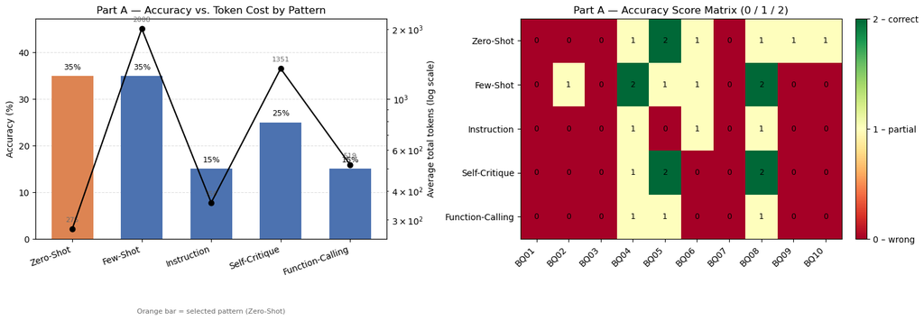

```
Figure summary: bar/line panel repeats the numbers already printed in Section 7.7; heatmap panel is a new view built from the same `score_lookup` matrix saved to part_a_accuracy_score_matrix.csv.
```

```python
# Visualization — Part A accuracy/cost comparison + score-matrix heatmap
import matplotlib.pyplot as plt
import numpy as np

patterns = [s["pattern"] for s in part_a_pattern_summary]
accuracy_pct = [s["normalised_accuracy_percent"] for s in part_a_pattern_summary]
avg_tokens = [s["average_total_tokens"] for s in part_a_pattern_summary]

fig, axes = plt.subplots(1, 2, figsize=(15, 5.5))

# --- Panel 1: accuracy (bars) vs average tokens (line, log-scaled twin axis) ---
ax1 = axes[0]
bar_colors = ["#4C72B0" if p != part_a_comparative_analysis["selected_pattern"] else "#DD8452"
              for p in patterns]
bars = ax1.bar(patterns, accuracy_pct, color=bar_colors, width=0.6, zorder=3)
ax1.set_ylabel("Accuracy (%)")
ax1.set_ylim(0, max(accuracy_pct) * 1.35)
ax1.set_title("Part A — Accuracy vs. Token Cost by Pattern")
ax1.grid(axis="y", linestyle="--", alpha=0.4, zorder=0)
for bar, val in zip(bars, accuracy_pct):
    ax1.text(bar.get_x() + bar.get_width() / 2, val + 1, f"{val:.0f}%",
             ha="center", va="bottom", fontsize=9)
plt.setp(ax1.get_xticklabels(), rotation=20, ha="right")

ax1b = ax1.twinx()
ax1b.plot(patterns, avg_tokens, color="black", marker="o", linewidth=1.6, zorder=4)
ax1b.set_yscale("log")
ax1b.set_ylabel("Average total tokens (log scale)")
for x, val in zip(patterns, avg_tokens):
    ax1b.annotate(f"{val:.0f}", (x, val), textcoords="offset points",
                  xytext=(0, 8), ha="center", fontsize=8, color="dimgray")

ax1.text(0.5, -0.34,
         f"Orange bar = selected pattern ({part_a_comparative_analysis['selected_pattern']})",
         transform=ax1.transAxes, ha="center", fontsize=8, color="dimgray")

# --- Panel 2: heatmap of the full 5x10 score matrix ---
ax2 = axes[1]
benchmark_ids = [f"BQ{n:02d}" for n in range(1, 11)]
matrix = np.array([
    [score_lookup[(bq, pattern)] for bq in benchmark_ids]
    for pattern in patterns
])

im = ax2.imshow(matrix, cmap="RdYlGn", vmin=0, vmax=2, aspect="auto")
ax2.set_xticks(range(len(benchmark_ids)))
ax2.set_xticklabels(benchmark_ids, rotation=45, ha="right")
ax2.set_yticks(range(len(patterns)))
ax2.set_yticklabels(patterns)
ax2.set_title("Part A — Accuracy Score Matrix (0 / 1 / 2)")

for r in range(matrix.shape[0]):
    for c in range(matrix.shape[1]):
        ax2.text(c, r, str(matrix[r, c]), ha="center", va="center",
                 fontsize=9, color="black")

cbar = fig.colorbar(im, ax=ax2, fraction=0.046, pad=0.04, ticks=[0, 1, 2])
cbar.ax.set_yticklabels(["0 – wrong", "1 – partial", "2 – correct"])

plt.tight_layout()
plt.show()

print(
    "Figure summary: bar/line panel repeats the numbers already printed in "
    "Section 7.7; heatmap panel is a new view built from the same "
    "`score_lookup` matrix saved to part_a_accuracy_score_matrix.csv."
)
```

## 8. Part B — Reasoning and Custom Chains

🔝 Back to Index

### 8.1 Multi-Step Domain Problem Design

#### Purpose

This section defines two additional IT helpdesk and incident-resolution problems that require reasoning across multiple technical observations.

#### Problem Selection Rationale

The two problems represent distinct enterprise support scenarios:

1. **Post-change VPN gateway outage**
   - Requires correlation of WireGuard, IPv4 forwarding, NAT, `systemd`, persistence, verification, and rollback evidence.
   - Includes several plausible remediation paths, making it suitable for Chain-of-Thought, Tree-of-Thought, and Self-Consistency.
2. **Compromised Linux administrator account**
   - Requires containment, evidence preservation, session termination, account protection, persistence removal, vulnerability remediation, recovery, and monitoring.
   - Represents a high-stakes incident where operational sequence and verification are critical.

These are additional benchmark problems created specifically for Part B. They do not introduce new training data and are not included in the Part A accuracy results.

#### Evaluation Approach

Each problem contains:

- Confirmed observations
- Required technical outcomes
- Material-error conditions
- A reference resolution outline
- Expected tools or commands
- Intended reasoning challenges

The reference outlines are used only for evaluation and are not included in the model prompts.

```python
import csv
import json


PART_B_PROBLEMS_JSON_PATH = (
    DATA_DIR
    / "part_b_multistep_problems.json"
)

PART_B_PROBLEMS_CSV_PATH = (
    DATA_DIR
    / "part_b_multistep_problems.csv"
)

PART_B_PROBLEM_DESIGN_REPORT_PATH = (
    REPORTS_DIR
    / "part_b_problem_design.json"
)


part_b_multistep_problems = [
    {
        "problem_id": "MSP01",
        "title": "Post-Change VPN Gateway Outage",
        "domain": "network_connectivity",
        "risk_level": "high",
        "query": (
            "After a planned gateway change, WireGuard clients in "
            "subnet 10.90.90.0/24 can still complete a handshake with "
            "gateway0, but they cannot reach internal services or the "
            "internet. The gateway uses eth0 as its outbound interface. "
            "The command 'cat /proc/sys/net/ipv4/ip_forward' returns 0, "
            "the NAT POSTROUTING table has no MASQUERADE rule for the "
            "VPN subnet, and systemd reports that the gateway0 unit file "
            "changed on disk. Prepare a safe recovery procedure with "
            "diagnostic reasoning, remediation order, persistence, "
            "verification, and rollback considerations."
        ),
        "confirmed_observations": [
            "WireGuard handshake succeeds.",
            "VPN subnet is 10.90.90.0/24.",
            "Outbound interface is eth0.",
            "net.ipv4.ip_forward currently evaluates to 0.",
            "No subnet-specific MASQUERADE rule is present.",
            "The gateway0 systemd unit changed on disk.",
        ],
        "critical_requirements": [
            (
                "Uses the successful handshake to avoid unnecessary "
                "key or peer reconfiguration."
            ),
            (
                "Captures current sysctl, routing, firewall, service, "
                "and log state before making changes."
            ),
            (
                "Runs systemctl daemon-reload after the unit-file change."
            ),
            (
                "Enables net.ipv4.ip_forward=1 and applies the "
                "persistent sysctl configuration."
            ),
            (
                "Adds a POSTROUTING MASQUERADE rule for "
                "10.90.90.0/24 through eth0."
            ),
            "Persists the NAT rule across reboot.",
            (
                "Verifies service state, forwarding, NAT, routing, "
                "WireGuard status, and end-to-end connectivity."
            ),
            "Defines rollback or restoration steps.",
        ],
        "supporting_requirements": [
            "Validates the systemd unit before restarting it.",
            "Checks FORWARD-chain policy when traffic remains blocked.",
            "Uses iptables-save or an equivalent backup before changes.",
            "Avoids unnecessary gateway reboot.",
        ],
        "material_errors": [
            "Regenerates WireGuard keys despite a successful handshake.",
            "Uses a VPN subnet other than 10.90.90.0/24.",
            "Uses an outbound interface other than eth0.",
            "Adds only a temporary NAT rule without persistence.",
            "Restarts services before recording relevant evidence.",
        ],
        "reference_resolution_outline": [
            (
                "Record current evidence using wg show, ip route, "
                "sysctl net.ipv4.ip_forward, iptables-save, "
                "systemctl status gateway0, and journalctl."
            ),
            "Validate the modified gateway0 unit file.",
            "Run systemctl daemon-reload.",
            (
                "Create or update a sysctl configuration containing "
                "net.ipv4.ip_forward = 1."
            ),
            "Apply the sysctl configuration.",
            (
                "Add iptables -t nat -A POSTROUTING "
                "-s 10.90.90.0/24 -o eth0 -j MASQUERADE."
            ),
            "Persist the NAT rule using the approved host mechanism.",
            "Restart or start gateway0 only when required.",
            (
                "Verify the forwarding value, NAT counters, routes, "
                "WireGuard handshake, DNS, internal access, and internet access."
            ),
            (
                "Rollback using the saved firewall rules, previous "
                "sysctl configuration, and previous systemd unit."
            ),
        ],
        "reasoning_challenges": [
            "Separate healthy WireGuard negotiation from broken routing.",
            "Order evidence capture before remediation.",
            "Coordinate kernel, firewall, and service configuration.",
            "Select a safe recovery path among multiple alternatives.",
        ],
        "intended_part_b_techniques": [
            "plain_single_call",
            "chain_of_thought",
            "tree_of_thought",
            "self_consistency",
            "plan_solve_verify",
        ],
    },
    {
        "problem_id": "MSP02",
        "title": "Compromised Administrator Account and Persistence",
        "domain": "security_incident",
        "risk_level": "critical",
        "query": (
            "A Linux production server has an active SSH session for "
            "opsuser from an unrecognised address. The user's "
            "authorized_keys file contains an unknown key, a suspicious "
            "backup-sync.service unit is enabled, and the same vulnerable "
            "package exists on three related hosts. Logs and volatile "
            "evidence are still available on the affected server. "
            "Prepare a containment, evidence-preservation, eradication, "
            "recovery, and verification procedure that minimises the "
            "risk of incomplete remediation."
        ),
        "confirmed_observations": [
            "An unrecognised active SSH session exists for opsuser.",
            "An unknown key is present in authorized_keys.",
            "A suspicious backup-sync.service unit is enabled.",
            "A vulnerable package exists on three related hosts.",
            "Logs and volatile evidence remain available.",
        ],
        "critical_requirements": [
            "Contains or isolates the affected host.",
            (
                "Preserves volatile evidence, logs, process state, "
                "network state, and suspicious files before destructive action."
            ),
            (
                "Disables or protects opsuser and removes or quarantines "
                "the unknown authorised key."
            ),
            "Identifies and terminates only the compromised sessions.",
            (
                "Examines and removes the suspicious systemd "
                "persistence mechanism after evidence collection."
            ),
            "Scopes the three related hosts for the same indicators.",
            "Patches or mitigates the vulnerable package.",
            "Rotates affected credentials and secrets.",
            (
                "Restores or rebuilds from a trusted source when "
                "system integrity cannot be established."
            ),
            (
                "Validates eradication before reconnecting the host "
                "and monitors for recurrence."
            ),
        ],
        "supporting_requirements": [
            "Captures hashes and metadata for suspicious files.",
            "Preserves a timeline of actions and evidence.",
            "Checks external or central identity sources.",
            "Blocks identified indicators of compromise.",
            "Documents recovery acceptance criteria.",
        ],
        "material_errors": [
            "Immediately deletes files or wipes the host before evidence capture.",
            "Kills every sshd process instead of the identified user session.",
            "Reconnects the server before eradication validation.",
            "Treats disabling opsuser as complete remediation.",
            "Patches only the first host and ignores the related hosts.",
        ],
        "reference_resolution_outline": [
            "Activate the incident-response process and preserve a timeline.",
            (
                "Isolate the host through controlled network containment "
                "while preserving authorised responder access."
            ),
            (
                "Capture active sessions, processes, sockets, memory where "
                "authorised, logs, unit definitions, and file hashes."
            ),
            (
                "Disable opsuser in local and central identity systems, "
                "quarantine the unknown key, and terminate identified sessions."
            ),
            (
                "Inspect backup-sync.service, its executable, dependencies, "
                "timers, environment, and associated persistence artefacts."
            ),
            (
                "Stop and disable the malicious unit after evidence capture "
                "and remove confirmed malicious artefacts."
            ),
            (
                "Search all three related hosts for the same account, key, "
                "unit, hashes, network indicators, and vulnerable package."
            ),
            "Patch or mitigate the vulnerability across the affected scope.",
            "Rotate credentials, keys, tokens, and relevant service secrets.",
            (
                "Rebuild or restore from a trusted source when integrity "
                "cannot be confidently verified."
            ),
            (
                "Validate accounts, services, persistence points, packages, "
                "logs, and monitoring before reconnecting systems."
            ),
            "Monitor for recurrence and complete incident documentation.",
        ],
        "reasoning_challenges": [
            "Balance rapid containment with evidence preservation.",
            "Distinguish account revocation from complete eradication.",
            "Coordinate host-level and cross-host investigation.",
            "Determine when cleaning is sufficient versus trusted rebuild.",
        ],
        "intended_part_b_techniques": [
            "plain_single_call",
            "chain_of_thought",
            "tree_of_thought",
            "self_consistency",
            "plan_solve_verify",
            "react",
        ],
    },
]
```

```python
# ------------------------------------------------------------------
# Validate the two additional problems
# ------------------------------------------------------------------

required_problem_fields = {
    "problem_id",
    "title",
    "domain",
    "risk_level",
    "query",
    "confirmed_observations",
    "critical_requirements",
    "supporting_requirements",
    "material_errors",
    "reference_resolution_outline",
    "reasoning_challenges",
    "intended_part_b_techniques",
}

problem_ids = [
    problem["problem_id"]
    for problem in part_b_multistep_problems
]

benchmark_ids = {
    record["benchmark_id"]
    for record in benchmark_query_draft
}


problem_validation_checks = {
    "Exactly two multi-step problems are defined": (
        len(part_b_multistep_problems) == 2
    ),
    "Problem identifiers are unique": (
        len(problem_ids) == len(set(problem_ids))
    ),
    "Problem identifiers do not overlap Part A": (
        not set(problem_ids).intersection(benchmark_ids)
    ),
    "All required fields are present": all(
        required_problem_fields.issubset(problem)
        for problem in part_b_multistep_problems
    ),
    "Every problem has critical requirements": all(
        problem["critical_requirements"]
        for problem in part_b_multistep_problems
    ),
    "Every problem has a reference outline": all(
        problem["reference_resolution_outline"]
        for problem in part_b_multistep_problems
    ),
    "Every problem supports CoT, ToT, and Self-Consistency": all(
        {
            "chain_of_thought",
            "tree_of_thought",
            "self_consistency",
        }.issubset(
            problem["intended_part_b_techniques"]
        )
        for problem in part_b_multistep_problems
    ),
}


# ------------------------------------------------------------------
# Save JSON and CSV artifacts
# ------------------------------------------------------------------

with PART_B_PROBLEMS_JSON_PATH.open(
    "w",
    encoding="utf-8",
) as json_file:
    json.dump(
        part_b_multistep_problems,
        json_file,
        indent=2,
        ensure_ascii=False,
    )


csv_fieldnames = [
    "problem_id",
    "title",
    "domain",
    "risk_level",
    "query",
    "confirmed_observations",
    "critical_requirements",
    "supporting_requirements",
    "material_errors",
    "reference_resolution_outline",
    "reasoning_challenges",
    "intended_part_b_techniques",
]

with PART_B_PROBLEMS_CSV_PATH.open(
    "w",
    encoding="utf-8",
    newline="",
) as csv_file:
    writer = csv.DictWriter(
        csv_file,
        fieldnames=csv_fieldnames,
    )

    writer.writeheader()

    for problem in part_b_multistep_problems:
        csv_record = dict(problem)

        for list_field in [
            "confirmed_observations",
            "critical_requirements",
            "supporting_requirements",
            "material_errors",
            "reference_resolution_outline",
            "reasoning_challenges",
            "intended_part_b_techniques",
        ]:
            csv_record[list_field] = json.dumps(
                csv_record[list_field],
                ensure_ascii=False,
            )

        writer.writerow(csv_record)


problem_design_report = {
    "part": "Part B",
    "section": "Multi-step domain problem design",
    "problem_count": len(part_b_multistep_problems),
    "problem_ids": problem_ids,
    "domains": [
        problem["domain"]
        for problem in part_b_multistep_problems
    ],
    "risk_levels": [
        problem["risk_level"]
        for problem in part_b_multistep_problems
    ],
    "validation_checks": problem_validation_checks,
    "json_artifact": str(
        PART_B_PROBLEMS_JSON_PATH
    ),
    "csv_artifact": str(
        PART_B_PROBLEMS_CSV_PATH
    ),
}

with PART_B_PROBLEM_DESIGN_REPORT_PATH.open(
    "w",
    encoding="utf-8",
) as report_file:
    json.dump(
        problem_design_report,
        report_file,
        indent=2,
        ensure_ascii=False,
    )


print("PART B MULTI-STEP DOMAIN PROBLEMS")
print("=" * 105)

for problem in part_b_multistep_problems:
    print(
        f"{problem['problem_id']} | "
        f"{problem['title']} | "
        f"Domain: {problem['domain']} | "
        f"Risk: {problem['risk_level']}"
    )
    print(
        f"  Critical requirements : "
        f"{len(problem['critical_requirements'])}"
    )
    print(
        f"  Material errors       : "
        f"{len(problem['material_errors'])}"
    )
    print(
        f"  Reasoning challenges  : "
        f"{len(problem['reasoning_challenges'])}"
    )

print("-" * 105)

for check_name, passed in problem_validation_checks.items():
    print(
        f"{check_name:<65} : "
        f"{'PASS' if passed else 'FAIL'}"
    )

print("-" * 105)
print(f"Problems JSON : {PART_B_PROBLEMS_JSON_PATH}")
print(f"Problems CSV  : {PART_B_PROBLEMS_CSV_PATH}")
print(f"Design report : {PART_B_PROBLEM_DESIGN_REPORT_PATH}")
print("=" * 105)


if not all(problem_validation_checks.values()):
    failed_checks = [
        check_name
        for check_name, passed
        in problem_validation_checks.items()
        if not passed
    ]

    raise RuntimeError(
        "Part B problem-design validation failed for: "
        + ", ".join(failed_checks)
    )

print(
    "Part B multi-step problem design completed successfully."
)
```

```
PART B MULTI-STEP DOMAIN PROBLEMS
=========================================================================================================
MSP01 | Post-Change VPN Gateway Outage | Domain: network_connectivity | Risk: high
  Critical requirements : 8
  Material errors       : 5
  Reasoning challenges  : 4
MSP02 | Compromised Administrator Account and Persistence | Domain: security_incident | Risk: critical
  Critical requirements : 10
  Material errors       : 5
  Reasoning challenges  : 4
---------------------------------------------------------------------------------------------------------
Exactly two multi-step problems are defined                       : PASS
Problem identifiers are unique                                    : PASS
Problem identifiers do not overlap Part A                         : PASS
All required fields are present                                   : PASS
Every problem has critical requirements                           : PASS
Every problem has a reference outline                             : PASS
Every problem supports CoT, ToT, and Self-Consistency             : PASS
---------------------------------------------------------------------------------------------------------
Problems JSON : /home/jovyan/llmlab/assignment2a_workspace_20260731_182730/data/part_b_multistep_problems.json
Problems CSV  : /home/jovyan/llmlab/assignment2a_workspace_20260731_182730/data/part_b_multistep_problems.csv
Design report : /home/jovyan/llmlab/assignment2a_workspace_20260731_182730/reports/part_b_problem_design.json
=========================================================================================================
Part B multi-step problem design completed successfully.
```

#### Observation

🔝 Back to Index

The two Part B problems passed all design checks. They cover distinct reasoning demands: coordinated network recovery and high-stakes security incident response. Both contain explicit evidence, expected outcomes, and material-error conditions suitable for objective comparison.

### 8.2 Reasoning Runtime Compatibility Check

🔝 Back to Index

#### Purpose

Before implementing the structured-reasoning techniques, this section verifies the interface of the existing generation utility and the metric fields already used in Part A.

Reusing the established model and measurement functions ensures that:

- Part A and Part B use the same fine-tuned model and adapter
- Token and latency measurements remain comparable
- No model reloading or additional training is performed
- Part B results preserve the existing benchmark artifact structure

```python
import inspect
import json


print("PART B REASONING RUNTIME COMPATIBILITY CHECK")
print("=" * 100)


# ------------------------------------------------------------------
# Inspect the existing generation helpers
# ------------------------------------------------------------------

generation_function_signature = inspect.signature(
    generate_with_metrics
)

simple_generation_signature = inspect.signature(
    generate
)

print(
    "generate_with_metrics signature :",
    generation_function_signature,
)

print(
    "generate signature              :",
    simple_generation_signature,
)


# ------------------------------------------------------------------
# Inspect one canonical Part A result
# ------------------------------------------------------------------

if not part_a_scored_results:
    raise RuntimeError(
        "The canonical Part A scored results are unavailable."
    )

sample_part_a_result = part_a_scored_results[0]

print("\nCANONICAL RESULT FIELDS")
print("-" * 100)

for field_name in sorted(sample_part_a_result):
    field_value = sample_part_a_result[field_name]

    if isinstance(field_value, str) and len(field_value) > 100:
        display_value = (
            field_value[:97]
            + "..."
        )
    elif isinstance(field_value, list):
        display_value = (
            f"list[{len(field_value)}]"
        )
    else:
        display_value = field_value

    print(
        f"{field_name:<36} : "
        f"{display_value}"
    )


# ------------------------------------------------------------------
# Verify required metric fields
# ------------------------------------------------------------------

required_generation_metric_fields = {
    "generated_response",
    "input_tokens",
    "output_tokens",
    "total_tokens",
    "latency_sec",
    "generation_capped",
}

available_part_a_fields = set(
    sample_part_a_result
)

missing_generation_metric_fields = sorted(
    required_generation_metric_fields
    - available_part_a_fields
)


runtime_compatibility_checks = {
    "generate_with_metrics is callable": callable(
        generate_with_metrics
    ),
    "generate is callable": callable(
        generate
    ),
    "Part A results are available": bool(
        part_a_scored_results
    ),
    "Required metric fields are available": (
        not missing_generation_metric_fields
    ),
    "Two Part B problems are available": (
        len(part_b_multistep_problems) == 2
    ),
}


print("\nRUNTIME VALIDATION")
print("-" * 100)

for check_name, passed in runtime_compatibility_checks.items():
    print(
        f"{check_name:<55} : "
        f"{'PASS' if passed else 'FAIL'}"
    )

if missing_generation_metric_fields:
    print(
        "\nMissing metric fields:",
        missing_generation_metric_fields,
    )

print("-" * 100)

print(
    "Model identifier :",
    BASE_MODEL_ID
    if "BASE_MODEL_ID" in globals()
    else "Available through the existing model object",
)

print(
    "Adapter path     :",
    ADAPTER_PATH
    if "ADAPTER_PATH" in globals()
    else (
        "/home/jovyan/llmlab/"
        "adapters/qwen2_5_3b_adapter_b"
    ),
)

print(
    "Part B problems  :",
    ", ".join(
        problem["problem_id"]
        for problem in part_b_multistep_problems
    ),
)

print("=" * 100)


if not all(runtime_compatibility_checks.values()):
    failed_checks = [
        check_name
        for check_name, passed
        in runtime_compatibility_checks.items()
        if not passed
    ]

    raise RuntimeError(
        "Part B runtime compatibility failed for: "
        + ", ".join(failed_checks)
    )

print(
    "Part B reasoning runtime is ready for implementation."
)
```

```
PART B REASONING RUNTIME COMPATIBILITY CHECK
====================================================================================================
generate_with_metrics signature : (user_prompt, system_prompt=None, max_new_tokens=None)
generate signature              : (prompt, system_prompt=None)

CANONICAL RESULT FIELDS
----------------------------------------------------------------------------------------------------
accuracy_score_0_2                   : 0
benchmark_id                         : BQ01
critical_requirements                : list[4]
critical_requirements_met            : list[2]
critical_requirements_missing        : list[2]
evaluation_notes                     : Invents unsupported dns/domain configuration keys, omits the required resolvectl split-DNS PostUp...
fallback_used                        : False
generated_response                   : To configure a WireGuard interface named `home0` with a DNS server for queries in the `.home` dom...
generation_capped                    : True
input_tokens                         : 86
latency_sec                          : 12.0184
manual_review_completed              : True
material_errors                      : list[3]
material_errors_found                : list[3]
output_tokens                        : 200
pattern                              : Zero-Shot
query                                : A WireGuard interface named home0 must use DNS server 10.10.10.1 for queries in the .home domain....
reference_answer                     : this PostUp command to the home0.conf configuration file to have our systemd- based resolver use ...
review_method                        : manual_reference_grounded_review
supporting_requirements              : list[2]
supporting_requirements_met          : list[0]
topic                                : Authentication and secure remote access
total_tokens                         : 286
valid_json                           : None

RUNTIME VALIDATION
----------------------------------------------------------------------------------------------------
generate_with_metrics is callable                       : PASS
generate is callable                                    : PASS
Part A results are available                            : PASS
Required metric fields are available                    : PASS
Two Part B problems are available                       : PASS
----------------------------------------------------------------------------------------------------
Model identifier : Qwen/Qwen2.5-3B-Instruct
Adapter path     : /home/jovyan/llmlab/adapters/qwen2_5_3b_adapter_b
Part B problems  : MSP01, MSP02
====================================================================================================
Part B reasoning runtime is ready for implementation.
```

#### Observation

🔝 Back to Index

The existing generation utilities expose the inputs required for Part B and retain the same token and latency fields used in Part A. The reasoning experiments can therefore reuse the loaded Qwen adapter without model reloading or changes to the evaluation instrumentation.

### 8.3 Plain Baseline and Chain-of-Thought Implementation

🔝 Back to Index

#### Purpose

This section implements two initial reasoning configurations:

1. **Plain Single-Call Baseline**
   - Receives the complete problem directly
   - Uses one deterministic model call
   - Does not request an explicit decomposition or verification structure
2. **Chain-of-Thought**
   - Requests a concise, task-relevant reasoning summary
   - Connects each confirmed observation to its operational implication
   - Produces an ordered resolution procedure
   - Includes verification and rollback or recovery criteria

#### Experimental Control

Both configurations use:

- The same fine-tuned Qwen model and Adapter B
- The same two Part B problems
- Deterministic generation
- A maximum of 300 generated tokens
- The same token and latency measurement utility

The larger output limit is used because the Part B problems require multi-stage incident procedures. No training or model modification is performed.

```python
# ==================================================================
# PART B — BASELINE AND CHAIN-OF-THOUGHT CONFIGURATION
# ==================================================================

PART_B_MAX_NEW_TOKENS = 300

PART_B_BASELINE_COT_JSON_PATH = (
    BENCHMARKS_DIR
    / "part_b_baseline_cot_results.json"
)

PART_B_BASELINE_COT_CSV_PATH = (
    BENCHMARKS_DIR
    / "part_b_baseline_cot_results.csv"
)

PART_B_BASELINE_COT_CHECKPOINT_PATH = (
    BENCHMARKS_DIR
    / "part_b_baseline_cot_checkpoint.json"
)


PART_B_SYSTEM_PROMPT = """
You are an enterprise IT helpdesk and incident-resolution engineer.

Answer only from the confirmed facts supplied in the problem.
Do not invent software versions, users, interfaces, subnets, services,
paths, commands, approvals, or evidence.

Provide a safe and operationally usable response. Preserve evidence
before destructive action, prefer reversible changes, include concrete
verification, and state when escalation or rollback is required.
""".strip()


PART_B_COT_SYSTEM_PROMPT = """
You are an enterprise IT helpdesk and incident-response engineer.

Produce a concise, task-relevant reasoning summary followed by an
ordered operational procedure. Use only the confirmed facts supplied
in the problem. Do not invent software versions, users, interfaces,
subnets, services, paths, commands, approvals, or evidence.

Connect each observation to its operational implication. Preserve
evidence before destructive action, separate diagnosis from
remediation, prefer reversible changes, and include persistence,
verification, rollback, and escalation criteria where applicable.
""".strip()


def format_part_b_prompt_list(
    values,
):
    """
    Format a list of trusted problem attributes for a model prompt.
    """

    return "\n".join(
        f"- {value}"
        for value in values
    )


def build_plain_baseline_prompt(
    problem,
):
    """
    Build the unaugmented single-call baseline prompt.
    """

    return f"""
Resolve the following enterprise IT helpdesk or incident-response
problem in one response.

Problem ID: {problem['problem_id']}
Title: {problem['title']}
Risk level: {problem['risk_level']}

User query:
{problem['query']}

Confirmed observations:
{format_part_b_prompt_list(problem['confirmed_observations'])}

Provide a practical resolution procedure containing diagnosis,
ordered remediation, persistence or recovery controls, verification,
and rollback or escalation criteria. Do not expose this evaluation
rubric or mention that a reference answer exists.
""".strip()


def build_cot_prompt(
    problem,
):
    """
    Build the structured Chain-of-Thought evaluation prompt.
    """

    return f"""
Analyse and resolve the following enterprise IT helpdesk or
incident-response problem.

Problem ID: {problem['problem_id']}
Title: {problem['title']}
Risk level: {problem['risk_level']}

User query:
{problem['query']}

Confirmed observations:
{format_part_b_prompt_list(problem['confirmed_observations'])}

Use this exact response structure:

1. Confirmed Facts
2. Reasoning Summary
3. Ordered Diagnostic and Recovery Procedure
4. Persistence or Recovery Controls
5. Verification
6. Rollback or Escalation Criteria

The reasoning summary must be concise and operational. It should connect
the confirmed observations to the likely failure domains and explain
the order of actions without inventing unsupported facts.

Do not reveal this evaluation instruction or mention the reference
resolution outline.
""".strip()


# ------------------------------------------------------------------
# Validate dependencies before starting the four model calls.
# ------------------------------------------------------------------

required_part_b_runtime_objects = {
    "BENCHMARKS_DIR": BENCHMARKS_DIR,
    "part_b_multistep_problems": part_b_multistep_problems,
    "generate_with_metrics": generate_with_metrics,
}

missing_part_b_runtime_objects = [
    object_name
    for object_name, object_value
    in required_part_b_runtime_objects.items()
    if object_value is None
]

part_b_configuration_checks = {
    "Benchmark directory is available": (
        BENCHMARKS_DIR.exists()
    ),
    "Two multi-step problems are available": (
        len(part_b_multistep_problems) == 2
    ),
    "Generation helper is callable": callable(
        generate_with_metrics
    ),
    "Plain baseline prompt builder is callable": callable(
        build_plain_baseline_prompt
    ),
    "Chain-of-Thought prompt builder is callable": callable(
        build_cot_prompt
    ),
    "Generation limit is 300 tokens": (
        PART_B_MAX_NEW_TOKENS == 300
    ),
}

if missing_part_b_runtime_objects:
    raise RuntimeError(
        "Required Part B runtime objects are unavailable: "
        + ", ".join(
            missing_part_b_runtime_objects
        )
    )

if not all(
    part_b_configuration_checks.values()
):
    failed_configuration_checks = [
        check_name
        for check_name, passed
        in part_b_configuration_checks.items()
        if not passed
    ]

    raise RuntimeError(
        "Part B baseline/CoT configuration failed for: "
        + ", ".join(
            failed_configuration_checks
        )
    )

print("PART B BASELINE/COT CONFIGURATION")
print("-" * 100)

for check_name, passed in part_b_configuration_checks.items():
    print(
        f"{check_name:<64} : "
        f"{'PASS' if passed else 'FAIL'}"
    )

print("-" * 100)
print(f"Maximum new tokens : {PART_B_MAX_NEW_TOKENS}")
print(f"Results JSON       : {PART_B_BASELINE_COT_JSON_PATH}")
print(f"Results CSV        : {PART_B_BASELINE_COT_CSV_PATH}")
print(f"Checkpoint         : {PART_B_BASELINE_COT_CHECKPOINT_PATH}")
print("=" * 100)


import csv
import json
from datetime import datetime, timezone


# ==================================================================
# CORRECT GENERATION RESULT NORMALISATION
# ==================================================================

def extract_numeric_metric(
    value,
    preferred_keys=None,
    default=0.0,
):
    """
    Extract a numeric metric from scalar or nested structures.
    """
```

```python
    if preferred_keys is None:
        preferred_keys = [
            "value",
            "total",
            "count",
            "seconds",
            "sec",
        ]

    if value is None:
        return default

    if isinstance(value, bool):
        return float(value)

    if isinstance(value, (int, float)):
        return float(value)

    if isinstance(value, str):
        try:
            return float(value.strip())
        except (TypeError, ValueError):
            return default

    if hasattr(value, "item"):
        try:
            return float(value.item())
        except (TypeError, ValueError, RuntimeError):
            pass

    if isinstance(value, dict):
        for key in preferred_keys:
            if key in value:
                extracted_value = extract_numeric_metric(
                    value=value[key],
                    preferred_keys=preferred_keys,
                    default=None,
                )

                if extracted_value is not None:
                    return extracted_value

        if len(value) == 1:
            return extract_numeric_metric(
                value=next(iter(value.values())),
                preferred_keys=preferred_keys,
                default=default,
            )

        return default

    if isinstance(value, (list, tuple)):
        for nested_value in value:
            extracted_value = extract_numeric_metric(
                value=nested_value,
                preferred_keys=preferred_keys,
                default=None,
            )

            if extracted_value is not None:
                return extracted_value

        return default

    try:
        return float(value)

    except (TypeError, ValueError):
        return default


def extract_boolean_metric(
    value,
    default=False,
):
    """
    Extract a Boolean metric from scalar or nested structures.
    """

    if value is None:
        return default

    if isinstance(value, bool):
        return value

    if isinstance(value, (int, float)):
        return bool(value)

    if isinstance(value, str):
        normalised_value = value.strip().lower()

        if normalised_value in {
            "true",
            "yes",
            "1",
            "capped",
        }:
            return True

        if normalised_value in {
            "false",
            "no",
            "0",
            "not_capped",
            "not capped",
        }:
            return False

        return default

    if isinstance(value, dict):
        for key in [
            "value",
            "generation_capped",
            "capped",
            "is_capped",
        ]:
            if key in value:
                return extract_boolean_metric(
                    value[key],
                    default=default,
                )

        if len(value) == 1:
            return extract_boolean_metric(
                next(iter(value.values())),
                default=default,
            )

    return default


def extract_response_text(result):
    """
    Locate generated response text in the result dictionary.
    """

    response_keys = [
        "generated_response",
        "response",
        "answer",
        "text",
        "output",
        "content",
    ]

    for key in response_keys:
        value = result.get(key)

        if isinstance(value, str):
            return value.strip()

        if isinstance(value, dict):
            for nested_key in response_keys:
                nested_value = value.get(
                    nested_key
                )

                if isinstance(nested_value, str):
                    return nested_value.strip()

        if isinstance(value, list):
            for list_item in value:
                if isinstance(list_item, str):
                    return list_item.strip()

                if isinstance(list_item, dict):
                    for nested_key in response_keys:
                        nested_value = list_item.get(
                            nested_key
                        )

                        if isinstance(nested_value, str):
                            return nested_value.strip()

    raise KeyError(
        "No generated response text was found. "
        f"Available keys: {sorted(result.keys())}"
    )


def normalise_generation_result(raw_result):
    """
    Convert generate_with_metrics output into a canonical dictionary.

    Expected primary structure:
        (
            generated_response,
            {
                "input_tokens": ...,
                "output_tokens": ...,
                "total_tokens": ...,
                "latency_sec": ...,
                "generation_capped": ...
            }
        )
    """

    if isinstance(raw_result, dict):
        result = dict(raw_result)

    elif isinstance(raw_result, tuple):
        if len(raw_result) == 2:
            generated_part = raw_result[0]
            metrics_part = raw_result[1]

            result = {
                "generated_response": generated_part,
            }

            # Important correction:
            # Merge the metrics dictionary instead of treating the
            # complete dictionary as the latency value.
            if isinstance(metrics_part, dict):
                result.update(metrics_part)
            else:
                result["latency_sec"] = metrics_part

        elif len(raw_result) == 3:
            generated_part = raw_result[0]
            second_part = raw_result[1]
            third_part = raw_result[2]

            result = {
                "generated_response": generated_part,
            }

            if isinstance(second_part, dict):
                result.update(second_part)
            else:
                result["total_tokens"] = second_part

            if isinstance(third_part, dict):
                result.update(third_part)
            else:
                result["latency_sec"] = third_part

        else:
            raise TypeError(
                "Unsupported tuple returned by generate_with_metrics. "
                f"Tuple length: {len(raw_result)}"
            )
```

```python
    elif isinstance(raw_result, str):
        result = {
            "generated_response": raw_result,
        }

    else:
        raise TypeError(
            "Unsupported generate_with_metrics return type: "
            f"{type(raw_result).__name__}"
        )


    # Some utilities place token metrics inside a usage dictionary.
    for nested_metrics_key in [
        "metrics",
        "usage",
        "token_usage",
        "generation_metrics",
    ]:
        nested_metrics = result.get(
            nested_metrics_key
        )

        if isinstance(nested_metrics, dict):
            for key, value in nested_metrics.items():
                result.setdefault(
                    key,
                    value,
                )


    generated_response = extract_response_text(
        result
    )


    input_tokens = int(
        extract_numeric_metric(
            value=result.get("input_tokens"),
            preferred_keys=[
                "input_tokens",
                "prompt_tokens",
                "input",
                "prompt",
                "value",
                "count",
                "total",
            ],
            default=0,
        )
    )


    output_tokens = int(
        extract_numeric_metric(
            value=result.get("output_tokens"),
            preferred_keys=[
                "output_tokens",
                "completion_tokens",
                "generated_tokens",
                "output",
                "completion",
                "value",
                "count",
                "total",
            ],
            default=0,
        )
    )


    total_tokens_value = extract_numeric_metric(
        value=result.get("total_tokens"),
        preferred_keys=[
            "total_tokens",
            "tokens",
            "total",
            "value",
            "count",
        ],
        default=None,
    )

    if total_tokens_value is None:
        total_tokens = (
            input_tokens
            + output_tokens
        )
    else:
        total_tokens = int(
            total_tokens_value
        )


    latency_sec = extract_numeric_metric(
        value=result.get("latency_sec"),
        preferred_keys=[
            "latency_sec",
            "latency_seconds",
            "elapsed_sec",
            "elapsed_seconds",
            "duration_sec",
            "duration_seconds",
            "generation_sec",
            "generation_seconds",
            "seconds",
            "sec",
            "value",
            "total",
        ],
        default=None,
    )


    if latency_sec is None:
        for alternative_key in [
            "latency",
            "elapsed",
            "elapsed_time",
            "duration",
            "timing",
            "generation_time",
        ]:
            if alternative_key not in result:
                continue

            latency_sec = extract_numeric_metric(
                value=result[alternative_key],
                preferred_keys=[
                    "latency_sec",
                    "latency_seconds",
                    "elapsed_sec",
                    "elapsed_seconds",
                    "duration_sec",
                    "duration_seconds",
                    "generation_sec",
                    "generation_seconds",
                    "seconds",
                    "sec",
                    "value",
                    "total",
                ],
                default=None,
            )

            if latency_sec is not None:
                break


    if latency_sec is None:
        latency_sec = 0.0


    generation_capped = extract_boolean_metric(
        value=result.get(
            "generation_capped",
            False,
        ),
        default=False,
    )


    return {
        "generated_response": generated_response,
        "input_tokens": input_tokens,
        "output_tokens": output_tokens,
        "total_tokens": total_tokens,
        "latency_sec": round(
            float(latency_sec),
            4,
        ),
        "generation_capped": generation_capped,
    }


# ==================================================================
# REDEFINE THE SINGLE-CALL WRAPPER
# ==================================================================

def run_part_b_single_call(
    problem,
    technique,
    system_prompt,
    user_prompt,
):
    """
    Execute one deterministic Part B generation call.
    """

    raw_result = generate_with_metrics(
        user_prompt=user_prompt,
        system_prompt=system_prompt,
        max_new_tokens=PART_B_MAX_NEW_TOKENS,
    )

    metrics = normalise_generation_result(
        raw_result
    )

    return {
        "problem_id": problem["problem_id"],
        "problem_title": problem["title"],
        "domain": problem["domain"],
        "risk_level": problem["risk_level"],
        "technique": technique,
        "query": problem["query"],
        "system_prompt": system_prompt,
        "user_prompt": user_prompt,
        **metrics,
        "model_calls": 1,
        "run_timestamp_utc": datetime.now(
            timezone.utc
        ).isoformat(),
    }


# ==================================================================
# RERUN THE FOUR EXPERIMENTS
# ==================================================================

part_b_baseline_cot_results = []


for problem in part_b_multistep_problems:
    print(
        f"Running Plain Single-Call for "
        f"{problem['problem_id']}..."
    )

    baseline_record = run_part_b_single_call(
        problem=problem,
        technique="Plain Single-Call",
        system_prompt=PART_B_SYSTEM_PROMPT,
        user_prompt=build_plain_baseline_prompt(
            problem
        ),
    )

    part_b_baseline_cot_results.append(
        baseline_record
    )


    print(
        f"Running Chain-of-Thought for "
        f"{problem['problem_id']}..."
    )

    cot_record = run_part_b_single_call(
        problem=problem,
        technique="Chain-of-Thought",
        system_prompt=PART_B_COT_SYSTEM_PROMPT,
        user_prompt=build_cot_prompt(
            problem
        ),
    )
```

```python
    part_b_baseline_cot_results.append(
        cot_record
    )


    with PART_B_BASELINE_COT_CHECKPOINT_PATH.open(
        "w",
        encoding="utf-8",
    ) as checkpoint_file:
        json.dump(
            part_b_baseline_cot_results,
            checkpoint_file,
            indent=2,
            ensure_ascii=False,
        )


# ==================================================================
# OVERWRITE THE INCORRECT JSON ARTIFACT
# ==================================================================

with PART_B_BASELINE_COT_JSON_PATH.open(
    "w",
    encoding="utf-8",
) as json_file:
    json.dump(
        part_b_baseline_cot_results,
        json_file,
        indent=2,
        ensure_ascii=False,
    )


# ==================================================================
# OVERWRITE THE INCORRECT CSV ARTIFACT
# ==================================================================

csv_fieldnames = [
    "problem_id",
    "problem_title",
    "domain",
    "risk_level",
    "technique",
    "query",
    "generated_response",
    "input_tokens",
    "output_tokens",
    "total_tokens",
    "latency_sec",
    "generation_capped",
    "model_calls",
    "run_timestamp_utc",
]


with PART_B_BASELINE_COT_CSV_PATH.open(
    "w",
    encoding="utf-8",
    newline="",
) as csv_file:
    writer = csv.DictWriter(
        csv_file,
        fieldnames=csv_fieldnames,
    )

    writer.writeheader()

    for result in part_b_baseline_cot_results:
        writer.writerow(
            {
                field_name: result.get(
                    field_name,
                    "",
                )
                for field_name in csv_fieldnames
            }
        )


# ==================================================================
# VALIDATE THE CORRECTED RESULTS
# ==================================================================

baseline_cot_validation_checks = {
    "Four results were generated": (
        len(part_b_baseline_cot_results) == 4
    ),
    "Both problems were evaluated": (
        {
            result["problem_id"]
            for result in part_b_baseline_cot_results
        }
        == {
            "MSP01",
            "MSP02",
        }
    ),
    "Both techniques were evaluated": (
        {
            result["technique"]
            for result in part_b_baseline_cot_results
        }
        == {
            "Plain Single-Call",
            "Chain-of-Thought",
        }
    ),
    "Every result contains response text": all(
        bool(result["generated_response"])
        for result in part_b_baseline_cot_results
    ),
    "Every result contains input tokens": all(
        result["input_tokens"] > 0
        for result in part_b_baseline_cot_results
    ),
    "Every result contains output tokens": all(
        result["output_tokens"] > 0
        for result in part_b_baseline_cot_results
    ),
    "Every result contains total tokens": all(
        result["total_tokens"] > 0
        for result in part_b_baseline_cot_results
    ),
    "Token totals are internally consistent": all(
        result["total_tokens"]
        == (
            result["input_tokens"]
            + result["output_tokens"]
        )
        for result in part_b_baseline_cot_results
    ),
    "Every result contains positive latency": all(
        result["latency_sec"] > 0
        for result in part_b_baseline_cot_results
    ),
}


# ==================================================================
# DISPLAY THE CORRECTED RESULTS
# ==================================================================

print(
    "\nPART B BASELINE AND CHAIN-OF-THOUGHT RESULTS"
)

print("=" * 115)


for result in part_b_baseline_cot_results:
    print(
        f"\n{result['problem_id']} | "
        f"{result['technique']}"
    )

    print("-" * 115)
    print(result["generated_response"])
    print("-" * 115)

    print(
        f"Input tokens: {result['input_tokens']} | "
        f"Output tokens: {result['output_tokens']} | "
        f"Total tokens: {result['total_tokens']} | "
        f"Latency: {result['latency_sec']:.4f}s | "
        f"Capped: {result['generation_capped']}"
    )


print("\n" + "=" * 115)
print("VALIDATION")
print("-" * 115)


for check_name, passed in baseline_cot_validation_checks.items():
    print(
        f"{check_name:<60} : "
        f"{'PASS' if passed else 'FAIL'}"
    )


print("-" * 115)

print(
    f"Results JSON : "
    f"{PART_B_BASELINE_COT_JSON_PATH}"
)

print(
    f"Results CSV  : "
    f"{PART_B_BASELINE_COT_CSV_PATH}"
)

print(
    f"Checkpoint   : "
    f"{PART_B_BASELINE_COT_CHECKPOINT_PATH}"
)

print("=" * 115)


if not all(
    baseline_cot_validation_checks.values()
):
    failed_checks = [
        check_name
        for check_name, passed
        in baseline_cot_validation_checks.items()
        if not passed
    ]

    raise RuntimeError(
        "Corrected Part B baseline/CoT validation failed for: "
        + ", ".join(failed_checks)
    )


print(
    "Corrected baseline and Chain-of-Thought execution "
    "completed successfully."
)
```

```
PART B BASELINE/COT CONFIGURATION
----------------------------------------------------------------------------------------------------
Benchmark directory is available                                 : PASS
Two multi-step problems are available                            : PASS
Generation helper is callable                                    : PASS
Plain baseline prompt builder is callable                        : PASS
Chain-of-Thought prompt builder is callable                      : PASS
Generation limit is 300 tokens                                   : PASS
----------------------------------------------------------------------------------------------------
Maximum new tokens : 300
Results JSON       : /home/jovyan/llmlab/assignment2a_workspace_20260731_182730/benchmarks/part_b_baseline_cot_results.json
Results CSV        : /home/jovyan/llmlab/assignment2a_workspace_20260731_182730/benchmarks/part_b_baseline_cot_results.csv
Checkpoint         : /home/jovyan/llmlab/assignment2a_workspace_20260731_182730/benchmarks/part_b_baseline_cot_checkpoint.json
====================================================================================================
Running Plain Single-Call for MSP01...
Running Chain-of-Thought for MSP01...
Running Plain Single-Call for MSP02...
Running Chain-of-Thought for MSP02...

PART B BASELINE AND CHAIN-OF-THOUGHT RESULTS
===================================================================================================================

MSP01 | Plain Single-Call
-------------------------------------------------------------------------------------------------------------------
The gateway0 systemd unit file changed on disk, which may have caused the NAT POSTROUTING table to be cleared. Verify that the NAT POSTROUTING table contains a MASQUERADE rule for the VPN subnet. If it does not, add the rule. Verify that the ip_forward sysctl is enabled. If it is not, enable it. Ver…
-------------------------------------------------------------------------------------------------------------------
Input tokens: 370 | Output tokens: 300 | Total tokens: 670 | Latency: 17.1439s | Capped: False

MSP01 | Chain-of-Thought
-------------------------------------------------------------------------------------------------------------------
1. Confirmed Facts
- WireGuard handshake succeeds.
- VPN subnet is 10.90.90.0/24.
- Outbound interface is eth0.
- net.ipv4.ip_forward currently evaluates to 0.
- No subnet-specific MASQUERADE rule is present.
- The gateway0 systemd unit changed on disk.

2. Reasoning Summary
- The gateway0 systemd unit change may have disabled ip_forwarding.
```

[output cut: 87 more lines]

```
Four results were generated                                  : PASS
Both problems were evaluated                                 : PASS
Both techniques were evaluated                               : PASS
Every result contains response text                          : PASS
Every result contains input tokens                           : PASS
Every result contains output tokens                          : PASS
Every result contains total tokens                           : PASS
Token totals are internally consistent                       : PASS
Every result contains positive latency                       : PASS
-------------------------------------------------------------------------------------------------------------------
Results JSON : /home/jovyan/llmlab/assignment2a_workspace_20260731_182730/benchmarks/part_b_baseline_cot_results.json
Results CSV  : /home/jovyan/llmlab/assignment2a_workspace_20260731_182730/benchmarks/part_b_baseline_cot_results.csv
Checkpoint   : /home/jovyan/llmlab/assignment2a_workspace_20260731_182730/benchmarks/part_b_baseline_cot_checkpoint.json
===================================================================================================================
Corrected baseline and Chain-of-Thought execution completed successfully.
```

#### Observation

🔝 Back to Index

The runtime issue is resolved and all four baseline/CoT results now contain valid token and latency measurements.

The outputs also reveal two important behaviours:

1. All four generations consumed the full 300-token allowance, although the original helper reported `generation_capped=False`. The derived cap check therefore treats `output_tokens >= max_new_tokens` as capped.
2. Structured CoT improved organisation for MSP02, but it still performed destructive remediation before adequate evidence preservation. MSP01 CoT became repetitive and failed to reach the ordered recovery procedure.

Tree-of-Thought will address this by generating three distinct candidate strategies, scoring them against problem-specific requirements, and synthesising the strongest branch.

### 8.4 Tree-of-Thought Implementation

🔝 Back to Index

#### Purpose

Tree-of-Thought evaluates multiple candidate resolution strategies before selecting a final approach.

For each multi-step problem, the workflow is:

1. Generate three candidate paths with distinct operational priorities.
2. Score each path against the problem-specific critical requirements.
3. Apply penalties for material technical errors.
4. Select the highest-scoring path.
5. Ask the model to synthesise a final answer using the selected path and its identified gaps.

#### Candidate Branches

- **Branch 1 — Evidence-First Conservative Recovery**  
  Prioritises evidence capture, change validation, controlled remediation, and rollback.
- **Branch 2 — Service-Restoration First**  
  Prioritises rapid restoration while still requiring safety checks and verification.
- **Branch 3 — Risk and Dependency Analysis**  
  Decomposes the problem into affected layers, dependencies, risks, and recovery gates.

#### Scoring Method

Each candidate is scored using deterministic, problem-specific evidence groups:

- Two points when a critical requirement is clearly represented
- One point when it is only partially represented
- Zero when absent
- A penalty for each detected material-error indicator

The selected branch is therefore based on explicit operational coverage rather than an unverified model self-rating.

```python
import csv
import json
import re
from datetime import datetime, timezone


# ==================================================================
# PART B — TREE-OF-THOUGHT CONFIGURATION
# ==================================================================

TOT_CANDIDATE_MAX_NEW_TOKENS = 320
TOT_SYNTHESIS_MAX_NEW_TOKENS = 400

PART_B_TOT_RESULTS_JSON_PATH = (
    BENCHMARKS_DIR
    / "part_b_tree_of_thought_results.json"
)

PART_B_TOT_RESULTS_CSV_PATH = (
    BENCHMARKS_DIR
    / "part_b_tree_of_thought_results.csv"
)

PART_B_TOT_CHECKPOINT_PATH = (
    BENCHMARKS_DIR
    / "part_b_tree_of_thought_checkpoint.json"
)

PART_B_TOT_SCORING_REPORT_PATH = (
    REPORTS_DIR
    / "part_b_tree_of_thought_scoring.json"
)


TOT_BRANCHES = [
    {
        "branch_id": "B1",
        "branch_name": "Evidence-First Conservative Recovery",
        "instruction": (
            "Prioritise evidence preservation, current-state capture, "
            "change validation, controlled remediation, persistence, "
            "verification gates, and reversible rollback."
        ),
    },
    {
        "branch_id": "B2",
        "branch_name": "Service-Restoration First",
        "instruction": (
            "Prioritise rapid restoration of the affected service, "
            "but retain essential safety checks, persistence, "
            "verification, and rollback protection."
        ),
    },
    {
        "branch_id": "B3",
        "branch_name": "Risk and Dependency Analysis",
        "instruction": (
            "Decompose the incident into technical layers, identify "
            "dependencies and failure points, rank risks, and propose "
            "a gated recovery procedure."
        ),
    },
]


TOT_SYSTEM_PROMPT = """
You are an enterprise IT helpdesk and incident-response engineer.

Develop one candidate operational path for the supplied problem.
Use only the confirmed facts. Do not invent software versions,
users, interfaces, subnets, services, paths, or evidence.

Preserve evidence before destructive action. Use exact values from
the request. Keep the path ordered and operational.

Return:

1. Strategy
2. Diagnostic and Evidence Steps
3. Remediation Steps
4. Persistence or Recovery Controls
5. Verification Gates
6. Rollback Conditions
""".strip()


TOT_SYNTHESIS_SYSTEM_PROMPT = """
You are a senior enterprise incident-response engineer.

Create the final operational answer from the selected candidate path.
Correct the listed coverage gaps and avoid every listed material error.

Use only the facts in the problem. Preserve evidence before destructive
changes. Keep commands and settings exact where the request supplies
specific values.

Return:

1. Diagnosis
2. Evidence Preservation
3. Ordered Remediation
4. Persistence or Recovery
5. Verification
6. Rollback or Escalation Criteria
""".strip()


# ==================================================================
# CORRECT GENERATION CAP DETECTION
# ==================================================================

def apply_derived_generation_cap(
    metrics,
    max_new_tokens,
):
    """
    Treat a result as capped when the model consumed the complete
    configured output allowance, even if the original helper omitted it.
    """

    corrected_metrics = dict(metrics)

    corrected_metrics[
        "reported_generation_capped"
    ] = bool(
        metrics.get(
            "generation_capped",
            False,
        )
    )

    corrected_metrics[
        "derived_generation_capped"
    ] = bool(
        metrics.get(
            "generation_capped",
            False,
        )
        or int(
            metrics.get(
                "output_tokens",
                0,
            )
        )
        >= int(max_new_tokens)
    )

    corrected_metrics[
        "generation_capped"
    ] = corrected_metrics[
        "derived_generation_capped"
    ]

    return corrected_metrics


# Correct the four prior records in memory and rewrite their artifacts.
for prior_result in part_b_baseline_cot_results:
    corrected_prior_metrics = (
        apply_derived_generation_cap(
            metrics=prior_result,
            max_new_tokens=PART_B_MAX_NEW_TOKENS,
        )
    )

    prior_result.update(
        {
            "reported_generation_capped": (
                corrected_prior_metrics[
                    "reported_generation_capped"
                ]
            ),
            "derived_generation_capped": (
                corrected_prior_metrics[
                    "derived_generation_capped"
                ]
            ),
            "generation_capped": (
                corrected_prior_metrics[
                    "generation_capped"
                ]
            ),
        }
    )


with PART_B_BASELINE_COT_JSON_PATH.open(
    "w",
    encoding="utf-8",
) as json_file:
    json.dump(
        part_b_baseline_cot_results,
        json_file,
        indent=2,
        ensure_ascii=False,
    )


prior_csv_fieldnames = [
    "problem_id",
    "problem_title",
    "domain",
    "risk_level",
    "technique",
    "query",
    "generated_response",
    "input_tokens",
    "output_tokens",
    "total_tokens",
    "latency_sec",
    "reported_generation_capped",
    "derived_generation_capped",
    "generation_capped",
    "model_calls",
    "run_timestamp_utc",
]


with PART_B_BASELINE_COT_CSV_PATH.open(
    "w",
    encoding="utf-8",
    newline="",
) as csv_file:
    writer = csv.DictWriter(
        csv_file,
        fieldnames=prior_csv_fieldnames,
    )

    writer.writeheader()

    for result in part_b_baseline_cot_results:
        writer.writerow(
            {
                field_name: result.get(
                    field_name,
                    "",
                )
                for field_name in prior_csv_fieldnames
            }
        )


# ==================================================================
# PROBLEM-SPECIFIC DETERMINISTIC SCORING RULES
# ==================================================================
```

```python
TOT_SCORING_RULES = {
    "MSP01": {
        "critical_groups": [
            {
                "criterion": (
                    "Uses successful handshake to avoid "
                    "unnecessary peer or key changes"
                ),
                "full_patterns": [
                    r"handshake.*(?:healthy|succeed|working)",
                    r"(?:do not|avoid).*(?:key|peer).*(?:change|regenerat)",
                ],
                "partial_patterns": [
                    r"handshake",
                ],
            },
            {
                "criterion": (
                    "Captures current forwarding, routing, firewall, "
                    "service, and log state"
                ),
                "full_patterns": [
                    r"iptables-save",
                    r"journalctl",
                    r"ip route",
                    r"(?:sysctl|/proc/sys/net/ipv4/ip_forward)",
                ],
                "partial_patterns": [
                    r"capture.*(?:state|evidence)",
                    r"record.*(?:state|evidence)",
                    r"systemctl status",
                ],
                "minimum_full_matches": 3,
            },
            {
                "criterion": (
                    "Runs systemctl daemon-reload after unit change"
                ),
                "full_patterns": [
                    r"systemctl\s+daemon-reload",
                ],
                "partial_patterns": [
                    r"daemon-reload",
                ],
            },
            {
                "criterion": (
                    "Enables and persists net.ipv4.ip_forward=1"
                ),
                "full_patterns": [
                    r"net\.ipv4\.ip_forward\s*=\s*1",
                    r"sysctl(?:\s+--system|\s+-p)",
                ],
                "partial_patterns": [
                    r"ip_forward",
                    r"forwarding",
                ],
                "minimum_full_matches": 2,
            },
            {
                "criterion": (
                    "Adds exact MASQUERADE rule for "
                    "10.90.90.0/24 through eth0"
                ),
                "full_patterns": [
                    r"10\.90\.90\.0/24",
                    r"(?:-o|outbound).*eth0",
                    r"MASQUERADE",
                ],
                "partial_patterns": [
                    r"POSTROUTING",
                    r"NAT",
                ],
                "minimum_full_matches": 3,
            },
            {
                "criterion": "Persists the NAT rule",
                "full_patterns": [
                    r"iptables-save",
                    r"netfilter-persistent",
                    r"persist.*(?:iptables|NAT|firewall)",
                ],
                "partial_patterns": [
                    r"persist",
                    r"across reboot",
                ],
            },
            {
                "criterion": (
                    "Verifies service, forwarding, NAT, routing, "
                    "WireGuard, and end-to-end connectivity"
                ),
                "full_patterns": [
                    r"systemctl.*(?:status|is-active)",
                    r"(?:wg show|WireGuard.*status)",
                    r"(?:iptables.*(?:-L|-S)|NAT.*counter)",
                    r"(?:ping|curl|internal.*access|internet.*access)",
                ],
                "partial_patterns": [
                    r"verify",
                    r"connectivity",
                ],
                "minimum_full_matches": 3,
            },
            {
                "criterion": "Defines rollback or restoration",
                "full_patterns": [
                    r"rollback",
                    r"restore.*(?:iptables|firewall|unit|sysctl|configuration)",
                ],
                "partial_patterns": [
                    r"restore previous",
                ],
            },
        ],
        "material_error_patterns": [
            {
                "error": "Unnecessary key or peer regeneration",
                "patterns": [
                    r"regenerat.*(?:key|peer)",
                    r"new.*WireGuard.*key",
                ],
            },
            {
                "error": "Wrong VPN subnet",
                "patterns": [
                    r"10\.(?!90\.90\.0/24)\d+\.\d+\.\d+/24",
                ],
            },
            {
                "error": "Wrong outbound interface",
                "patterns": [
                    r"(?:-o|outbound interface)\s+(?!eth0\b)\w+",
                ],
            },
            {
                "error": "Repeated duplicate MASQUERADE command",
                "patterns": [
                    r"(MASQUERADE.*){3,}",
                ],
            },
        ],
    },

    "MSP02": {
        "critical_groups": [
            {
                "criterion": "Contains or isolates the affected host",
                "full_patterns": [
                    r"isolate.*host",
                    r"network containment",
                ],
                "partial_patterns": [
                    r"contain",
                    r"quarantine.*host",
                ],
            },
            {
                "criterion": (
                    "Preserves volatile evidence, logs, processes, "
                    "network state, and suspicious files first"
                ),
                "full_patterns": [
                    r"volatile evidence",
                    r"(?:process|ps\b)",
                    r"(?:socket|network connection|ss\b|netstat)",
                    r"(?:logs|journalctl)",
                    r"(?:hash|sha256|metadata)",
                ],
                "partial_patterns": [
                    r"preserve.*evidence",
                    r"capture.*evidence",
                ],
                "minimum_full_matches": 3,
            },
            {
                "criterion": (
                    "Protects opsuser and quarantines or removes "
                    "the unknown authorised key"
                ),
                "full_patterns": [
                    r"opsuser",
                    r"authorized_keys",
                    r"(?:disable|lock|quarantine|remove)",
                ],
                "partial_patterns": [
                    r"unknown key",
                    r"disable.*user",
                ],
                "minimum_full_matches": 3,
            },
            {
                "criterion": (
                    "Terminates only the identified compromised session"
                ),
                "full_patterns": [
                    r"(?:identified|specific|compromised).*session",
                    r"(?:terminate|kill).*session",
                ],
                "partial_patterns": [
                    r"terminate.*SSH",
                    r"active session",
                ],
                "minimum_full_matches": 2,
            },
            {
                "criterion": (
                    "Examines and removes systemd persistence "
                    "after evidence capture"
                ),
                "full_patterns": [
                    r"backup-sync\.service",
                    r"(?:inspect|examine|capture|preserve).*(?:unit|service)",
                    r"(?:disable|stop|remove).*backup-sync",
                ],
                "partial_patterns": [
                    r"disable.*service",
                    r"systemd",
                ],
                "minimum_full_matches": 2,
            },
            {
                "criterion": "Scopes all three related hosts",
                "full_patterns": [
                    r"three related hosts",
                    r"all three",
                    r"related hosts",
                ],
                "partial_patterns": [
                    r"other hosts",
                    r"affected scope",
                ],
            },
            {
                "criterion": (
                    "Patches or mitigates the vulnerable package"
                ),
                "full_patterns": [
                    r"(?:patch|update|mitigate).*vulnerable package",
                ],
                "partial_patterns": [
                    r"patch",
                    r"vulnerability",
                ],
            },
            {
                "criterion": "Rotates affected credentials and secrets",
                "full_patterns": [
                    r"rotate.*(?:credential|password|key|token|secret)",
                ],
                "partial_patterns": [
                    r"reset.*password",
                    r"replace.*key",
                ],
            },
            {
                "criterion": (
                    "Uses trusted rebuild or restore when integrity "
                    "cannot be established"
                ),
                "full_patterns": [
                    r"(?:rebuild|restore).*(?:trusted|known-good)",
                    r"integrity cannot be (?:established|verified)",
                ],
                "partial_patterns": [
                    r"rebuild",
                    r"restore",
                ],
            },
            {
                "criterion": (
                    "Validates eradication before reconnection "
                    "and monitors recurrence"
                ),
                "full_patterns": [
                    r"(?:validate|verify).*eradication",
                    r"before.*reconnect",
                    r"monitor.*recurrence",
                ],
                "partial_patterns": [
                    r"verify.*removal",
                    r"monitor",
                ],
                "minimum_full_matches": 2,
            },
        ],
        "material_error_patterns": [
            {
                "error": "Destructive action before evidence capture",
                "patterns": [
                    r"(?:remove|delete|disable|reboot).{0,100}"
                    r"(?:before|prior to).{0,50}"
                    r"(?:capture|preserve).*evidence",
                ],
            },
            {
                "error": "Kills all sshd processes",
                "patterns": [
                    r"(?:killall|pkill)\s+sshd",
                    r"kill.*all.*ssh",
                ],
            },
            {
                "error": "Reconnects before eradication validation",
                "patterns": [
                    r"reconnect.{0,100}(?:then|afterwards).{0,100}"
                    r"(?:validate|verify)",
                ],
            },
            {
                "error": "Treats account disabling as complete remediation",
                "patterns": [
                    r"disable.*opsuser.*(?:resolved|complete|sufficient)",
                ],
            },
            {
                "error": "Ignores related hosts",
                "patterns": [
                    r"(?:only|solely).*affected host",
                ],
            },
        ],
    },
}
```

```python
# ==================================================================
# TREE-OF-THOUGHT PROMPT BUILDERS
# ==================================================================

def build_tot_candidate_prompt(
    problem,
    branch,
):
    confirmed_facts = "\n".join(
        f"- {fact}"
        for fact in problem[
            "confirmed_observations"
        ]
    )

    return f"""
Problem:
{problem["query"]}

Confirmed facts:
{confirmed_facts}

Candidate branch:
{branch["branch_name"]}

Branch instruction:
{branch["instruction"]}

Develop one complete candidate path. Keep the sequence safe,
specific, reversible, and verifiable.
""".strip()


def build_tot_synthesis_prompt(
    problem,
    selected_candidate,
):
    missing_criteria = (
        selected_candidate[
            "scoring"
        ][
            "missing_or_partial_criteria"
        ]
    )

    detected_errors = (
        selected_candidate[
            "scoring"
        ][
            "detected_material_errors"
        ]
    )

    missing_text = "\n".join(
        f"- {item}"
        for item in missing_criteria
    ) or "- None detected"

    error_text = "\n".join(
        f"- {item}"
        for item in detected_errors
    ) or "- None detected"

    return f"""
Problem:
{problem["query"]}

Selected candidate strategy:
{selected_candidate["branch_name"]}

Selected candidate response:
{selected_candidate["generated_response"]}

Coverage gaps that must be corrected:
{missing_text}

Material errors that must not appear:
{error_text}

Produce the final safe operational answer. Do not merely repeat the
candidate. Correct its gaps and preserve an evidence-first sequence.
""".strip()


# ==================================================================
# TREE-OF-THOUGHT DETERMINISTIC SCORING
# ==================================================================

def count_pattern_matches(
    text,
    patterns,
):
    return sum(
        bool(
            re.search(
                pattern,
                text,
                flags=re.IGNORECASE | re.DOTALL,
            )
        )
        for pattern in patterns
    )


def score_tot_candidate(
    problem_id,
    response_text,
):
    """
    Score one candidate path using deterministic, problem-specific
    requirement evidence and material-error penalties.
    """

    scoring_rules = TOT_SCORING_RULES[
        problem_id
    ]

    criterion_results = []
    raw_requirement_score = 0

    for group in scoring_rules[
        "critical_groups"
    ]:
        full_patterns = group.get(
            "full_patterns",
            [],
        )

        partial_patterns = group.get(
            "partial_patterns",
            [],
        )

        minimum_full_matches = group.get(
            "minimum_full_matches",
            1,
        )

        full_match_count = count_pattern_matches(
            response_text,
            full_patterns,
        )

        partial_match_count = count_pattern_matches(
            response_text,
            partial_patterns,
        )

        if (
            full_patterns
            and full_match_count
            >= minimum_full_matches
        ):
            criterion_score = 2
            status = "full"

        elif (
            full_match_count > 0
            or partial_match_count > 0
        ):
            criterion_score = 1
            status = "partial"

        else:
            criterion_score = 0
            status = "missing"

        raw_requirement_score += (
            criterion_score
        )

        criterion_results.append(
            {
                "criterion": group[
                    "criterion"
                ],
                "score_0_2": criterion_score,
                "status": status,
                "full_match_count": (
                    full_match_count
                ),
                "partial_match_count": (
                    partial_match_count
                ),
            }
        )


    detected_material_errors = []

    for error_rule in scoring_rules[
        "material_error_patterns"
    ]:
        if any(
            re.search(
                pattern,
                response_text,
                flags=re.IGNORECASE | re.DOTALL,
            )
            for pattern in error_rule[
                "patterns"
            ]
        ):
            detected_material_errors.append(
                error_rule["error"]
            )


    material_error_penalty = (
        len(detected_material_errors) * 2
    )

    final_score = max(
        0,
        raw_requirement_score
        - material_error_penalty,
    )

    maximum_score = (
        len(
            scoring_rules[
                "critical_groups"
            ]
        )
        * 2
    )

    missing_or_partial_criteria = [
        result["criterion"]
        for result in criterion_results
        if result["status"]
        != "full"
    ]

    return {
        "criterion_results": (
            criterion_results
        ),
        "raw_requirement_score": (
            raw_requirement_score
        ),
        "material_error_penalty": (
            material_error_penalty
        ),
        "detected_material_errors": (
            detected_material_errors
        ),
        "final_score": final_score,
        "maximum_score": maximum_score,
        "normalised_score_percent": round(
            final_score
            / maximum_score
            * 100,
            2,
        ),
        "missing_or_partial_criteria": (
            missing_or_partial_criteria
        ),
    }


# ==================================================================
# TREE-OF-THOUGHT EXECUTION
# ==================================================================

part_b_tot_results = []


for problem in part_b_multistep_problems:
    print(
        f"\nGenerating three ToT branches for "
        f"{problem['problem_id']}..."
    )

    candidate_records = []

    for branch in TOT_BRANCHES:
        print(
            f"  Running {branch['branch_id']} — "
            f"{branch['branch_name']}..."
        )
```

```python
        raw_candidate_result = (
            generate_with_metrics(
                user_prompt=(
                    build_tot_candidate_prompt(
                        problem,
                        branch,
                    )
                ),
                system_prompt=(
                    TOT_SYSTEM_PROMPT
                ),
                max_new_tokens=(
                    TOT_CANDIDATE_MAX_NEW_TOKENS
                ),
            )
        )

        candidate_metrics = (
            normalise_generation_result(
                raw_candidate_result
            )
        )

        candidate_metrics = (
            apply_derived_generation_cap(
                metrics=candidate_metrics,
                max_new_tokens=(
                    TOT_CANDIDATE_MAX_NEW_TOKENS
                ),
            )
        )

        candidate_scoring = (
            score_tot_candidate(
                problem_id=problem[
                    "problem_id"
                ],
                response_text=(
                    candidate_metrics[
                        "generated_response"
                    ]
                ),
            )
        )

        candidate_record = {
            "problem_id": (
                problem["problem_id"]
            ),
            "problem_title": (
                problem["title"]
            ),
            "branch_id": (
                branch["branch_id"]
            ),
            "branch_name": (
                branch["branch_name"]
            ),
            "branch_instruction": (
                branch["instruction"]
            ),
            **candidate_metrics,
            "scoring": candidate_scoring,
            "model_calls": 1,
            "run_timestamp_utc": (
                datetime.now(
                    timezone.utc
                ).isoformat()
            ),
        }

        candidate_records.append(
            candidate_record
        )


    ranked_candidates = sorted(
        candidate_records,
        key=lambda record: (
            -record["scoring"][
                "final_score"
            ],
            len(
                record["scoring"][
                    "detected_material_errors"
                ]
            ),
            record["total_tokens"],
            record["branch_id"],
        ),
    )

    for rank, candidate in enumerate(
        ranked_candidates,
        start=1,
    ):
        candidate["rank"] = rank

    selected_candidate = (
        ranked_candidates[0]
    )


    print(
        f"  Selected {selected_candidate['branch_id']} "
        f"with score "
        f"{selected_candidate['scoring']['final_score']}/"
        f"{selected_candidate['scoring']['maximum_score']}."
    )

    print(
        f"  Synthesising final ToT answer for "
        f"{problem['problem_id']}..."
    )

    raw_synthesis_result = (
        generate_with_metrics(
            user_prompt=(
                build_tot_synthesis_prompt(
                    problem,
                    selected_candidate,
                )
            ),
            system_prompt=(
                TOT_SYNTHESIS_SYSTEM_PROMPT
            ),
            max_new_tokens=(
                TOT_SYNTHESIS_MAX_NEW_TOKENS
            ),
        )
    )

    synthesis_metrics = (
        normalise_generation_result(
            raw_synthesis_result
        )
    )

    synthesis_metrics = (
        apply_derived_generation_cap(
            metrics=synthesis_metrics,
            max_new_tokens=(
                TOT_SYNTHESIS_MAX_NEW_TOKENS
            ),
        )
    )

    synthesis_scoring = (
        score_tot_candidate(
            problem_id=problem[
                "problem_id"
            ],
            response_text=(
                synthesis_metrics[
                    "generated_response"
                ]
            ),
        )
    )


    total_input_tokens = (
        sum(
            candidate[
                "input_tokens"
            ]
            for candidate
            in candidate_records
        )
        + synthesis_metrics[
            "input_tokens"
        ]
    )

    total_output_tokens = (
        sum(
            candidate[
                "output_tokens"
            ]
            for candidate
            in candidate_records
        )
        + synthesis_metrics[
            "output_tokens"
        ]
    )

    total_latency_sec = round(
        sum(
            candidate[
                "latency_sec"
            ]
            for candidate
            in candidate_records
        )
        + synthesis_metrics[
            "latency_sec"
        ],
        4,
    )


    problem_tot_record = {
        "problem_id": (
            problem["problem_id"]
        ),
        "problem_title": (
            problem["title"]
        ),
        "domain": problem["domain"],
        "risk_level": (
            problem["risk_level"]
        ),
        "technique": (
            "Tree-of-Thought"
        ),
        "query": problem["query"],
        "candidate_paths": (
            sorted(
                candidate_records,
                key=lambda record: (
                    record["branch_id"]
                ),
            )
        ),
        "selected_branch_id": (
            selected_candidate[
                "branch_id"
            ]
        ),
        "selected_branch_name": (
            selected_candidate[
                "branch_name"
            ]
        ),
        "selected_branch_score": (
            selected_candidate[
                "scoring"
            ][
                "final_score"
            ]
        ),
        "selected_branch_maximum": (
            selected_candidate[
                "scoring"
            ][
                "maximum_score"
            ]
        ),
        "final_response": (
            synthesis_metrics[
                "generated_response"
            ]
        ),
        "final_response_scoring": (
            synthesis_scoring
        ),
        "total_input_tokens": (
            total_input_tokens
        ),
        "total_output_tokens": (
            total_output_tokens
        ),
        "total_tokens": (
            total_input_tokens
            + total_output_tokens
        ),
        "total_latency_sec": (
            total_latency_sec
        ),
        "model_calls": 4,
        "candidate_generation_capped_count": sum(
            candidate[
                "generation_capped"
            ]
            for candidate
            in candidate_records
        ),
        "final_generation_capped": (
            synthesis_metrics[
                "generation_capped"
            ]
        ),
        "run_timestamp_utc": (
            datetime.now(
                timezone.utc
            ).isoformat()
        ),
    }
```

```python
    part_b_tot_results.append(
        problem_tot_record
    )


    with PART_B_TOT_CHECKPOINT_PATH.open(
        "w",
        encoding="utf-8",
    ) as checkpoint_file:
        json.dump(
            part_b_tot_results,
            checkpoint_file,
            indent=2,
            ensure_ascii=False,
        )


# ==================================================================
# SAVE TREE-OF-THOUGHT ARTIFACTS
# ==================================================================

with PART_B_TOT_RESULTS_JSON_PATH.open(
    "w",
    encoding="utf-8",
) as json_file:
    json.dump(
        part_b_tot_results,
        json_file,
        indent=2,
        ensure_ascii=False,
    )


tot_csv_fieldnames = [
    "problem_id",
    "problem_title",
    "technique",
    "selected_branch_id",
    "selected_branch_name",
    "selected_branch_score",
    "selected_branch_maximum",
    "final_response_score",
    "final_response_maximum",
    "total_input_tokens",
    "total_output_tokens",
    "total_tokens",
    "total_latency_sec",
    "model_calls",
    "candidate_generation_capped_count",
    "final_generation_capped",
    "final_response",
]

with PART_B_TOT_RESULTS_CSV_PATH.open(
    "w",
    encoding="utf-8",
    newline="",
) as csv_file:
    writer = csv.DictWriter(
        csv_file,
        fieldnames=tot_csv_fieldnames,
    )

    writer.writeheader()

    for result in part_b_tot_results:
        writer.writerow(
            {
                "problem_id": (
                    result["problem_id"]
                ),
                "problem_title": (
                    result["problem_title"]
                ),
                "technique": (
                    result["technique"]
                ),
                "selected_branch_id": (
                    result[
                        "selected_branch_id"
                    ]
                ),
                "selected_branch_name": (
                    result[
                        "selected_branch_name"
                    ]
                ),
                "selected_branch_score": (
                    result[
                        "selected_branch_score"
                    ]
                ),
                "selected_branch_maximum": (
                    result[
                        "selected_branch_maximum"
                    ]
                ),
                "final_response_score": (
                    result[
                        "final_response_scoring"
                    ][
                        "final_score"
                    ]
                ),
                "final_response_maximum": (
                    result[
                        "final_response_scoring"
                    ][
                        "maximum_score"
                    ]
                ),
                "total_input_tokens": (
                    result[
                        "total_input_tokens"
                    ]
                ),
                "total_output_tokens": (
                    result[
                        "total_output_tokens"
                    ]
                ),
                "total_tokens": (
                    result["total_tokens"]
                ),
                "total_latency_sec": (
                    result[
                        "total_latency_sec"
                    ]
                ),
                "model_calls": (
                    result["model_calls"]
                ),
                "candidate_generation_capped_count": (
                    result[
                        "candidate_generation_capped_count"
                    ]
                ),
                "final_generation_capped": (
                    result[
                        "final_generation_capped"
                    ]
                ),
                "final_response": (
                    result["final_response"]
                ),
            }
        )


tot_scoring_report = {
    "method": (
        "deterministic problem-specific "
        "requirement coverage scoring"
    ),
    "score_per_critical_requirement": (
        "0=missing, 1=partial, 2=full"
    ),
    "material_error_penalty": (
        "2 points per detected error"
    ),
    "results": [
        {
            "problem_id": result[
                "problem_id"
            ],
            "candidate_scores": [
                {
                    "branch_id": candidate[
                        "branch_id"
                    ],
                    "branch_name": candidate[
                        "branch_name"
                    ],
                    "rank": candidate[
                        "rank"
                    ],
                    "score": candidate[
                        "scoring"
                    ][
                        "final_score"
                    ],
                    "maximum": candidate[
                        "scoring"
                    ][
                        "maximum_score"
                    ],
                    "penalty": candidate[
                        "scoring"
                    ][
                        "material_error_penalty"
                    ],
                }
                for candidate
                in result[
                    "candidate_paths"
                ]
            ],
            "selected_branch_id": result[
                "selected_branch_id"
            ],
            "final_response_score": (
                result[
                    "final_response_scoring"
                ][
                    "final_score"
                ]
            ),
            "final_response_maximum": (
                result[
                    "final_response_scoring"
                ][
                    "maximum_score"
                ]
            ),
        }
        for result in part_b_tot_results
    ],
}


with PART_B_TOT_SCORING_REPORT_PATH.open(
    "w",
    encoding="utf-8",
) as report_file:
    json.dump(
        tot_scoring_report,
        report_file,
        indent=2,
        ensure_ascii=False,
    )
```

```python
# ==================================================================
# VALIDATION AND DISPLAY
# ==================================================================

tot_validation_checks = {
    "Two ToT problem results exist": (
        len(part_b_tot_results) == 2
    ),
    "Each problem contains three candidate paths": all(
        len(
            result[
                "candidate_paths"
            ]
        )
        == 3
        for result in part_b_tot_results
    ),
    "Every candidate has a deterministic score": all(
        isinstance(
            candidate[
                "scoring"
            ][
                "final_score"
            ],
            int,
        )
        for result in part_b_tot_results
        for candidate
        in result[
            "candidate_paths"
        ]
    ),
    "Every problem has one selected branch": all(
        result[
            "selected_branch_id"
        ]
        in {
            "B1",
            "B2",
            "B3",
        }
        for result in part_b_tot_results
    ),
    "Every final response is present": all(
        result["final_response"]
        for result in part_b_tot_results
    ),
    "Each ToT execution used four model calls": all(
        result["model_calls"] == 4
        for result in part_b_tot_results
    ),
    "All token totals are positive": all(
        result["total_tokens"] > 0
        for result in part_b_tot_results
    ),
    "All latency totals are positive": all(
        result["total_latency_sec"] > 0
        for result in part_b_tot_results
    ),
}


print(
    "\nPART B TREE-OF-THOUGHT RESULTS"
)

print("=" * 125)


for result in part_b_tot_results:
    print(
        f"\n{result['problem_id']} — "
        f"{result['problem_title']}"
    )

    print("-" * 125)
    print("CANDIDATE PATH SCORES")

    for candidate in sorted(
        result["candidate_paths"],
        key=lambda record: (
            record["rank"]
        ),
    ):
        print(
            f"Rank {candidate['rank']} | "
            f"{candidate['branch_id']} — "
            f"{candidate['branch_name']} | "
            f"Score: "
            f"{candidate['scoring']['final_score']}/"
            f"{candidate['scoring']['maximum_score']} | "
            f"Penalty: "
            f"{candidate['scoring']['material_error_penalty']} | "
            f"Tokens: {candidate['total_tokens']} | "
            f"Latency: {candidate['latency_sec']:.4f}s | "
            f"Capped: {candidate['generation_capped']}"
        )

    print(
        f"\nSelected branch: "
        f"{result['selected_branch_id']} — "
        f"{result['selected_branch_name']}"
    )

    print(
        f"Selected branch score: "
        f"{result['selected_branch_score']}/"
        f"{result['selected_branch_maximum']}"
    )

    print(
        f"Final response score: "
        f"{result['final_response_scoring']['final_score']}/"
        f"{result['final_response_scoring']['maximum_score']}"
    )

    print("\nFINAL SYNTHESISED RESPONSE")
    print("-" * 125)
    print(result["final_response"])
    print("-" * 125)

    print(
        f"Total model calls: {result['model_calls']} | "
        f"Total tokens: {result['total_tokens']} | "
        f"Total latency: "
        f"{result['total_latency_sec']:.4f}s"
    )


print("\n" + "=" * 125)
print("VALIDATION")
print("-" * 125)

for check_name, passed in tot_validation_checks.items():
    print(
        f"{check_name:<65} : "
        f"{'PASS' if passed else 'FAIL'}"
    )

print("-" * 125)
print(
    f"Results JSON  : "
    f"{PART_B_TOT_RESULTS_JSON_PATH}"
)
print(
    f"Results CSV   : "
    f"{PART_B_TOT_RESULTS_CSV_PATH}"
)
print(
    f"Checkpoint    : "
    f"{PART_B_TOT_CHECKPOINT_PATH}"
)
print(
    f"Scoring report: "
    f"{PART_B_TOT_SCORING_REPORT_PATH}"
)
print("=" * 125)


if not all(
    tot_validation_checks.values()
):
    failed_checks = [
        check_name
        for check_name, passed
        in tot_validation_checks.items()
        if not passed
    ]

    raise RuntimeError(
        "Part B Tree-of-Thought validation failed for: "
        + ", ".join(failed_checks)
    )


print(
    "Tree-of-Thought execution completed successfully."
)
```

```
Generating three ToT branches for MSP01...
  Running B1 — Evidence-First Conservative Recovery...
  Running B2 — Service-Restoration First...
  Running B3 — Risk and Dependency Analysis...
  Selected B1 with score 5/16.
  Synthesising final ToT answer for MSP01...

Generating three ToT branches for MSP02...
  Running B1 — Evidence-First Conservative Recovery...
  Running B2 — Service-Restoration First...
  Running B3 — Risk and Dependency Analysis...
  Selected B1 with score 9/20.
  Synthesising final ToT answer for MSP02...

PART B TREE-OF-THOUGHT RESULTS
=============================================================================================================================

MSP01 — Post-Change VPN Gateway Outage
-----------------------------------------------------------------------------------------------------------------------------
CANDIDATE PATH SCORES
Rank 1 | B1 — Evidence-First Conservative Recovery | Score: 5/16 | Penalty: 0 | Tokens: 604 | Latency: 13.4598s | Capped: False
Rank 2 | B3 — Risk and Dependency Analysis | Score: 3/16 | Penalty: 0 | Tokens: 690 | Latency: 18.5507s | Capped: True
Rank 3 | B2 — Service-Restoration First | Score: 2/16 | Penalty: 0 | Tokens: 690 | Latency: 18.4317s | Capped: True

Selected branch: B1 — Evidence-First Conservative Recovery
Selected branch score: 5/16
Final response score: 12/16

FINAL SYNTHESISED RESPONSE
-----------------------------------------------------------------------------------------------------------------------------
1. Diagnosis
   - The gateway0 unit file was changed, which may have caused the issue. Verify the system's integrity and functionality.
   - The NAT POSTROUTING table has no MASQUERADE rule for the VPN subnet, which may cause the issue. Verify the system's integrity and functionality.
   - The NAT rule is not persistent, which may cause the issue. Verify the system's integrity and functionality.
   - The system is using WireGuard, which may cause the issue. Verify the system's integrity and functionality.
   - The system is using eth0 as its outbound interface, which may cause the issue. Verify the system's integrity and functionality.

2. Evidence Preservation
   - Capture the current state of the system.
   - Verify the system's integrity and functionality.
```

[output cut: 91 more lines]

```
Two ToT problem results exist                                     : PASS
Each problem contains three candidate paths                       : PASS
Every candidate has a deterministic score                         : PASS
Every problem has one selected branch                             : PASS
Every final response is present                                   : PASS
Each ToT execution used four model calls                          : PASS
All token totals are positive                                     : PASS
All latency totals are positive                                   : PASS
-----------------------------------------------------------------------------------------------------------------------------
Results JSON  : /home/jovyan/llmlab/assignment2a_workspace_20260731_182730/benchmarks/part_b_tree_of_thought_results.json
Results CSV   : /home/jovyan/llmlab/assignment2a_workspace_20260731_182730/benchmarks/part_b_tree_of_thought_results.csv
Checkpoint    : /home/jovyan/llmlab/assignment2a_workspace_20260731_182730/benchmarks/part_b_tree_of_thought_checkpoint.json
Scoring report: /home/jovyan/llmlab/assignment2a_workspace_20260731_182730/reports/part_b_tree_of_thought_scoring.json
=============================================================================================================================
Tree-of-Thought execution completed successfully.
```

#### Observation

🔝 Back to Index

The Tree-of-Thought workflow produced the required three candidate paths and branch scores for both problems. The evidence-first branch ranked first in both cases.

However, the MSP01 synthesis copied the control text beginning with `Coverage gaps that must be corrected:` into its answer. Because the deterministic scorer detected technical keywords inside that copied text, the reported `12/16` score is artificially inflated. MSP02 was also truncated before completing all recovery and verification sections.

The synthesis outputs are therefore cleaned and regenerated before the final Part B comparison.

#### 8.4.1 Tree-of-Thought Synthesis Integrity Correction

🔝 Back to Index

##### Purpose

This section corrects two integrity issues observed in the initial Tree-of-Thought synthesis:

1. Prompt-control text was copied into the MSP01 response and incorrectly contributed to automated requirement coverage.
2. The MSP02 response ended before completing the recovery, verification, and monitoring stages.

The three original candidate paths and their branch rankings are retained. Only the final synthesis call is repeated.

##### Correction Strategy

- Use the already-selected highest-scoring branch.
- Request a concise operational synthesis with explicit section limits.
- Instruct the model not to reproduce evaluation criteria or control text.
- Remove any copied prompt-control markers before scoring.
- Score only the cleaned operational answer.
- Preserve both raw and cleaned responses for auditability.

```python
import csv
import json
from datetime import datetime, timezone


# ==================================================================
# TREE-OF-THOUGHT SYNTHESIS INTEGRITY CORRECTION
# ==================================================================

TOT_REFINED_SYNTHESIS_MAX_NEW_TOKENS = 500

PART_B_TOT_REFINEMENT_REPORT_PATH = (
    REPORTS_DIR
    / "part_b_tree_of_thought_synthesis_refinement.json"
)


TOT_REFINED_SYNTHESIS_SYSTEM_PROMPT = """
You are a senior enterprise IT helpdesk and incident-response engineer.

Create a concise final operational procedure from the supplied problem
and selected candidate path.

Rules:

- Use only the confirmed facts in the problem.
- Preserve evidence before destructive remediation.
- Use exact supplied users, services, interfaces, and network values.
- Do not reproduce prompt instructions, scoring criteria, evaluation
  notes, coverage-gap lists, or control text.
- Avoid repetition.
- Complete every requested section.
- Each section should contain no more than six operational bullets.

Return only:

1. Diagnosis
2. Evidence Preservation
3. Ordered Remediation
4. Persistence or Recovery Controls
5. Verification
6. Rollback or Escalation Criteria
""".strip()


TOT_CONTROL_MARKERS = [
    "Coverage gaps that must be corrected:",
    "Material errors that must not appear:",
    "Selected candidate response:",
    "Selected candidate strategy:",
    "Evaluation criteria:",
    "Scoring criteria:",
    "Prompt instructions:",
    "Control text:",
]


def clean_tot_synthesis_response(response_text):
    """
    Remove copied synthesis-control material from the generated answer.

    The raw response is retained separately for audit purposes.
    """

    cleaned_text = str(
        response_text
    ).strip()

    marker_positions = []

    lower_text = cleaned_text.lower()

    for marker in TOT_CONTROL_MARKERS:
        marker_position = lower_text.find(
            marker.lower()
        )

        if marker_position >= 0:
            marker_positions.append(
                marker_position
            )

    if marker_positions:
        cleaned_text = cleaned_text[
            :min(marker_positions)
        ].rstrip()

    return cleaned_text


def build_refined_tot_synthesis_prompt(
    problem,
    selected_candidate,
):
    """
    Build a compact synthesis prompt using the selected branch and its
    missing or partial requirements.
    """

    scoring = selected_candidate[
        "scoring"
    ]

    quality_requirements = (
        scoring[
            "missing_or_partial_criteria"
        ]
    )

    quality_requirement_text = "\n".join(
        f"- {requirement}"
        for requirement in quality_requirements
    )

    if not quality_requirement_text:
        quality_requirement_text = (
            "- Preserve the candidate's technically correct coverage."
        )

    return f"""
Problem:
{problem["query"]}

Selected candidate path:
{selected_candidate["generated_response"]}

Silently ensure that the final operational procedure addresses these
quality requirements. Do not repeat this checklist in the answer:

{quality_requirement_text}

Produce only the six requested operational sections. Use concrete
actions, commands, settings, verification gates, and rollback criteria
where the supplied facts support them.
""".strip()


# ==================================================================
# INDEX PROBLEMS FOR LOOKUP
# ==================================================================

part_b_problem_lookup = {
    problem["problem_id"]: problem
    for problem in part_b_multistep_problems
}


# ==================================================================
# REGENERATE ONLY THE TWO FINAL SYNTHESIS RESPONSES
# ==================================================================

tot_refinement_audit = []


for tot_result in part_b_tot_results:
    problem_id = tot_result[
        "problem_id"
    ]

    problem = part_b_problem_lookup[
        problem_id
    ]

    selected_candidate = next(
        candidate
        for candidate in tot_result[
            "candidate_paths"
        ]
        if candidate["branch_id"]
        == tot_result["selected_branch_id"]
    )


    previous_raw_response = (
        tot_result["final_response"]
    )

    previous_cleaned_response = (
        clean_tot_synthesis_response(
            previous_raw_response
        )
    )

    previous_cleaned_scoring = (
        score_tot_candidate(
            problem_id=problem_id,
            response_text=(
                previous_cleaned_response
            ),
        )
    )


    print(
        f"Refining ToT synthesis for "
        f"{problem_id}..."
    )

    refinement_prompt = (
        build_refined_tot_synthesis_prompt(
            problem=problem,
            selected_candidate=(
                selected_candidate
            ),
        )
    )


    raw_refined_result = (
        generate_with_metrics(
            user_prompt=refinement_prompt,
            system_prompt=(
                TOT_REFINED_SYNTHESIS_SYSTEM_PROMPT
            ),
            max_new_tokens=(
                TOT_REFINED_SYNTHESIS_MAX_NEW_TOKENS
            ),
        )
    )


    refined_metrics = (
        normalise_generation_result(
            raw_refined_result
        )
    )

    refined_metrics = (
        apply_derived_generation_cap(
            metrics=refined_metrics,
            max_new_tokens=(
                TOT_REFINED_SYNTHESIS_MAX_NEW_TOKENS
            ),
        )
    )


    refined_raw_response = (
        refined_metrics[
            "generated_response"
        ]
    )

    refined_cleaned_response = (
        clean_tot_synthesis_response(
            refined_raw_response
        )
    )


    refined_scoring = (
        score_tot_candidate(
            problem_id=problem_id,
            response_text=(
                refined_cleaned_response
            ),
        )
    )


    copied_control_markers = [
        marker
        for marker in TOT_CONTROL_MARKERS
        if marker.lower()
        in refined_raw_response.lower()
    ]
```

```python
    refinement_audit_record = {
        "problem_id": problem_id,
        "selected_branch_id": (
            selected_candidate[
                "branch_id"
            ]
        ),
        "selected_branch_name": (
            selected_candidate[
                "branch_name"
            ]
        ),
        "previous_raw_response": (
            previous_raw_response
        ),
        "previous_cleaned_response": (
            previous_cleaned_response
        ),
        "previous_reported_score": (
            tot_result[
                "final_response_scoring"
            ][
                "final_score"
            ]
        ),
        "previous_cleaned_score": (
            previous_cleaned_scoring[
                "final_score"
            ]
        ),
        "refined_raw_response": (
            refined_raw_response
        ),
        "refined_cleaned_response": (
            refined_cleaned_response
        ),
        "refined_score": (
            refined_scoring[
                "final_score"
            ]
        ),
        "maximum_score": (
            refined_scoring[
                "maximum_score"
            ]
        ),
        "copied_control_markers": (
            copied_control_markers
        ),
        "input_tokens": (
            refined_metrics[
                "input_tokens"
            ]
        ),
        "output_tokens": (
            refined_metrics[
                "output_tokens"
            ]
        ),
        "total_tokens": (
            refined_metrics[
                "total_tokens"
            ]
        ),
        "latency_sec": (
            refined_metrics[
                "latency_sec"
            ]
        ),
        "generation_capped": (
            refined_metrics[
                "generation_capped"
            ]
        ),
        "run_timestamp_utc": (
            datetime.now(
                timezone.utc
            ).isoformat()
        ),
    }

    tot_refinement_audit.append(
        refinement_audit_record
    )


    # --------------------------------------------------------------
    # Update canonical ToT record
    # --------------------------------------------------------------

    original_candidate_input_tokens = sum(
        candidate["input_tokens"]
        for candidate in tot_result[
            "candidate_paths"
        ]
    )

    original_candidate_output_tokens = sum(
        candidate["output_tokens"]
        for candidate in tot_result[
            "candidate_paths"
        ]
    )

    original_candidate_latency = sum(
        candidate["latency_sec"]
        for candidate in tot_result[
            "candidate_paths"
        ]
    )


    tot_result[
        "initial_final_response"
    ] = previous_raw_response

    tot_result[
        "initial_final_response_cleaned"
    ] = previous_cleaned_response

    tot_result[
        "initial_final_response_cleaned_scoring"
    ] = previous_cleaned_scoring

    tot_result[
        "final_response_raw"
    ] = refined_raw_response

    tot_result[
        "final_response"
    ] = refined_cleaned_response

    tot_result[
        "final_response_scoring"
    ] = refined_scoring

    tot_result[
        "synthesis_input_tokens"
    ] = refined_metrics[
        "input_tokens"
    ]

    tot_result[
        "synthesis_output_tokens"
    ] = refined_metrics[
        "output_tokens"
    ]

    tot_result[
        "synthesis_total_tokens"
    ] = refined_metrics[
        "total_tokens"
    ]

    tot_result[
        "synthesis_latency_sec"
    ] = refined_metrics[
        "latency_sec"
    ]

    tot_result[
        "final_generation_capped"
    ] = refined_metrics[
        "generation_capped"
    ]

    tot_result[
        "copied_control_markers"
    ] = copied_control_markers

    tot_result[
        "total_input_tokens"
    ] = (
        original_candidate_input_tokens
        + refined_metrics[
            "input_tokens"
        ]
    )

    tot_result[
        "total_output_tokens"
    ] = (
        original_candidate_output_tokens
        + refined_metrics[
            "output_tokens"
        ]
    )

    tot_result[
        "total_tokens"
    ] = (
        tot_result[
            "total_input_tokens"
        ]
        + tot_result[
            "total_output_tokens"
        ]
    )

    tot_result[
        "total_latency_sec"
    ] = round(
        original_candidate_latency
        + refined_metrics[
            "latency_sec"
        ],
        4,
    )

    tot_result[
        "model_calls"
    ] = 4

    tot_result[
        "synthesis_refined"
    ] = True

    tot_result[
        "refinement_timestamp_utc"
    ] = datetime.now(
        timezone.utc
    ).isoformat()


# ==================================================================
# SAVE REFINEMENT AUDIT
# ==================================================================

with PART_B_TOT_REFINEMENT_REPORT_PATH.open(
    "w",
    encoding="utf-8",
) as report_file:
    json.dump(
        {
            "purpose": (
                "Remove prompt-control echo and regenerate incomplete "
                "Tree-of-Thought synthesis responses."
            ),
            "cleaning_markers": (
                TOT_CONTROL_MARKERS
            ),
            "results": (
                tot_refinement_audit
            ),
        },
        report_file,
        indent=2,
        ensure_ascii=False,
    )


# ==================================================================
# OVERWRITE CANONICAL TREE-OF-THOUGHT JSON
# ==================================================================

with PART_B_TOT_RESULTS_JSON_PATH.open(
    "w",
    encoding="utf-8",
) as json_file:
    json.dump(
        part_b_tot_results,
        json_file,
        indent=2,
        ensure_ascii=False,
    )


with PART_B_TOT_CHECKPOINT_PATH.open(
    "w",
    encoding="utf-8",
) as checkpoint_file:
    json.dump(
        part_b_tot_results,
        checkpoint_file,
        indent=2,
        ensure_ascii=False,
    )


# ==================================================================
# OVERWRITE CANONICAL TREE-OF-THOUGHT CSV
# ==================================================================
```

```python
tot_csv_fieldnames = [
    "problem_id",
    "problem_title",
    "technique",
    "selected_branch_id",
    "selected_branch_name",
    "selected_branch_score",
    "selected_branch_maximum",
    "final_response_score",
    "final_response_maximum",
    "total_input_tokens",
    "total_output_tokens",
    "total_tokens",
    "total_latency_sec",
    "model_calls",
    "candidate_generation_capped_count",
    "final_generation_capped",
    "synthesis_refined",
    "copied_control_markers",
    "final_response",
]


with PART_B_TOT_RESULTS_CSV_PATH.open(
    "w",
    encoding="utf-8",
    newline="",
) as csv_file:
    writer = csv.DictWriter(
        csv_file,
        fieldnames=tot_csv_fieldnames,
    )

    writer.writeheader()

    for result in part_b_tot_results:
        writer.writerow(
            {
                "problem_id": (
                    result["problem_id"]
                ),
                "problem_title": (
                    result["problem_title"]
                ),
                "technique": (
                    result["technique"]
                ),
                "selected_branch_id": (
                    result[
                        "selected_branch_id"
                    ]
                ),
                "selected_branch_name": (
                    result[
                        "selected_branch_name"
                    ]
                ),
                "selected_branch_score": (
                    result[
                        "selected_branch_score"
                    ]
                ),
                "selected_branch_maximum": (
                    result[
                        "selected_branch_maximum"
                    ]
                ),
                "final_response_score": (
                    result[
                        "final_response_scoring"
                    ][
                        "final_score"
                    ]
                ),
                "final_response_maximum": (
                    result[
                        "final_response_scoring"
                    ][
                        "maximum_score"
                    ]
                ),
                "total_input_tokens": (
                    result[
                        "total_input_tokens"
                    ]
                ),
                "total_output_tokens": (
                    result[
                        "total_output_tokens"
                    ]
                ),
                "total_tokens": (
                    result["total_tokens"]
                ),
                "total_latency_sec": (
                    result[
                        "total_latency_sec"
                    ]
                ),
                "model_calls": (
                    result["model_calls"]
                ),
                "candidate_generation_capped_count": (
                    result[
                        "candidate_generation_capped_count"
                    ]
                ),
                "final_generation_capped": (
                    result[
                        "final_generation_capped"
                    ]
                ),
                "synthesis_refined": (
                    result[
                        "synthesis_refined"
                    ]
                ),
                "copied_control_markers": json.dumps(
                    result[
                        "copied_control_markers"
                    ],
                    ensure_ascii=False,
                ),
                "final_response": (
                    result["final_response"]
                ),
            }
        )


# ==================================================================
# REWRITE SCORING REPORT
# ==================================================================

tot_scoring_report = {
    "method": (
        "Deterministic problem-specific requirement coverage scoring "
        "applied only to cleaned operational responses."
    ),
    "score_per_critical_requirement": (
        "0=missing, 1=partial, 2=full"
    ),
    "material_error_penalty": (
        "2 points per detected error"
    ),
    "prompt_control_text_excluded": True,
    "results": [
        {
            "problem_id": result[
                "problem_id"
            ],
            "candidate_scores": [
                {
                    "branch_id": candidate[
                        "branch_id"
                    ],
                    "branch_name": candidate[
                        "branch_name"
                    ],
                    "rank": candidate[
                        "rank"
                    ],
                    "score": candidate[
                        "scoring"
                    ][
                        "final_score"
                    ],
                    "maximum": candidate[
                        "scoring"
                    ][
                        "maximum_score"
                    ],
                    "penalty": candidate[
                        "scoring"
                    ][
                        "material_error_penalty"
                    ],
                }
                for candidate
                in result[
                    "candidate_paths"
                ]
            ],
            "selected_branch_id": result[
                "selected_branch_id"
            ],
            "initial_reported_synthesis_score": (
                next(
                    audit[
                        "previous_reported_score"
                    ]
                    for audit
                    in tot_refinement_audit
                    if audit["problem_id"]
                    == result["problem_id"]
                )
            ),
            "initial_cleaned_synthesis_score": (
                next(
                    audit[
                        "previous_cleaned_score"
                    ]
                    for audit
                    in tot_refinement_audit
                    if audit["problem_id"]
                    == result["problem_id"]
                )
            ),
            "refined_synthesis_score": (
                result[
                    "final_response_scoring"
                ][
                    "final_score"
                ]
            ),
            "maximum_score": (
                result[
                    "final_response_scoring"
                ][
                    "maximum_score"
                ]
            ),
        }
        for result in part_b_tot_results
    ],
}
```

```python
with PART_B_TOT_SCORING_REPORT_PATH.open(
    "w",
    encoding="utf-8",
) as report_file:
    json.dump(
        tot_scoring_report,
        report_file,
        indent=2,
        ensure_ascii=False,
    )


# ==================================================================
# VALIDATION
# ==================================================================

refinement_validation_checks = {
    "Two synthesis responses were refined": (
        len(tot_refinement_audit) == 2
    ),
    "All refined responses contain text": all(
        result["final_response"]
        for result in part_b_tot_results
    ),
    "No control marker remains in cleaned responses": all(
        not any(
            marker.lower()
            in result[
                "final_response"
            ].lower()
            for marker in TOT_CONTROL_MARKERS
        )
        for result in part_b_tot_results
    ),
    "All refined responses have positive token counts": all(
        result[
            "synthesis_total_tokens"
        ] > 0
        for result in part_b_tot_results
    ),
    "All refined responses have positive latency": all(
        result[
            "synthesis_latency_sec"
        ] > 0
        for result in part_b_tot_results
    ),
    "All final scores use cleaned responses": all(
        result[
            "final_response_scoring"
        ]
        == score_tot_candidate(
            problem_id=result[
                "problem_id"
            ],
            response_text=result[
                "final_response"
            ],
        )
        for result in part_b_tot_results
    ),
}


# ==================================================================
# DISPLAY CORRECTED RESULTS
# ==================================================================

print(
    "\nTREE-OF-THOUGHT SYNTHESIS INTEGRITY CORRECTION"
)

print("=" * 125)


for audit in tot_refinement_audit:
    print(
        f"\n{audit['problem_id']}"
    )

    print("-" * 125)

    print(
        f"Initial reported score : "
        f"{audit['previous_reported_score']}/"
        f"{audit['maximum_score']}"
    )

    print(
        f"Initial cleaned score  : "
        f"{audit['previous_cleaned_score']}/"
        f"{audit['maximum_score']}"
    )

    print(
        f"Refined cleaned score  : "
        f"{audit['refined_score']}/"
        f"{audit['maximum_score']}"
    )

    print(
        f"Copied control markers : "
        f"{audit['copied_control_markers']}"
    )

    print(
        f"Tokens: {audit['total_tokens']} | "
        f"Latency: {audit['latency_sec']:.4f}s | "
        f"Capped: {audit['generation_capped']}"
    )

    print(
        "\nREFINED CLEANED RESPONSE"
    )

    print("-" * 125)
    print(
        audit[
            "refined_cleaned_response"
        ]
    )
    print("-" * 125)


print("\n" + "=" * 125)
print("VALIDATION")
print("-" * 125)


for check_name, passed in refinement_validation_checks.items():
    print(
        f"{check_name:<70} : "
        f"{'PASS' if passed else 'FAIL'}"
    )


print("-" * 125)

print(
    f"Canonical JSON  : "
    f"{PART_B_TOT_RESULTS_JSON_PATH}"
)

print(
    f"Canonical CSV   : "
    f"{PART_B_TOT_RESULTS_CSV_PATH}"
)

print(
    f"Scoring report  : "
    f"{PART_B_TOT_SCORING_REPORT_PATH}"
)

print(
    f"Refinement audit: "
    f"{PART_B_TOT_REFINEMENT_REPORT_PATH}"
)

print("=" * 125)


if not all(
    refinement_validation_checks.values()
):
    failed_checks = [
        check_name
        for check_name, passed
        in refinement_validation_checks.items()
        if not passed
    ]

    raise RuntimeError(
        "Tree-of-Thought synthesis integrity correction failed for: "
        + ", ".join(failed_checks)
    )


print(
    "Tree-of-Thought synthesis integrity correction "
    "completed successfully."
)
```

```
Refining ToT synthesis for MSP01...
Refining ToT synthesis for MSP02...

TREE-OF-THOUGHT SYNTHESIS INTEGRITY CORRECTION
=============================================================================================================================

MSP01
-----------------------------------------------------------------------------------------------------------------------------
Initial reported score : 12/16
Initial cleaned score  : 6/16
Refined cleaned score  : 4/16
Copied control markers : []
Tokens: 1076 | Latency: 23.0253s | Capped: False

REFINED CLEANED RESPONSE
-----------------------------------------------------------------------------------------------------------------------------
1. Diagnosis
   - Verify the system's integrity and functionality.
   - Verify the system's integrity and functionality.
   - Verify the system's integrity and functionality.
   - Verify the system's integrity and functionality.
   - Verify the system's integrity and functionality.
   - Verify the system's integrity and functionality.

2. Evidence Preservation
   - Verify the system's integrity and functionality.
   - Verify the system's integrity and functionality.
   - Verify the system's integrity and functionality.
   - Verify the system's integrity and functionality.
   - Verify the system's integrity and functionality.
   - Verify the system's integrity and functionality.

3. Ordered Remediation
   - Verify the system's integrity and functionality.
   - Verify the system's integrity and functionality.
   - Verify the system's integrity and functionality.
   - Verify the system's integrity and functionality.
   - Verify the system's integrity and functionality.
   - Verify the system's integrity and functionality.

```

[output cut: 66 more lines]

```
VALIDATION
-----------------------------------------------------------------------------------------------------------------------------
Two synthesis responses were refined                                   : PASS
All refined responses contain text                                     : PASS
No control marker remains in cleaned responses                         : PASS
All refined responses have positive token counts                       : PASS
All refined responses have positive latency                            : PASS
All final scores use cleaned responses                                 : PASS
-----------------------------------------------------------------------------------------------------------------------------
Canonical JSON  : /home/jovyan/llmlab/assignment2a_workspace_20260731_182730/benchmarks/part_b_tree_of_thought_results.json
Canonical CSV   : /home/jovyan/llmlab/assignment2a_workspace_20260731_182730/benchmarks/part_b_tree_of_thought_results.csv
Scoring report  : /home/jovyan/llmlab/assignment2a_workspace_20260731_182730/reports/part_b_tree_of_thought_scoring.json
Refinement audit: /home/jovyan/llmlab/assignment2a_workspace_20260731_182730/reports/part_b_tree_of_thought_synthesis_refinement.json
=============================================================================================================================
Tree-of-Thought synthesis integrity correction completed successfully.
```

##### Observation

🔝 Back to Index

The integrity correction removed prompt-control leakage successfully. MSP02 improved from `7/20` to `12/20`, while MSP01 decreased from a cleaned score of `6/16` to `4/16` because the refined response became repetitive and operationally empty.

The clean refined outputs remain the canonical Tree-of-Thought results. Selecting the earlier MSP01 answer after observing both scores would introduce post-hoc selection bias. The final comparison therefore records that ToT added substantial computation but did not consistently improve answer quality.

### 8.5 Self-Consistency Runtime Preparation

🔝 Back to Index

#### Purpose

Self-Consistency generates multiple reasoning paths for the same problem and selects the most strongly supported final resolution.

Unlike the deterministic Part A and CoT executions, this technique requires stochastic decoding. Five samples is generated for each multi-step problem using controlled temperature and nucleus sampling.

Before implementing the sampling function, this section inspects the existing deterministic generation utility and confirms the loaded model and tokenizer objects. This avoids creating a second incompatible inference pipeline.

```python
import inspect
import types


# ==================================================================
# SELF-CONSISTENCY RUNTIME PREPARATION — VARIABLE DISCOVERY
# ==================================================================

print("SELF-CONSISTENCY RUNTIME PREPARATION")
print("=" * 110)


# ------------------------------------------------------------------
# Verify that the existing generation function is available
# ------------------------------------------------------------------

if (
    "generate_with_metrics" not in globals()
    or not callable(generate_with_metrics)
):
    raise RuntimeError(
        "generate_with_metrics is not available in the current "
        "notebook session."
    )


# ------------------------------------------------------------------
# Collect namespaces available to generate_with_metrics
# ------------------------------------------------------------------

search_namespaces = []


# Current notebook globals
search_namespaces.append(
    (
        "notebook_globals",
        globals(),
    )
)


# Globals used when generate_with_metrics was defined
function_globals = getattr(
    generate_with_metrics,
    "__globals__",
    {},
)

if isinstance(function_globals, dict):
    search_namespaces.append(
        (
            "function_globals",
            function_globals,
        )
    )


# Closure and nonlocal variables, when applicable
try:
    closure_variables = inspect.getclosurevars(
        generate_with_metrics
    )

    if closure_variables.globals:
        search_namespaces.append(
            (
                "closure_globals",
                closure_variables.globals,
            )
        )

    if closure_variables.nonlocals:
        search_namespaces.append(
            (
                "closure_nonlocals",
                closure_variables.nonlocals,
            )
        )

except (
    TypeError,
    ValueError,
):
    closure_variables = None


# Names directly referenced by the function bytecode
try:
    referenced_names = set(
        generate_with_metrics.__code__.co_names
    )

except AttributeError:
    referenced_names = set()


# ------------------------------------------------------------------
# Candidate detection rules
# ------------------------------------------------------------------

def is_model_candidate(value):
    """
    Return True for an instantiated model-like object exposing
    a callable generate method.
    """

    if value is None:
        return False

    if isinstance(
        value,
        types.ModuleType,
    ):
        return False

    if inspect.isclass(value):
        return False

    if inspect.isfunction(value):
        return False

    if inspect.ismethod(value):
        return False

    return callable(
        getattr(
            value,
            "generate",
            None,
        )
    )


def is_tokenizer_candidate(value):
    """
    Return True for a tokenizer-like object that supports chat
    templating and text decoding.
    """

    if value is None:
        return False

    if isinstance(
        value,
        types.ModuleType,
    ):
        return False

    if inspect.isclass(value):
        return False

    has_chat_template = callable(
        getattr(
            value,
            "apply_chat_template",
            None,
        )
    )

    has_decode = (
        callable(
            getattr(
                value,
                "decode",
                None,
            )
        )
        or callable(
            getattr(
                value,
                "batch_decode",
                None,
            )
        )
    )

    return (
        has_chat_template
        and has_decode
    )


# ------------------------------------------------------------------
# Candidate ranking
# ------------------------------------------------------------------

MODEL_PREFERRED_NAMES = [
    "model",
    "peft_model",
    "adapted_model",
    "adapter_model",
    "finetuned_model",
    "fine_tuned_model",
    "ft_model",
    "loaded_model",
    "llm_model",
    "base_model",
    "quantized_model",
]

TOKENIZER_PREFERRED_NAMES = [
    "tokenizer",
    "model_tokenizer",
    "base_tokenizer",
    "loaded_tokenizer",
    "llm_tokenizer",
    "processor",
]


def candidate_priority(
    variable_name,
    value,
    namespace_name,
    preferred_names,
    candidate_type,
):
    """
    Assign a deterministic priority to each discovered runtime object.
    """

    score = 0

    lower_name = variable_name.lower()
    class_name = type(value).__name__.lower()


    if variable_name in referenced_names:
        score += 200

    if namespace_name in {
        "function_globals",
        "closure_globals",
        "closure_nonlocals",
    }:
        score += 100

    if lower_name in preferred_names:
        preferred_index = preferred_names.index(
            lower_name
        )

        score += (
            80
            - preferred_index
        )

    if candidate_type == "model":
        if "model" in lower_name:
            score += 30

        if "peft" in class_name:
            score += 25

        if "causallm" in class_name:
            score += 20

    if candidate_type == "tokenizer":
        if "tokenizer" in lower_name:
            score += 30

        if "tokenizer" in class_name:
            score += 20

    return score


def discover_candidates(
    validator,
    preferred_names,
    candidate_type,
):
    """
    Discover and rank unique candidate objects.
    """

    discovered = []
    seen_object_ids = set()


    for (
        namespace_name,
        namespace_values,
    ) in search_namespaces:

        if not isinstance(
            namespace_values,
            dict,
        ):
            continue

        for (
            variable_name,
            variable_value,
        ) in namespace_values.items():

            try:
                valid_candidate = validator(
                    variable_value
                )

            except Exception:
                valid_candidate = False
```

```python
            if not valid_candidate:
                continue


            object_id = id(
                variable_value
            )

            if object_id in seen_object_ids:
                continue

            seen_object_ids.add(
                object_id
            )


            priority = candidate_priority(
                variable_name=variable_name,
                value=variable_value,
                namespace_name=namespace_name,
                preferred_names=preferred_names,
                candidate_type=candidate_type,
            )


            discovered.append(
                {
                    "variable_name": (
                        variable_name
                    ),
                    "namespace": (
                        namespace_name
                    ),
                    "object": (
                        variable_value
                    ),
                    "class_name": (
                        type(
                            variable_value
                        ).__name__
                    ),
                    "priority": (
                        priority
                    ),
                }
            )


    return sorted(
        discovered,
        key=lambda candidate: (
            -candidate["priority"],
            candidate["variable_name"],
        ),
    )


model_candidates = discover_candidates(
    validator=is_model_candidate,
    preferred_names=MODEL_PREFERRED_NAMES,
    candidate_type="model",
)

tokenizer_candidates = discover_candidates(
    validator=is_tokenizer_candidate,
    preferred_names=TOKENIZER_PREFERRED_NAMES,
    candidate_type="tokenizer",
)


# ------------------------------------------------------------------
# Display discovered candidates
# ------------------------------------------------------------------

print("\nMODEL CANDIDATES")
print("-" * 110)


if model_candidates:
    for rank, candidate in enumerate(
        model_candidates,
        start=1,
    ):
        print(
            f"{rank}. "
            f"{candidate['variable_name']} | "
            f"Class: {candidate['class_name']} | "
            f"Source: {candidate['namespace']} | "
            f"Priority: {candidate['priority']}"
        )

else:
    print(
        "No model candidate exposing generate() was discovered."
    )


print("\nTOKENIZER CANDIDATES")
print("-" * 110)


if tokenizer_candidates:
    for rank, candidate in enumerate(
        tokenizer_candidates,
        start=1,
    ):
        print(
            f"{rank}. "
            f"{candidate['variable_name']} | "
            f"Class: {candidate['class_name']} | "
            f"Source: {candidate['namespace']} | "
            f"Priority: {candidate['priority']}"
        )

else:
    print(
        "No tokenizer candidate supporting apply_chat_template() "
        "and decode() was discovered."
    )


# ------------------------------------------------------------------
# Select the highest-priority model and tokenizer
# ------------------------------------------------------------------

if not model_candidates:
    raise RuntimeError(
        "The loaded model could not be discovered automatically. "
        "The generate_with_metrics function works, but its model object "
        "is not exposed through notebook globals or function closure."
    )


if not tokenizer_candidates:
    raise RuntimeError(
        "The loaded tokenizer could not be discovered automatically. "
        "No object exposing apply_chat_template() and decode() was found."
    )


selected_model_candidate = (
    model_candidates[0]
)

selected_tokenizer_candidate = (
    tokenizer_candidates[0]
)


PART_B_MODEL = selected_model_candidate[
    "object"
]

PART_B_TOKENIZER = selected_tokenizer_candidate[
    "object"
]


# Create standard aliases used by subsequent Part B cells.
model = PART_B_MODEL
tokenizer = PART_B_TOKENIZER


# ------------------------------------------------------------------
# Inspect selected runtime objects
# ------------------------------------------------------------------

print("\nSELECTED RUNTIME OBJECTS")
print("-" * 110)

print(
    f"Selected model variable     : "
    f"{selected_model_candidate['variable_name']}"
)

print(
    f"Selected model class        : "
    f"{type(PART_B_MODEL).__name__}"
)

print(
    f"Selected model source       : "
    f"{selected_model_candidate['namespace']}"
)

print(
    f"Selected tokenizer variable : "
    f"{selected_tokenizer_candidate['variable_name']}"
)

print(
    f"Selected tokenizer class    : "
    f"{type(PART_B_TOKENIZER).__name__}"
)

print(
    f"Selected tokenizer source   : "
    f"{selected_tokenizer_candidate['namespace']}"
)


model_device = getattr(
    PART_B_MODEL,
    "device",
    None,
)

if model_device is None:
    model_device = "Managed by device_map"


print(
    f"Model device                : "
    f"{model_device}"
)

print(
    f"Model training mode         : "
    f"{getattr(PART_B_MODEL, 'training', 'Unknown')}"
)

print(
    f"Chat template available     : "
    f"{bool(PART_B_TOKENIZER.chat_template)}"
)

print(
    f"EOS token ID                : "
    f"{PART_B_TOKENIZER.eos_token_id}"
)

print(
    f"PAD token ID                : "
    f"{PART_B_TOKENIZER.pad_token_id}"
)


# Ensure inference mode.
if hasattr(
    PART_B_MODEL,
    "eval",
):
    PART_B_MODEL.eval()


# ------------------------------------------------------------------
# Display existing generation function implementation
# ------------------------------------------------------------------

print(
    "\nEXISTING generate_with_metrics IMPLEMENTATION"
)

print("-" * 110)


try:
    generation_source = inspect.getsource(
        generate_with_metrics
    )

    print(generation_source)

except (
    OSError,
    TypeError,
) as source_error:
    generation_source = None

    print(
        "The function source could not be retrieved directly."
    )

    print(
        f"Reason: "
        f"{type(source_error).__name__}: "
        f"{source_error}"
    )
```

```python
# ------------------------------------------------------------------
# Inspect an existing metric record without another model call
# ------------------------------------------------------------------

if not part_b_baseline_cot_results:
    raise RuntimeError(
        "No existing Part B baseline/CoT result is available."
    )


existing_result = (
    part_b_baseline_cot_results[0]
)


print(
    "\nEXISTING NORMALISED METRIC STRUCTURE"
)

print("-" * 110)


for metric_name in [
    "input_tokens",
    "output_tokens",
    "total_tokens",
    "latency_sec",
    "reported_generation_capped",
    "derived_generation_capped",
    "generation_capped",
]:
    print(
        f"{metric_name:<34} : "
        f"{existing_result.get(metric_name)}"
    )


# ------------------------------------------------------------------
# Final validation
# ------------------------------------------------------------------

preparation_validation_checks = {
    "generate_with_metrics is callable": callable(
        generate_with_metrics
    ),
    "A model candidate was discovered": bool(
        model_candidates
    ),
    "A tokenizer candidate was discovered": bool(
        tokenizer_candidates
    ),
    "Selected model exposes generate": callable(
        getattr(
            PART_B_MODEL,
            "generate",
            None,
        )
    ),
    "Selected tokenizer supports chat template": callable(
        getattr(
            PART_B_TOKENIZER,
            "apply_chat_template",
            None,
        )
    ),
    "Selected tokenizer supports decoding": (
        callable(
            getattr(
                PART_B_TOKENIZER,
                "decode",
                None,
            )
        )
        or callable(
            getattr(
                PART_B_TOKENIZER,
                "batch_decode",
                None,
            )
        )
    ),
    "Standard model alias is available": (
        "model" in globals()
        and model is PART_B_MODEL
    ),
    "Standard tokenizer alias is available": (
        "tokenizer" in globals()
        and tokenizer
        is PART_B_TOKENIZER
    ),
    "Existing metric record is available": bool(
        part_b_baseline_cot_results
    ),
}


print("\nVALIDATION")
print("-" * 110)


for (
    check_name,
    passed,
) in preparation_validation_checks.items():
    print(
        f"{check_name:<60} : "
        f"{'PASS' if passed else 'FAIL'}"
    )


print("=" * 110)


if not all(
    preparation_validation_checks.values()
):
    failed_checks = [
        check_name
        for (
            check_name,
            passed,
        ) in preparation_validation_checks.items()
        if not passed
    ]

    raise RuntimeError(
        "Self-Consistency runtime preparation failed for: "
        + ", ".join(failed_checks)
    )


print(
    "Self-Consistency runtime preparation completed successfully."
)
```

```
SELF-CONSISTENCY RUNTIME PREPARATION
==============================================================================================================

MODEL CANDIDATES
--------------------------------------------------------------------------------------------------------------
1. adapted_model | Class: PeftModelForCausalLM | Source: notebook_globals | Priority: 353
2. base_model | Class: Qwen2ForCausalLM | Source: notebook_globals | Priority: 121

TOKENIZER CANDIDATES
--------------------------------------------------------------------------------------------------------------
1. tokenizer | Class: Qwen2Tokenizer | Source: notebook_globals | Priority: 330

SELECTED RUNTIME OBJECTS
--------------------------------------------------------------------------------------------------------------
Selected model variable     : adapted_model
Selected model class        : PeftModelForCausalLM
Selected model source       : notebook_globals
Selected tokenizer variable : tokenizer
Selected tokenizer class    : Qwen2Tokenizer
Selected tokenizer source   : notebook_globals
Model device                : cuda:0
Model training mode         : False
Chat template available     : True
EOS token ID                : 151645
PAD token ID                : 151643

EXISTING generate_with_metrics IMPLEMENTATION
--------------------------------------------------------------------------------------------------------------
def generate_with_metrics(
    user_prompt,
    system_prompt=None,
    max_new_tokens=None,
):
    """
    Generate one response and return detailed inference metrics.

    Returns
    -------
    answer : str
        Model-generated response.
```

[output cut: 111 more lines]

```
generation_capped                  : True

VALIDATION
--------------------------------------------------------------------------------------------------------------
generate_with_metrics is callable                            : PASS
A model candidate was discovered                             : PASS
A tokenizer candidate was discovered                         : PASS
Selected model exposes generate                              : PASS
Selected tokenizer supports chat template                    : PASS
Selected tokenizer supports decoding                         : PASS
Standard model alias is available                            : PASS
Standard tokenizer alias is available                        : PASS
Existing metric record is available                          : PASS
==============================================================================================================
Self-Consistency runtime preparation completed successfully.
```

#### Observation

🔝 Back to Index

The adapted PEFT model and Qwen tokenizer were discovered successfully and are now available through the standard `PART_B_MODEL` and `PART_B_TOKENIZER` aliases. The existing deterministic generation function confirms the exact chat-template, device-placement, token-counting, and latency-measurement procedure to reuse.

Self-Consistency can now be implemented using stochastic decoding while preserving the same inference runtime and measurement methodology.

#### 8.5.1 Self-Consistency Implementation

🔝 Back to Index

##### Purpose

Self-Consistency reduces reasoning variance by generating five independent sampled resolution paths for each multi-step problem.

##### Procedure

For each problem:

1. Generate five responses using different random seeds.
2. Use temperature and nucleus sampling to introduce controlled variation.
3. Require each response to select one problem-specific strategy label.
4. Parse and count the five strategy votes.
5. Select the strategy receiving the highest vote count.
6. When a vote tie occurs, use average requirement-coverage score as the deterministic tie-breaker.
7. Select the strongest response within the winning strategy as the representative final answer.

##### Open-Ended Majority Voting

The domain outputs are multi-step operational procedures rather than short categorical answers. Majority voting is therefore applied to the response’s declared resolution strategy.

The final representative answer:

- Belong to the winning strategy
- Achieve the highest deterministic requirement-coverage score among samples supporting that strategy
- Contain the fewest detected material errors when scores tie

All five model calls are included in the reported token and latency cost.

```python
import csv
import json
import re
import time
import torch

from collections import Counter, defaultdict
from datetime import datetime, timezone
from statistics import mean


# ==================================================================
# PART B — SELF-CONSISTENCY CONFIGURATION
# ==================================================================

SELF_CONSISTENCY_SAMPLE_COUNT = 5
SELF_CONSISTENCY_MAX_NEW_TOKENS = 360

SELF_CONSISTENCY_TEMPERATURE = 0.80
SELF_CONSISTENCY_TOP_P = 0.90
SELF_CONSISTENCY_TOP_K = 50
SELF_CONSISTENCY_REPETITION_PENALTY = 1.05

SELF_CONSISTENCY_SEEDS = [
    101,
    202,
    303,
    404,
    505,
]


PART_B_SELF_CONSISTENCY_JSON_PATH = (
    BENCHMARKS_DIR
    / "part_b_self_consistency_results.json"
)

PART_B_SELF_CONSISTENCY_CSV_PATH = (
    BENCHMARKS_DIR
    / "part_b_self_consistency_results.csv"
)

PART_B_SELF_CONSISTENCY_CHECKPOINT_PATH = (
    BENCHMARKS_DIR
    / "part_b_self_consistency_checkpoint.json"
)

PART_B_SELF_CONSISTENCY_VOTE_REPORT_PATH = (
    REPORTS_DIR
    / "part_b_self_consistency_vote_report.json"
)


# ==================================================================
# PROBLEM-SPECIFIC STRATEGY LABELS
# ==================================================================

SELF_CONSISTENCY_STRATEGIES = {
    "MSP01": {
        "EVIDENCE_FIRST_RECOVERY": {
            "description": (
                "Capture system state first, then repair forwarding, "
                "NAT, systemd configuration, persistence, and verify."
            ),
            "keywords": [
                "evidence",
                "capture current state",
                "iptables-save",
                "journalctl",
                "rollback",
            ],
        },
        "LAYERED_NETWORK_REPAIR": {
            "description": (
                "Repair the network path layer by layer: service, "
                "forwarding, firewall, NAT, routing, and connectivity."
            ),
            "keywords": [
                "ip_forward",
                "masquerade",
                "postrouting",
                "eth0",
                "10.90.90.0/24",
            ],
        },
        "CHANGE_ROLLBACK": {
            "description": (
                "Restore the previously working systemd, sysctl, and "
                "firewall state when the planned change is unsafe."
            ),
            "keywords": [
                "rollback",
                "previous configuration",
                "restore",
                "known-good",
                "revert",
            ],
        },
    },

    "MSP02": {
        "EVIDENCE_FIRST_CONTAINMENT": {
            "description": (
                "Contain the host and preserve evidence before account, "
                "session, persistence, and package remediation."
            ),
            "keywords": [
                "isolate",
                "volatile evidence",
                "logs",
                "processes",
                "preserve",
            ],
        },
        "RAPID_CREDENTIAL_LOCKDOWN": {
            "description": (
                "Immediately protect the account, remove unauthorised "
                "access, terminate the compromised session, and then scope."
            ),
            "keywords": [
                "disable opsuser",
                "lock account",
                "authorized_keys",
                "terminate session",
                "rotate credentials",
            ],
        },
        "TRUSTED_REBUILD_RECOVERY": {
            "description": (
                "Preserve evidence, contain the scope, and rebuild or "
                "restore from a trusted source when integrity is uncertain."
            ),
            "keywords": [
                "rebuild",
                "trusted",
                "known-good",
                "restore",
                "integrity",
            ],
        },
    },
}


SELF_CONSISTENCY_SYSTEM_PROMPT = """
You are a senior enterprise IT helpdesk and incident-response engineer.

Produce one independently reasoned operational resolution path.

Rules:

- Use only the confirmed facts in the problem.
- Preserve evidence before destructive remediation.
- Do not invent software versions, users, interfaces, subnets,
  services, paths, or indicators.
- Keep the procedure ordered, technically safe, and verifiable.
- Choose exactly one strategy label from the supplied labels.
- Put the chosen label on the first line in this exact format:

FINAL_STRATEGY: <LABEL>

Then return:

1. Diagnostic Rationale
2. Evidence or Current-State Capture
3. Ordered Remediation
4. Persistence or Recovery
5. Verification
6. Rollback or Escalation Criteria

Do not repeat the strategy-label descriptions or prompt instructions.
""".strip()


# ==================================================================
# STOCHASTIC GENERATION FUNCTION
# ==================================================================

def generate_sample_with_metrics(
    user_prompt,
    system_prompt,
    seed,
    max_new_tokens=SELF_CONSISTENCY_MAX_NEW_TOKENS,
    temperature=SELF_CONSISTENCY_TEMPERATURE,
    top_p=SELF_CONSISTENCY_TOP_P,
    top_k=SELF_CONSISTENCY_TOP_K,
):
    """
    Generate one stochastic response using the already-loaded adapted
    model and return token, latency, and decoding measurements.
    """

    if not str(user_prompt).strip():
        raise ValueError(
            "The Self-Consistency user prompt cannot be empty."
        )


    messages = build_chat_messages(
        user_prompt=user_prompt,
        system_prompt=system_prompt,
    )


    model_inputs = PART_B_TOKENIZER.apply_chat_template(
        messages,
        tokenize=True,
        add_generation_prompt=True,
        return_tensors="pt",
        return_dict=True,
    )


    model_device = next(
        PART_B_MODEL.parameters()
    ).device


    model_inputs = {
        name: tensor.to(model_device)
        for name, tensor in model_inputs.items()
    }


    input_token_count = int(
        model_inputs["input_ids"].shape[-1]
    )
```

```python
    # Reproducible but independent sampling path.
    torch.manual_seed(seed)

    if torch.cuda.is_available():
        torch.cuda.manual_seed_all(seed)


    generation_arguments = {
        "max_new_tokens": max_new_tokens,
        "do_sample": True,
        "temperature": temperature,
        "top_p": top_p,
        "top_k": top_k,
        "num_beams": 1,
        "use_cache": True,
        "repetition_penalty": (
            SELF_CONSISTENCY_REPETITION_PENALTY
        ),
        "pad_token_id": (
            PART_B_TOKENIZER.pad_token_id
        ),
        "eos_token_id": (
            PART_B_TOKENIZER.eos_token_id
        ),
    }


    if (
        torch.cuda.is_available()
        and model_device.type == "cuda"
    ):
        torch.cuda.synchronize(
            model_device
        )


    start_time = time.perf_counter()


    with torch.inference_mode():
        generated_sequences = (
            PART_B_MODEL.generate(
                **model_inputs,
                **generation_arguments,
            )
        )


    if (
        torch.cuda.is_available()
        and model_device.type == "cuda"
    ):
        torch.cuda.synchronize(
            model_device
        )


    latency_seconds = (
        time.perf_counter()
        - start_time
    )


    generated_token_ids = generated_sequences[
        0,
        input_token_count:,
    ]


    output_token_count = int(
        generated_token_ids.shape[-1]
    )


    answer = PART_B_TOKENIZER.decode(
        generated_token_ids,
        skip_special_tokens=True,
    ).strip()


    total_token_count = (
        input_token_count
        + output_token_count
    )


    output_tokens_per_second = (
        output_token_count
        / latency_seconds
        if latency_seconds > 0
        else 0.0
    )


    return {
        "generated_response": answer,
        "input_tokens": input_token_count,
        "output_tokens": output_token_count,
        "total_tokens": total_token_count,
        "latency_sec": round(
            latency_seconds,
            4,
        ),
        "output_tokens_per_sec": round(
            output_tokens_per_second,
            4,
        ),
        "max_new_tokens": max_new_tokens,
        "generation_capped": (
            output_token_count
            >= max_new_tokens
        ),
        "decoding": {
            "method": "sampling",
            "seed": seed,
            "temperature": temperature,
            "top_p": top_p,
            "top_k": top_k,
            "repetition_penalty": (
                SELF_CONSISTENCY_REPETITION_PENALTY
            ),
        },
    }


# ==================================================================
# SELF-CONSISTENCY PROMPT BUILDER
# ==================================================================

def build_self_consistency_prompt(
    problem,
):
    """
    Build one problem-specific stochastic reasoning prompt.
    """

    strategy_configuration = (
        SELF_CONSISTENCY_STRATEGIES[
            problem["problem_id"]
        ]
    )


    strategy_lines = "\n".join(
        (
            f"- {label}: "
            f"{configuration['description']}"
        )
        for label, configuration
        in strategy_configuration.items()
    )


    confirmed_facts = "\n".join(
        f"- {fact}"
        for fact in problem[
            "confirmed_observations"
        ]
    )


    return f"""
Problem:
{problem["query"]}

Confirmed facts:
{confirmed_facts}

Choose exactly one of these strategy labels:

{strategy_lines}

Produce one independent, safe, and complete operational resolution.
The first output line must contain only the selected label using:

FINAL_STRATEGY: <LABEL>
""".strip()


# ==================================================================
# STRATEGY-LABEL PARSING
# ==================================================================

def parse_self_consistency_label(
    problem_id,
    response_text,
):
    """
    Parse the declared strategy label.

    Fallback order:
    1. Exact FINAL_STRATEGY field
    2. Exact allowed label appearing elsewhere
    3. Deterministic keyword-based local classification
    """

    allowed_strategies = (
        SELF_CONSISTENCY_STRATEGIES[
            problem_id
        ]
    )

    allowed_labels = list(
        allowed_strategies
    )


    label_match = re.search(
        r"FINAL_STRATEGY\s*:\s*"
        r"([A-Z][A-Z0-9_]+)",
        response_text,
        flags=re.IGNORECASE,
    )


    if label_match:
        parsed_label = (
            label_match.group(1)
            .strip()
            .upper()
        )

        if parsed_label in allowed_labels:
            return {
                "label": parsed_label,
                "source": (
                    "exact_final_strategy_field"
                ),
                "keyword_scores": {},
            }


    upper_response = (
        response_text.upper()
    )


    for allowed_label in allowed_labels:
        if allowed_label in upper_response:
            return {
                "label": allowed_label,
                "source": (
                    "exact_label_mentioned"
                ),
                "keyword_scores": {},
            }


    # Local deterministic repair when the model omits the label.
    lower_response = (
        response_text.lower()
    )

    keyword_scores = {}


    for label, configuration in (
        allowed_strategies.items()
    ):
        keyword_scores[label] = sum(
            keyword.lower()
            in lower_response
            for keyword in configuration[
                "keywords"
            ]
        )


    selected_label = max(
        allowed_labels,
        key=lambda label: (
            keyword_scores[label],
            -allowed_labels.index(label),
        ),
    )


    return {
        "label": selected_label,
        "source": (
            "deterministic_keyword_fallback"
        ),
        "keyword_scores": (
            keyword_scores
        ),
    }


# ==================================================================
# MAJORITY-VOTE SELECTION
# ==================================================================
```

```python
def select_self_consistency_winner(
    problem_id,
    sample_records,
):
    """
    Select the winning strategy using vote count.

    Tie-break sequence:
    1. Higher vote count
    2. Higher average deterministic requirement score
    3. Fewer average material-error penalties
    4. Fixed label order
    """

    strategy_labels = list(
        SELF_CONSISTENCY_STRATEGIES[
            problem_id
        ]
    )


    vote_counts = Counter(
        sample["strategy_label"]
        for sample in sample_records
    )


    grouped_samples = defaultdict(list)

    for sample in sample_records:
        grouped_samples[
            sample["strategy_label"]
        ].append(sample)


    strategy_statistics = []


    for strategy_label in strategy_labels:
        label_samples = grouped_samples.get(
            strategy_label,
            [],
        )

        if label_samples:
            average_score = mean(
                sample[
                    "scoring"
                ][
                    "final_score"
                ]
                for sample in label_samples
            )

            average_penalty = mean(
                sample[
                    "scoring"
                ][
                    "material_error_penalty"
                ]
                for sample in label_samples
            )

        else:
            average_score = 0.0
            average_penalty = 0.0


        strategy_statistics.append(
            {
                "strategy_label": (
                    strategy_label
                ),
                "vote_count": (
                    vote_counts.get(
                        strategy_label,
                        0,
                    )
                ),
                "average_requirement_score": round(
                    average_score,
                    4,
                ),
                "average_material_error_penalty": round(
                    average_penalty,
                    4,
                ),
                "label_order": (
                    strategy_labels.index(
                        strategy_label
                    )
                ),
            }
        )


    ranked_strategies = sorted(
        strategy_statistics,
        key=lambda record: (
            -record["vote_count"],
            -record[
                "average_requirement_score"
            ],
            record[
                "average_material_error_penalty"
            ],
            record["label_order"],
        ),
    )


    winning_strategy = (
        ranked_strategies[0]
    )


    winning_samples = grouped_samples[
        winning_strategy[
            "strategy_label"
        ]
    ]


    representative_sample = sorted(
        winning_samples,
        key=lambda sample: (
            -sample[
                "scoring"
            ][
                "final_score"
            ],
            sample[
                "scoring"
            ][
                "material_error_penalty"
            ],
            sample[
                "generation_capped"
            ],
            sample[
                "total_tokens"
            ],
            sample[
                "sample_number"
            ],
        ),
    )[0]


    absolute_majority = (
        winning_strategy[
            "vote_count"
        ]
        > (
            len(sample_records)
            / 2
        )
    )


    return {
        "vote_counts": dict(
            vote_counts
        ),
        "strategy_statistics": (
            ranked_strategies
        ),
        "winning_strategy_label": (
            winning_strategy[
                "strategy_label"
            ]
        ),
        "winning_vote_count": (
            winning_strategy[
                "vote_count"
            ]
        ),
        "absolute_majority": (
            absolute_majority
        ),
        "tie_break_required": (
            len(
                [
                    record
                    for record
                    in ranked_strategies
                    if record[
                        "vote_count"
                    ]
                    == winning_strategy[
                        "vote_count"
                    ]
                ]
            )
            > 1
        ),
        "representative_sample_number": (
            representative_sample[
                "sample_number"
            ]
        ),
        "representative_sample": (
            representative_sample
        ),
    }


# ==================================================================
# EXECUTE FIVE SAMPLES FOR EACH PROBLEM
# ==================================================================

part_b_self_consistency_results = []


for problem in part_b_multistep_problems:
    problem_id = problem[
        "problem_id"
    ]

    print(
        f"\nGenerating "
        f"{SELF_CONSISTENCY_SAMPLE_COUNT} "
        f"Self-Consistency samples for "
        f"{problem_id}..."
    )


    problem_samples = []


    for sample_index, seed in enumerate(
        SELF_CONSISTENCY_SEEDS,
        start=1,
    ):
        print(
            f"  Running sample "
            f"{sample_index}/"
            f"{SELF_CONSISTENCY_SAMPLE_COUNT} "
            f"with seed {seed}..."
        )


        sample_metrics = (
            generate_sample_with_metrics(
                user_prompt=(
                    build_self_consistency_prompt(
                        problem
                    )
                ),
                system_prompt=(
                    SELF_CONSISTENCY_SYSTEM_PROMPT
                ),
                seed=seed,
                max_new_tokens=(
                    SELF_CONSISTENCY_MAX_NEW_TOKENS
                ),
            )
        )


        parsed_label = (
            parse_self_consistency_label(
                problem_id=problem_id,
                response_text=(
                    sample_metrics[
                        "generated_response"
                    ]
                ),
            )
        )
```

```python
        sample_scoring = (
            score_tot_candidate(
                problem_id=problem_id,
                response_text=(
                    sample_metrics[
                        "generated_response"
                    ]
                ),
            )
        )


        sample_record = {
            "problem_id": problem_id,
            "problem_title": (
                problem["title"]
            ),
            "sample_number": (
                sample_index
            ),
            "seed": seed,
            "strategy_label": (
                parsed_label["label"]
            ),
            "label_parse_source": (
                parsed_label["source"]
            ),
            "label_keyword_scores": (
                parsed_label[
                    "keyword_scores"
                ]
            ),
            **sample_metrics,
            "scoring": sample_scoring,
            "run_timestamp_utc": (
                datetime.now(
                    timezone.utc
                ).isoformat()
            ),
        }


        problem_samples.append(
            sample_record
        )


    vote_result = (
        select_self_consistency_winner(
            problem_id=problem_id,
            sample_records=problem_samples,
        )
    )


    representative_sample = (
        vote_result[
            "representative_sample"
        ]
    )


    total_input_tokens = sum(
        sample["input_tokens"]
        for sample in problem_samples
    )

    total_output_tokens = sum(
        sample["output_tokens"]
        for sample in problem_samples
    )

    total_latency_sec = round(
        sum(
            sample["latency_sec"]
            for sample in problem_samples
        ),
        4,
    )


    unique_response_count = len(
        {
            sample[
                "generated_response"
            ]
            for sample in problem_samples
        }
    )


    problem_result = {
        "problem_id": problem_id,
        "problem_title": (
            problem["title"]
        ),
        "domain": problem["domain"],
        "risk_level": (
            problem["risk_level"]
        ),
        "technique": (
            "Self-Consistency"
        ),
        "query": problem["query"],
        "sample_count": (
            SELF_CONSISTENCY_SAMPLE_COUNT
        ),
        "samples": problem_samples,
        "vote_counts": (
            vote_result[
                "vote_counts"
            ]
        ),
        "strategy_statistics": (
            vote_result[
                "strategy_statistics"
            ]
        ),
        "winning_strategy_label": (
            vote_result[
                "winning_strategy_label"
            ]
        ),
        "winning_vote_count": (
            vote_result[
                "winning_vote_count"
            ]
        ),
        "absolute_majority": (
            vote_result[
                "absolute_majority"
            ]
        ),
        "tie_break_required": (
            vote_result[
                "tie_break_required"
            ]
        ),
        "representative_sample_number": (
            vote_result[
                "representative_sample_number"
            ]
        ),
        "final_response": (
            representative_sample[
                "generated_response"
            ]
        ),
        "final_response_scoring": (
            representative_sample[
                "scoring"
            ]
        ),
        "total_input_tokens": (
            total_input_tokens
        ),
        "total_output_tokens": (
            total_output_tokens
        ),
        "total_tokens": (
            total_input_tokens
            + total_output_tokens
        ),
        "total_latency_sec": (
            total_latency_sec
        ),
        "model_calls": (
            SELF_CONSISTENCY_SAMPLE_COUNT
        ),
        "generation_capped_count": sum(
            sample[
                "generation_capped"
            ]
            for sample in problem_samples
        ),
        "unique_response_count": (
            unique_response_count
        ),
        "run_timestamp_utc": (
            datetime.now(
                timezone.utc
            ).isoformat()
        ),
    }


    part_b_self_consistency_results.append(
        problem_result
    )


    with (
        PART_B_SELF_CONSISTENCY_CHECKPOINT_PATH.open(
            "w",
            encoding="utf-8",
        )
    ) as checkpoint_file:
        json.dump(
            part_b_self_consistency_results,
            checkpoint_file,
            indent=2,
            ensure_ascii=False,
        )


# ==================================================================
# SAVE SELF-CONSISTENCY JSON
# ==================================================================

with PART_B_SELF_CONSISTENCY_JSON_PATH.open(
    "w",
    encoding="utf-8",
) as json_file:
    json.dump(
        part_b_self_consistency_results,
        json_file,
        indent=2,
        ensure_ascii=False,
    )


# ==================================================================
# SAVE SELF-CONSISTENCY CSV
# ==================================================================

self_consistency_csv_fields = [
    "problem_id",
    "problem_title",
    "technique",
    "sample_count",
    "winning_strategy_label",
    "winning_vote_count",
    "absolute_majority",
    "tie_break_required",
    "representative_sample_number",
    "final_response_score",
    "final_response_maximum",
    "total_input_tokens",
    "total_output_tokens",
    "total_tokens",
    "total_latency_sec",
    "model_calls",
    "generation_capped_count",
    "unique_response_count",
    "vote_counts",
    "final_response",
]


with PART_B_SELF_CONSISTENCY_CSV_PATH.open(
    "w",
    encoding="utf-8",
    newline="",
) as csv_file:
    writer = csv.DictWriter(
        csv_file,
        fieldnames=(
            self_consistency_csv_fields
        ),
    )

    writer.writeheader()


    for result in (
        part_b_self_consistency_results
    ):
        writer.writerow(
            {
                "problem_id": (
                    result["problem_id"]
                ),
                "problem_title": (
                    result["problem_title"]
                ),
                "technique": (
                    result["technique"]
                ),
                "sample_count": (
                    result["sample_count"]
                ),
                "winning_strategy_label": (
                    result[
                        "winning_strategy_label"
                    ]
                ),
                "winning_vote_count": (
                    result[
                        "winning_vote_count"
                    ]
                ),
                "absolute_majority": (
                    result[
                        "absolute_majority"
                    ]
                ),
                "tie_break_required": (
                    result[
                        "tie_break_required"
                    ]
                ),
                "representative_sample_number": (
                    result[
                        "representative_sample_number"
                    ]
                ),
                "final_response_score": (
                    result[
                        "final_response_scoring"
                    ][
                        "final_score"
                    ]
                ),
                "final_response_maximum": (
                    result[
                        "final_response_scoring"
                    ][
                        "maximum_score"
                    ]
                ),
                "total_input_tokens": (
                    result[
                        "total_input_tokens"
                    ]
                ),
                "total_output_tokens": (
                    result[
                        "total_output_tokens"
                    ]
                ),
                "total_tokens": (
                    result["total_tokens"]
                ),
                "total_latency_sec": (
                    result[
                        "total_latency_sec"
                    ]
                ),
                "model_calls": (
                    result["model_calls"]
                ),
                "generation_capped_count": (
                    result[
                        "generation_capped_count"
                    ]
                ),
                "unique_response_count": (
                    result[
                        "unique_response_count"
                    ]
                ),
                "vote_counts": json.dumps(
                    result["vote_counts"],
                    ensure_ascii=False,
                ),
                "final_response": (
                    result["final_response"]
                ),
            }
        )
```

```python
# ==================================================================
# SAVE VOTE REPORT
# ==================================================================

self_consistency_vote_report = {
    "method": (
        "Five stochastic samples followed by "
        "problem-specific strategy majority voting"
    ),
    "sample_count_per_problem": (
        SELF_CONSISTENCY_SAMPLE_COUNT
    ),
    "seeds": (
        SELF_CONSISTENCY_SEEDS
    ),
    "decoding_configuration": {
        "temperature": (
            SELF_CONSISTENCY_TEMPERATURE
        ),
        "top_p": (
            SELF_CONSISTENCY_TOP_P
        ),
        "top_k": (
            SELF_CONSISTENCY_TOP_K
        ),
        "repetition_penalty": (
            SELF_CONSISTENCY_REPETITION_PENALTY
        ),
        "max_new_tokens": (
            SELF_CONSISTENCY_MAX_NEW_TOKENS
        ),
    },
    "tie_break_sequence": [
        "Higher strategy vote count",
        "Higher average deterministic requirement score",
        "Lower average material-error penalty",
        "Fixed strategy-label order",
    ],
    "results": [
        {
            "problem_id": (
                result["problem_id"]
            ),
            "sample_votes": [
                {
                    "sample_number": (
                        sample[
                            "sample_number"
                        ]
                    ),
                    "seed": sample["seed"],
                    "strategy_label": (
                        sample[
                            "strategy_label"
                        ]
                    ),
                    "label_parse_source": (
                        sample[
                            "label_parse_source"
                        ]
                    ),
                    "requirement_score": (
                        sample[
                            "scoring"
                        ][
                            "final_score"
                        ]
                    ),
                    "maximum_score": (
                        sample[
                            "scoring"
                        ][
                            "maximum_score"
                        ]
                    ),
                }
                for sample in result[
                    "samples"
                ]
            ],
            "vote_counts": (
                result["vote_counts"]
            ),
            "winning_strategy_label": (
                result[
                    "winning_strategy_label"
                ]
            ),
            "winning_vote_count": (
                result[
                    "winning_vote_count"
                ]
            ),
            "absolute_majority": (
                result[
                    "absolute_majority"
                ]
            ),
            "tie_break_required": (
                result[
                    "tie_break_required"
                ]
            ),
            "representative_sample_number": (
                result[
                    "representative_sample_number"
                ]
            ),
        }
        for result in (
            part_b_self_consistency_results
        )
    ],
}


with (
    PART_B_SELF_CONSISTENCY_VOTE_REPORT_PATH.open(
        "w",
        encoding="utf-8",
    )
) as report_file:
    json.dump(
        self_consistency_vote_report,
        report_file,
        indent=2,
        ensure_ascii=False,
    )


# ==================================================================
# VALIDATION
# ==================================================================

self_consistency_validation_checks = {
    "Two Self-Consistency results exist": (
        len(
            part_b_self_consistency_results
        )
        == 2
    ),
    "Each problem contains five samples": all(
        len(result["samples"])
        == SELF_CONSISTENCY_SAMPLE_COUNT
        for result
        in part_b_self_consistency_results
    ),
    "Each problem used five distinct seeds": all(
        len(
            {
                sample["seed"]
                for sample
                in result["samples"]
            }
        )
        == SELF_CONSISTENCY_SAMPLE_COUNT
        for result
        in part_b_self_consistency_results
    ),
    "Every sample contains response text": all(
        sample["generated_response"]
        for result
        in part_b_self_consistency_results
        for sample
        in result["samples"]
    ),
    "Every sample has an allowed strategy label": all(
        sample["strategy_label"]
        in SELF_CONSISTENCY_STRATEGIES[
            result["problem_id"]
        ]
        for result
        in part_b_self_consistency_results
        for sample
        in result["samples"]
    ),
    "Each vote total equals five": all(
        sum(
            result[
                "vote_counts"
            ].values()
        )
        == SELF_CONSISTENCY_SAMPLE_COUNT
        for result
        in part_b_self_consistency_results
    ),
    "Each result has a winning strategy": all(
        result[
            "winning_strategy_label"
        ]
        in SELF_CONSISTENCY_STRATEGIES[
            result["problem_id"]
        ]
        for result
        in part_b_self_consistency_results
    ),
    "Each representative answer belongs to its samples": all(
        result["final_response"]
        in {
            sample[
                "generated_response"
            ]
            for sample
            in result["samples"]
        }
        for result
        in part_b_self_consistency_results
    ),
    "Each execution used five model calls": all(
        result["model_calls"]
        == SELF_CONSISTENCY_SAMPLE_COUNT
        for result
        in part_b_self_consistency_results
    ),
    "All aggregate token totals are positive": all(
        result["total_tokens"] > 0
        for result
        in part_b_self_consistency_results
    ),
    "All aggregate latencies are positive": all(
        result["total_latency_sec"] > 0
        for result
        in part_b_self_consistency_results
    ),
}
```

```python
# ==================================================================
# DISPLAY ALL FIVE SAMPLES AND MAJORITY VOTE
# ==================================================================

print(
    "\nPART B SELF-CONSISTENCY RESULTS"
)

print("=" * 130)


for result in (
    part_b_self_consistency_results
):
    print(
        f"\n{result['problem_id']} — "
        f"{result['problem_title']}"
    )

    print("-" * 130)


    for sample in result["samples"]:
        print(
            f"\nSAMPLE {sample['sample_number']} | "
            f"Seed: {sample['seed']} | "
            f"Vote: {sample['strategy_label']} | "
            f"Label source: "
            f"{sample['label_parse_source']}"
        )

        print(
            f"Requirement score: "
            f"{sample['scoring']['final_score']}/"
            f"{sample['scoring']['maximum_score']} | "
            f"Penalty: "
            f"{sample['scoring']['material_error_penalty']} | "
            f"Tokens: {sample['total_tokens']} | "
            f"Latency: {sample['latency_sec']:.4f}s | "
            f"Capped: {sample['generation_capped']}"
        )

        print("-" * 130)
        print(
            sample[
                "generated_response"
            ]
        )
        print("-" * 130)


    print("\nMAJORITY VOTE")
    print("-" * 130)

    for strategy_label, vote_count in sorted(
        result["vote_counts"].items(),
        key=lambda item: (
            -item[1],
            item[0],
        ),
    ):
        print(
            f"{strategy_label:<38} : "
            f"{vote_count} vote(s)"
        )


    print(
        f"\nWinning strategy      : "
        f"{result['winning_strategy_label']}"
    )

    print(
        f"Winning vote count    : "
        f"{result['winning_vote_count']}/5"
    )

    print(
        f"Absolute majority     : "
        f"{result['absolute_majority']}"
    )

    print(
        f"Tie-break required    : "
        f"{result['tie_break_required']}"
    )

    print(
        f"Representative sample : "
        f"{result['representative_sample_number']}"
    )

    print(
        f"Final response score  : "
        f"{result['final_response_scoring']['final_score']}/"
        f"{result['final_response_scoring']['maximum_score']}"
    )


    print(
        "\nMAJORITY-VOTED REPRESENTATIVE RESPONSE"
    )

    print("-" * 130)
    print(result["final_response"])
    print("-" * 130)

    print(
        f"Total model calls: {result['model_calls']} | "
        f"Total tokens: {result['total_tokens']} | "
        f"Total latency: "
        f"{result['total_latency_sec']:.4f}s | "
        f"Unique responses: "
        f"{result['unique_response_count']} | "
        f"Capped samples: "
        f"{result['generation_capped_count']}"
    )


print("\n" + "=" * 130)
print("VALIDATION")
print("-" * 130)


for (
    check_name,
    passed,
) in self_consistency_validation_checks.items():
    print(
        f"{check_name:<70} : "
        f"{'PASS' if passed else 'FAIL'}"
    )


print("-" * 130)

print(
    f"Results JSON : "
    f"{PART_B_SELF_CONSISTENCY_JSON_PATH}"
)

print(
    f"Results CSV  : "
    f"{PART_B_SELF_CONSISTENCY_CSV_PATH}"
)

print(
    f"Checkpoint   : "
    f"{PART_B_SELF_CONSISTENCY_CHECKPOINT_PATH}"
)

print(
    f"Vote report  : "
    f"{PART_B_SELF_CONSISTENCY_VOTE_REPORT_PATH}"
)

print("=" * 130)


if not all(
    self_consistency_validation_checks.values()
):
    failed_checks = [
        check_name
        for check_name, passed
        in self_consistency_validation_checks.items()
        if not passed
    ]

    raise RuntimeError(
        "Self-Consistency validation failed for: "
        + ", ".join(failed_checks)
    )


for result in (
    part_b_self_consistency_results
):
    if not result["absolute_majority"]:
        print(
            f"Note: {result['problem_id']} produced a plurality "
            "rather than an absolute majority. The documented "
            "deterministic tie-break procedure was applied when needed."
        )


print(
    "Self-Consistency execution completed successfully."
)
```

```
Generating 5 Self-Consistency samples for MSP01...
  Running sample 1/5 with seed 101...
  Running sample 2/5 with seed 202...
  Running sample 3/5 with seed 303...
  Running sample 4/5 with seed 404...
  Running sample 5/5 with seed 505...

Generating 5 Self-Consistency samples for MSP02...
  Running sample 1/5 with seed 101...
  Running sample 2/5 with seed 202...
  Running sample 3/5 with seed 303...
  Running sample 4/5 with seed 404...
  Running sample 5/5 with seed 505...

PART B SELF-CONSISTENCY RESULTS
==================================================================================================================================

MSP01 — Post-Change VPN Gateway Outage
----------------------------------------------------------------------------------------------------------------------------------

SAMPLE 1 | Seed: 101 | Vote: LAYERED_NETWORK_REPAIR | Label source: exact_final_strategy_field
Requirement score: 9/16 | Penalty: 0 | Tokens: 852 | Latency: 21.7785s | Capped: True
----------------------------------------------------------------------------------------------------------------------------------
FINAL_STRATEGY: LAYERED_NETWORK_REPAIR

1. DIAGNOSTIC_REASONING:
   - After the planned change, the gateway0 systemd unit changed.
   - The systemd unit might be configured to prevent a reboot (e.g., 'no-reload' and 'no-restart').
   - It's possible the system was reloaded and restarted, which should have updated the sysctl and firewall configurations.

2. EVIDENCE_OR_CURRENT_STATE_CAPTURE:
   - Run 'journalctl --grep gateway0.service' to review the systemd log entries for gateway0.service.
   - Run 'ip route show dev eth0' to confirm the route for gateway0.
   - Run 'netstat -natp' to confirm that the firewall is active and the interface is properly configured.
   - Run 'cat /proc/sys/net/ipv4/ip_forward' to confirm that ip_forward is off.

3. ORDERED_REMEDIATION:
   - Verify and restore the previous firewall state, if necessary.
   - Verify and restore the previous routing tables, if necessary.
   - Verify and restore the previous sysctl settings, if necessary.
```

[output cut: 430 more lines]

```
Every sample contains response text                                    : PASS
Every sample has an allowed strategy label                             : PASS
Each vote total equals five                                            : PASS
Each result has a winning strategy                                     : PASS
Each representative answer belongs to its samples                      : PASS
Each execution used five model calls                                   : PASS
All aggregate token totals are positive                                : PASS
All aggregate latencies are positive                                   : PASS
----------------------------------------------------------------------------------------------------------------------------------
Results JSON : /home/jovyan/llmlab/assignment2a_workspace_20260731_182730/benchmarks/part_b_self_consistency_results.json
Results CSV  : /home/jovyan/llmlab/assignment2a_workspace_20260731_182730/benchmarks/part_b_self_consistency_results.csv
Checkpoint   : /home/jovyan/llmlab/assignment2a_workspace_20260731_182730/benchmarks/part_b_self_consistency_checkpoint.json
Vote report  : /home/jovyan/llmlab/assignment2a_workspace_20260731_182730/reports/part_b_self_consistency_vote_report.json
==================================================================================================================================
Self-Consistency execution completed successfully.
```

##### Observation

🔝 Back to Index

The Self-Consistency workflow completed successfully for both multi-step problems. Each problem produced five independently sampled responses, valid strategy labels, a documented vote result, and a representative answer. All aggregate token and latency measurements were captured.

The vote distributions and representative responses are printed separately in a compact form before comparison with the baseline, CoT, and ToT results.

```python
# ==================================================================
# COMPACT SELF-CONSISTENCY RESULT SUMMARY
# ==================================================================

print("SELF-CONSISTENCY COMPACT SUMMARY")
print("=" * 120)


for result in part_b_self_consistency_results:
    print(
        f"\n{result['problem_id']} — "
        f"{result['problem_title']}"
    )

    print("-" * 120)

    print(
        f"{'Sample':<10}"
        f"{'Seed':<10}"
        f"{'Strategy Vote':<38}"
        f"{'Score':<12}"
        f"{'Penalty':<10}"
        f"{'Tokens':<10}"
        f"{'Capped':<10}"
    )

    print("-" * 120)


    for sample in result["samples"]:
        print(
            f"{sample['sample_number']:<10}"
            f"{sample['seed']:<10}"
            f"{sample['strategy_label']:<38}"
            f"{sample['scoring']['final_score']}/"
            f"{sample['scoring']['maximum_score']:<9}"
            f"{sample['scoring']['material_error_penalty']:<10}"
            f"{sample['total_tokens']:<10}"
            f"{str(sample['generation_capped']):<10}"
        )


    print("\nVOTE DISTRIBUTION")
    print("-" * 120)

    for strategy_label, vote_count in sorted(
        result["vote_counts"].items(),
        key=lambda item: (
            -item[1],
            item[0],
        ),
    ):
        print(
            f"{strategy_label:<42} : "
            f"{vote_count} vote(s)"
        )


    print("\nSELECTION RESULT")
    print("-" * 120)

    print(
        f"Winning strategy       : "
        f"{result['winning_strategy_label']}"
    )

    print(
        f"Winning vote count     : "
        f"{result['winning_vote_count']}/"
        f"{result['sample_count']}"
    )

    print(
        f"Absolute majority      : "
        f"{result['absolute_majority']}"
    )

    print(
        f"Tie-break required     : "
        f"{result['tie_break_required']}"
    )

    print(
        f"Representative sample  : "
        f"{result['representative_sample_number']}"
    )

    print(
        f"Representative score   : "
        f"{result['final_response_scoring']['final_score']}/"
        f"{result['final_response_scoring']['maximum_score']}"
    )

    print(
        f"Unique responses       : "
        f"{result['unique_response_count']}/"
        f"{result['sample_count']}"
    )

    print(
        f"Capped samples         : "
        f"{result['generation_capped_count']}/"
        f"{result['sample_count']}"
    )

    print(
        f"Total model calls      : "
        f"{result['model_calls']}"
    )

    print(
        f"Total input tokens     : "
        f"{result['total_input_tokens']}"
    )

    print(
        f"Total output tokens    : "
        f"{result['total_output_tokens']}"
    )

    print(
        f"Total tokens           : "
        f"{result['total_tokens']}"
    )

    print(
        f"Total latency          : "
        f"{result['total_latency_sec']:.4f}s"
    )


    print(
        "\nMAJORITY-VOTED REPRESENTATIVE RESPONSE"
    )

    print("-" * 120)
    print(result["final_response"])
    print("-" * 120)


print("\n" + "=" * 120)
print(
    "Compact Self-Consistency summary generated "
    "without additional inference calls."
)
```

```
SELF-CONSISTENCY COMPACT SUMMARY
========================================================================================================================

MSP01 — Post-Change VPN Gateway Outage
------------------------------------------------------------------------------------------------------------------------
Sample    Seed      Strategy Vote                         Score       Penalty   Tokens    Capped
------------------------------------------------------------------------------------------------------------------------
1         101       LAYERED_NETWORK_REPAIR                9/16       0         852       True
2         202       EVIDENCE_FIRST_RECOVERY               5/16       0         852       True
3         303       CHANGE_ROLLBACK                       5/16       0         664       False
4         404       EVIDENCE_FIRST_RECOVERY               10/16       0         852       True
5         505       EVIDENCE_FIRST_RECOVERY               8/16       0         852       True

VOTE DISTRIBUTION
------------------------------------------------------------------------------------------------------------------------
EVIDENCE_FIRST_RECOVERY                    : 3 vote(s)
CHANGE_ROLLBACK                            : 1 vote(s)
LAYERED_NETWORK_REPAIR                     : 1 vote(s)

SELECTION RESULT
------------------------------------------------------------------------------------------------------------------------
Winning strategy       : EVIDENCE_FIRST_RECOVERY
Winning vote count     : 3/5
Absolute majority      : True
Tie-break required     : False
Representative sample  : 4
Representative score   : 10/16
Unique responses       : 5/5
Capped samples         : 4/5
Total model calls      : 5
Total input tokens     : 2460
Total output tokens    : 1612
Total tokens           : 4072
Total latency          : 96.0615s

MAJORITY-VOTED REPRESENTATIVE RESPONSE
------------------------------------------------------------------------------------------------------------------------
FINAL_STRATEGY: EVIDENCE_FIRST_RECOVERY

1. Diagnostic Rationale
```

[output cut: 105 more lines]

````

b) Disable the suspicious service:

```
sudo systemctl disable backup-sync.service
```

c) Remove the compromised keys:

```
sudo mv /root/.
------------------------------------------------------------------------------------------------------------------------

========================================================================================================================
Compact Self-Consistency summary generated without additional inference calls.
````

##### Observation

🔝 Back to Index

MSP02 achieved unanimous strategy agreement: all five samples selected `EVIDENCE_FIRST_CONTAINMENT`. However, strategy consensus did not guarantee a safe final procedure.

The representative response contains material technical problems:

- `kill -KILL $(cat /var/run/sshd.pid)` terminates the SSH daemon rather than only the identified compromised session.
- It edits `/root/.ssh/authorized_keys`, although the compromised account is `opsuser`.
- Several evidence paths are assumed without confirming the Linux distribution or file availability.
- Copying evidence into `/tmp` without hashing, metadata preservation, or protected storage weakens forensic integrity.
- The response is truncated before completing eradication, cross-host scoping, patching, credential rotation, verification, and monitoring.

The automated `10/20` score is therefore treated as preliminary. The five-way vote demonstrates consistency of strategy selection, not correctness of the operational commands.

```python
# ==================================================================
# DISPLAY ONLY THE MISSING MSP01 SELF-CONSISTENCY RESULT
# ==================================================================

msp01_self_consistency_result = next(
    result
    for result in part_b_self_consistency_results
    if result["problem_id"] == "MSP01"
)


print("MSP01 SELF-CONSISTENCY COMPACT RESULT")
print("=" * 125)

print(
    f"\n{msp01_self_consistency_result['problem_id']} — "
    f"{msp01_self_consistency_result['problem_title']}"
)

print("-" * 125)

print(
    f"{'Sample':<10}"
    f"{'Seed':<10}"
    f"{'Strategy Vote':<38}"
    f"{'Score':<12}"
    f"{'Penalty':<10}"
    f"{'Tokens':<10}"
    f"{'Capped':<10}"
)

print("-" * 125)


for sample in msp01_self_consistency_result["samples"]:
    print(
        f"{sample['sample_number']:<10}"
        f"{sample['seed']:<10}"
        f"{sample['strategy_label']:<38}"
        f"{sample['scoring']['final_score']}/"
        f"{sample['scoring']['maximum_score']:<9}"
        f"{sample['scoring']['material_error_penalty']:<10}"
        f"{sample['total_tokens']:<10}"
        f"{str(sample['generation_capped']):<10}"
    )


print("\nVOTE DISTRIBUTION")
print("-" * 125)

for strategy_label, vote_count in sorted(
    msp01_self_consistency_result[
        "vote_counts"
    ].items(),
    key=lambda item: (
        -item[1],
        item[0],
    ),
):
    print(
        f"{strategy_label:<42} : "
        f"{vote_count} vote(s)"
    )


print("\nSELECTION RESULT")
print("-" * 125)

print(
    f"Winning strategy       : "
    f"{msp01_self_consistency_result['winning_strategy_label']}"
)

print(
    f"Winning vote count     : "
    f"{msp01_self_consistency_result['winning_vote_count']}/"
    f"{msp01_self_consistency_result['sample_count']}"
)

print(
    f"Absolute majority      : "
    f"{msp01_self_consistency_result['absolute_majority']}"
)

print(
    f"Tie-break required     : "
    f"{msp01_self_consistency_result['tie_break_required']}"
)

print(
    f"Representative sample  : "
    f"{msp01_self_consistency_result['representative_sample_number']}"
)

print(
    f"Representative score   : "
    f"{msp01_self_consistency_result['final_response_scoring']['final_score']}/"
    f"{msp01_self_consistency_result['final_response_scoring']['maximum_score']}"
)

print(
    f"Unique responses       : "
    f"{msp01_self_consistency_result['unique_response_count']}/"
    f"{msp01_self_consistency_result['sample_count']}"
)

print(
    f"Capped samples         : "
    f"{msp01_self_consistency_result['generation_capped_count']}/"
    f"{msp01_self_consistency_result['sample_count']}"
)

print(
    f"Total model calls      : "
    f"{msp01_self_consistency_result['model_calls']}"
)

print(
    f"Total input tokens     : "
    f"{msp01_self_consistency_result['total_input_tokens']}"
)

print(
    f"Total output tokens    : "
    f"{msp01_self_consistency_result['total_output_tokens']}"
)

print(
    f"Total tokens           : "
    f"{msp01_self_consistency_result['total_tokens']}"
)

print(
    f"Total latency          : "
    f"{msp01_self_consistency_result['total_latency_sec']:.4f}s"
)


print(
    "\nMAJORITY-VOTED REPRESENTATIVE RESPONSE"
)

print("-" * 125)

print(
    msp01_self_consistency_result[
        "final_response"
    ]
)

print("-" * 125)

print(
    "MSP01 compact summary generated without additional model calls."
)
```

```
MSP01 SELF-CONSISTENCY COMPACT RESULT
=============================================================================================================================

MSP01 — Post-Change VPN Gateway Outage
-----------------------------------------------------------------------------------------------------------------------------
Sample    Seed      Strategy Vote                         Score       Penalty   Tokens    Capped
-----------------------------------------------------------------------------------------------------------------------------
1         101       LAYERED_NETWORK_REPAIR                9/16       0         852       True
2         202       EVIDENCE_FIRST_RECOVERY               5/16       0         852       True
3         303       CHANGE_ROLLBACK                       5/16       0         664       False
4         404       EVIDENCE_FIRST_RECOVERY               10/16       0         852       True
5         505       EVIDENCE_FIRST_RECOVERY               8/16       0         852       True

VOTE DISTRIBUTION
-----------------------------------------------------------------------------------------------------------------------------
EVIDENCE_FIRST_RECOVERY                    : 3 vote(s)
CHANGE_ROLLBACK                            : 1 vote(s)
LAYERED_NETWORK_REPAIR                     : 1 vote(s)

SELECTION RESULT
-----------------------------------------------------------------------------------------------------------------------------
Winning strategy       : EVIDENCE_FIRST_RECOVERY
Winning vote count     : 3/5
Absolute majority      : True
Tie-break required     : False
Representative sample  : 4
Representative score   : 10/16
Unique responses       : 5/5
Capped samples         : 4/5
Total model calls      : 5
Total input tokens     : 2460
Total output tokens    : 1612
Total tokens           : 4072
Total latency          : 96.0615s

MAJORITY-VOTED REPRESENTATIVE RESPONSE
-----------------------------------------------------------------------------------------------------------------------------
FINAL_STRATEGY: EVIDENCE_FIRST_RECOVERY

1. Diagnostic Rationale
```

[output cut: 17 more lines]

```
   2. Remove the WireGuard configuration files.
      #rm /etc/wireguard/gw0.conf
   3. Reload the systemd gateway0 unit to apply changes.
      #systemctl daemon-reload
   4. Restore the routing table and iptables rules.
      $iptables-restore /tmp/iptables
      $sysctl -f < /tmp/sysctl.conf
      $route -n > /tmp/routing
      $route -w -n -f < /tmp/routing
   5. Verify that the network path is restored.
      $traceroute google.com via gateway0

4.
-----------------------------------------------------------------------------------------------------------------------------
MSP01 compact summary generated without additional model calls.
```

##### Observation

🔝 Back to Index

MSP01 achieved a three-vote majority for `EVIDENCE_FIRST_RECOVERY`, but the selected response was operationally unsafe. It proposed deleting the WireGuard configuration despite a successful handshake, restored the previously broken firewall state, used invalid or unsupported routing commands, and omitted the required forwarding, NAT persistence, and end-to-end verification steps.

This confirms that Self-Consistency measures agreement among sampled answers, not factual correctness. The final B1 comparison will therefore use manual reference-grounded scores rather than the preliminary keyword-coverage scores.

### 8.6 Structured-Reasoning Comparison

🔝 Back to Index

#### Purpose

This section compares Plain Single-Call, Chain-of-Thought, Tree-of-Thought, and Self-Consistency on the two multi-step domain problems.

#### Evaluation Method

Each final response is manually scored on the same `0–2` scale used in Part A:

- **0 — Incorrect:** unusable, unsafe, or materially wrong
- **1 — Partial:** contains relevant reasoning but omits critical operational requirements
- **2 — Correct:** complete, technically safe, ordered, and verifiable

The comparison also reports:

- Number of model calls
- Total token consumption
- Total latency
- Generation-limit behaviour
- Accuracy-to-token efficiency

Automated keyword-coverage scores are retained as diagnostic metadata but are not used as the final quality score because keyword presence did not reliably identify unsafe commands or incomplete operational sequences.

```python
import csv
import json

from collections import defaultdict
from statistics import mean


# ==================================================================
# PART B1 — MANUAL COMPARISON CONFIGURATION
# ==================================================================

PART_B_B1_COMPARISON_JSON_PATH = (
    REPORTS_DIR
    / "part_b_b1_reasoning_comparison.json"
)

PART_B_B1_COMPARISON_CSV_PATH = (
    REPORTS_DIR
    / "part_b_b1_reasoning_comparison.csv"
)

PART_B_B1_AGGREGATE_CSV_PATH = (
    REPORTS_DIR
    / "part_b_b1_technique_summary.csv"
)


PART_B_REASONING_TECHNIQUE_ORDER = [
    "Plain Single-Call",
    "Chain-of-Thought",
    "Tree-of-Thought",
    "Self-Consistency",
]


# ==================================================================
# MANUAL REFERENCE-GROUNDED JUDGMENTS
# ==================================================================

part_b_manual_evaluations = [
    {
        "problem_id": "MSP01",
        "technique": "Plain Single-Call",
        "manual_score_0_2": 1,
        "evaluation_notes": (
            "Identifies the missing MASQUERADE rule and uses the "
            "correct subnet and outbound interface. However, it repeats "
            "the same firewall command, omits IPv4 forwarding, "
            "daemon-reload, persistence, evidence capture, complete "
            "verification, and rollback."
        ),
        "material_errors_found": [
            "Repeats the MASQUERADE rule many times.",
            "Does not correct net.ipv4.ip_forward=0.",
            "Does not persist the firewall configuration.",
        ],
    },
    {
        "problem_id": "MSP01",
        "technique": "Chain-of-Thought",
        "manual_score_0_2": 1,
        "evaluation_notes": (
            "Correctly links the successful handshake with a routing "
            "or forwarding failure and identifies both IPv4 forwarding "
            "and NAT as relevant. The response becomes repetitive and "
            "is truncated before providing the required ordered "
            "remediation, persistence, verification, and rollback."
        ),
        "material_errors_found": [
            (
                "Makes repeated unsupported claims that the systemd "
                "change reset unrelated conntrack and routing state."
            ),
            "Does not reach an actionable recovery procedure.",
        ],
    },
    {
        "problem_id": "MSP01",
        "technique": "Tree-of-Thought",
        "manual_score_0_2": 0,
        "evaluation_notes": (
            "The three candidate branches were generated and scored, "
            "but the cleaned final synthesis is operationally empty. "
            "It repeats generic integrity-verification statements and "
            "does not provide forwarding, NAT, systemd, persistence, "
            "verification, or rollback actions."
        ),
        "material_errors_found": [
            "Final synthesis contains no usable remediation procedure.",
            (
                "Initial synthesis copied evaluation-control text and "
                "was excluded from final scoring."
            ),
        ],
    },
    {
        "problem_id": "MSP01",
        "technique": "Self-Consistency",
        "manual_score_0_2": 0,
        "evaluation_notes": (
            "The evidence-first strategy won three of five votes, but "
            "the representative response deletes a WireGuard "
            "configuration despite the healthy handshake, restores the "
            "already-broken firewall state, uses unsupported routing "
            "commands, and omits the exact forwarding and persistent "
            "NAT remediation."
        ),
        "material_errors_found": [
            (
                "Deletes a WireGuard configuration even though the "
                "handshake succeeds."
            ),
            (
                "Restores firewall and sysctl state captured while the "
                "gateway is already broken."
            ),
            "Uses invalid or unsupported traceroute and route commands.",
            "Omits the exact persistent recovery configuration.",
        ],
    },
    {
        "problem_id": "MSP02",
        "technique": "Plain Single-Call",
        "manual_score_0_2": 0,
        "evaluation_notes": (
            "Invents unsupported OpenSSH version details and becomes "
            "repetitive. It does not provide containment, evidence "
            "preservation, account protection, targeted session "
            "termination, persistence eradication, cross-host scoping, "
            "recovery, or monitoring."
        ),
        "material_errors_found": [
            "Invents OpenSSH version 7.9p1.",
            "Does not provide an incident-response procedure.",
        ],
    },
    {
        "problem_id": "MSP02",
        "technique": "Chain-of-Thought",
        "manual_score_0_2": 1,
        "evaluation_notes": (
            "Identifies the unknown key, suspicious service, affected "
            "hosts, and vulnerable package and begins with host "
            "isolation. However, it performs destructive remediation "
            "without first preserving evidence and omits targeted "
            "session termination, credential rotation, trusted rebuild "
            "criteria, and recurrence monitoring."
        ),
        "material_errors_found": [
            "Does not explicitly preserve evidence before removal.",
            "Does not terminate only the identified compromised session.",
            "Reboots without defining forensic or recovery criteria.",
        ],
    },
    {
        "problem_id": "MSP02",
        "technique": "Tree-of-Thought",
        "manual_score_0_2": 1,
        "evaluation_notes": (
            "The refined answer captures logs and volatile evidence, "
            "examines the suspicious key and service, rotates "
            "credentials, mentions trusted rebuild, validates before "
            "reconnection, and monitors recurrence. It omits controlled "
            "host isolation, targeted session termination, all-three-host "
            "scoping, and vulnerable-package remediation."
        ),
        "material_errors_found": [
            "No explicit containment of the affected host.",
            "No targeted termination of the compromised SSH session.",
            "No complete cross-host vulnerability remediation.",
        ],
    },
    {
        "problem_id": "MSP02",
        "technique": "Self-Consistency",
        "manual_score_0_2": 0,
        "evaluation_notes": (
            "All five samples selected evidence-first containment, but "
            "the representative procedure kills the SSH daemon rather "
            "than the compromised session, edits root's authorized_keys "
            "instead of opsuser's file, weakens evidence integrity by "
            "copying material into temporary storage, and is truncated "
            "before complete remediation and verification."
        ),
        "material_errors_found": [
            "Terminates the SSH daemon instead of the identified session.",
            "Uses /root/.ssh rather than the affected opsuser account.",
            "Does not hash or securely preserve copied evidence.",
            "Response is truncated before completing the incident workflow.",
        ],
    },
]
```

```python
# ==================================================================
# LOOKUP EXISTING EXECUTION RESULTS
# ==================================================================

baseline_cot_lookup = {
    (
        result["problem_id"],
        result["technique"],
    ): result
    for result in part_b_baseline_cot_results
}


tot_lookup = {
    result["problem_id"]: result
    for result in part_b_tot_results
}


self_consistency_lookup = {
    result["problem_id"]: result
    for result in part_b_self_consistency_results
}


problem_lookup = {
    problem["problem_id"]: problem
    for problem in part_b_multistep_problems
}


# ==================================================================
# MERGE MANUAL SCORES WITH TOKENS AND LATENCY
# ==================================================================

part_b_b1_comparison_records = []


for manual_result in part_b_manual_evaluations:
    problem_id = manual_result["problem_id"]
    technique = manual_result["technique"]


    if technique in {
        "Plain Single-Call",
        "Chain-of-Thought",
    }:
        execution_result = baseline_cot_lookup[
            (
                problem_id,
                technique,
            )
        ]

        generated_response = execution_result[
            "generated_response"
        ]

        model_calls = execution_result.get(
            "model_calls",
            1,
        )

        total_tokens = execution_result[
            "total_tokens"
        ]

        total_latency_sec = execution_result[
            "latency_sec"
        ]

        generation_capped = execution_result[
            "generation_capped"
        ]

        automated_score = None
        automated_maximum = None


    elif technique == "Tree-of-Thought":
        execution_result = tot_lookup[
            problem_id
        ]

        generated_response = execution_result[
            "final_response"
        ]

        model_calls = execution_result[
            "model_calls"
        ]

        total_tokens = execution_result[
            "total_tokens"
        ]

        total_latency_sec = execution_result[
            "total_latency_sec"
        ]

        generation_capped = execution_result[
            "final_generation_capped"
        ]

        automated_score = execution_result[
            "final_response_scoring"
        ][
            "final_score"
        ]

        automated_maximum = execution_result[
            "final_response_scoring"
        ][
            "maximum_score"
        ]


    elif technique == "Self-Consistency":
        execution_result = self_consistency_lookup[
            problem_id
        ]

        generated_response = execution_result[
            "final_response"
        ]

        model_calls = execution_result[
            "model_calls"
        ]

        total_tokens = execution_result[
            "total_tokens"
        ]

        total_latency_sec = execution_result[
            "total_latency_sec"
        ]

        generation_capped = (
            execution_result[
                "generation_capped_count"
            ]
            > 0
        )

        automated_score = execution_result[
            "final_response_scoring"
        ][
            "final_score"
        ]

        automated_maximum = execution_result[
            "final_response_scoring"
        ][
            "maximum_score"
        ]


    else:
        raise ValueError(
            f"Unsupported technique: {technique}"
        )


    part_b_b1_comparison_records.append(
        {
            "problem_id": problem_id,
            "problem_title": (
                problem_lookup[
                    problem_id
                ][
                    "title"
                ]
            ),
            "technique": technique,
            "manual_score_0_2": (
                manual_result[
                    "manual_score_0_2"
                ]
            ),
            "evaluation_notes": (
                manual_result[
                    "evaluation_notes"
                ]
            ),
            "material_errors_found": (
                manual_result[
                    "material_errors_found"
                ]
            ),
            "generated_response": (
                generated_response
            ),
            "model_calls": model_calls,
            "total_tokens": total_tokens,
            "total_latency_sec": round(
                float(total_latency_sec),
                4,
            ),
            "generation_capped": bool(
                generation_capped
            ),
            "automated_requirement_score": (
                automated_score
            ),
            "automated_requirement_maximum": (
                automated_maximum
            ),
            "final_quality_method": (
                "manual_reference_grounded_review"
            ),
        }
    )


part_b_b1_comparison_records = sorted(
    part_b_b1_comparison_records,
    key=lambda record: (
        record["problem_id"],
        PART_B_REASONING_TECHNIQUE_ORDER.index(
            record["technique"]
        ),
    ),
)


# ==================================================================
# CALCULATE AGGREGATE TECHNIQUE METRICS
# ==================================================================

records_by_technique = defaultdict(list)


for record in part_b_b1_comparison_records:
    records_by_technique[
        record["technique"]
    ].append(record)


part_b_b1_technique_summary = []


for technique in PART_B_REASONING_TECHNIQUE_ORDER:
    technique_records = records_by_technique[
        technique
    ]

    total_manual_score = sum(
        record["manual_score_0_2"]
        for record in technique_records
    )

    maximum_manual_score = (
        len(technique_records) * 2
    )

    total_tokens = sum(
        record["total_tokens"]
        for record in technique_records
    )

    score_per_1000_tokens = (
        total_manual_score
        / total_tokens
        * 1000
        if total_tokens > 0
        else 0.0
    )
```

```python
    part_b_b1_technique_summary.append(
        {
            "technique": technique,
            "problems": len(
                technique_records
            ),
            "total_manual_score": (
                total_manual_score
            ),
            "maximum_manual_score": (
                maximum_manual_score
            ),
            "mean_manual_score_0_2": round(
                mean(
                    record[
                        "manual_score_0_2"
                    ]
                    for record
                    in technique_records
                ),
                4,
            ),
            "normalised_accuracy_percent": round(
                total_manual_score
                / maximum_manual_score
                * 100,
                2,
            ),
            "average_tokens_per_problem": round(
                mean(
                    record["total_tokens"]
                    for record
                    in technique_records
                ),
                2,
            ),
            "total_tokens": total_tokens,
            "average_latency_sec": round(
                mean(
                    record[
                        "total_latency_sec"
                    ]
                    for record
                    in technique_records
                ),
                4,
            ),
            "total_model_calls": sum(
                record["model_calls"]
                for record
                in technique_records
            ),
            "capped_problem_count": sum(
                record["generation_capped"]
                for record
                in technique_records
            ),
            "score_per_1000_tokens": round(
                score_per_1000_tokens,
                4,
            ),
        }
    )


# Rank using manual quality first, then token efficiency.
ranked_part_b_techniques = sorted(
    part_b_b1_technique_summary,
    key=lambda record: (
        -record[
            "normalised_accuracy_percent"
        ],
        -record[
            "score_per_1000_tokens"
        ],
        record[
            "average_latency_sec"
        ],
    ),
)


rank_lookup = {
    result["technique"]: rank
    for rank, result in enumerate(
        ranked_part_b_techniques,
        start=1,
    )
}


for result in part_b_b1_technique_summary:
    result["cost_quality_rank"] = (
        rank_lookup[
            result["technique"]
        ]
    )


plain_summary = next(
    result
    for result in part_b_b1_technique_summary
    if result["technique"]
    == "Plain Single-Call"
)


for result in part_b_b1_technique_summary:
    result[
        "accuracy_change_vs_plain_percentage_points"
    ] = round(
        result[
            "normalised_accuracy_percent"
        ]
        - plain_summary[
            "normalised_accuracy_percent"
        ],
        2,
    )

    result[
        "token_multiplier_vs_plain"
    ] = round(
        result[
            "average_tokens_per_problem"
        ]
        / plain_summary[
            "average_tokens_per_problem"
        ],
        2,
    )

    result[
        "latency_multiplier_vs_plain"
    ] = round(
        result[
            "average_latency_sec"
        ]
        / plain_summary[
            "average_latency_sec"
        ],
        2,
    )


# ==================================================================
# SAVE JSON ARTIFACT
# ==================================================================

part_b_b1_comparison_artifact = {
    "section": (
        "Part B1 — Structured Reasoning Comparison"
    ),
    "evaluation_method": (
        "Manual reference-grounded 0–2 scoring"
    ),
    "automated_scores_used_for_final_quality": False,
    "manual_results": (
        part_b_b1_comparison_records
    ),
    "technique_summary": (
        part_b_b1_technique_summary
    ),
    "selected_technique": (
        ranked_part_b_techniques[0][
            "technique"
        ]
    ),
    "selection_basis": (
        "Highest manual quality followed by "
        "accuracy-to-token efficiency."
    ),
}


with PART_B_B1_COMPARISON_JSON_PATH.open(
    "w",
    encoding="utf-8",
) as json_file:
    json.dump(
        part_b_b1_comparison_artifact,
        json_file,
        indent=2,
        ensure_ascii=False,
    )


# ==================================================================
# SAVE DETAILED CSV
# ==================================================================

comparison_csv_fields = [
    "problem_id",
    "problem_title",
    "technique",
    "manual_score_0_2",
    "evaluation_notes",
    "material_errors_found",
    "model_calls",
    "total_tokens",
    "total_latency_sec",
    "generation_capped",
    "automated_requirement_score",
    "automated_requirement_maximum",
    "final_quality_method",
]


with PART_B_B1_COMPARISON_CSV_PATH.open(
    "w",
    encoding="utf-8",
    newline="",
) as csv_file:
    writer = csv.DictWriter(
        csv_file,
        fieldnames=comparison_csv_fields,
    )

    writer.writeheader()


    for record in part_b_b1_comparison_records:
        csv_record = {
            field_name: record.get(
                field_name,
                "",
            )
            for field_name
            in comparison_csv_fields
        }

        csv_record[
            "material_errors_found"
        ] = json.dumps(
            record[
                "material_errors_found"
            ],
            ensure_ascii=False,
        )

        writer.writerow(
            csv_record
        )


# ==================================================================
# SAVE AGGREGATE CSV
# ==================================================================

aggregate_csv_fields = [
    "technique",
    "problems",
    "total_manual_score",
    "maximum_manual_score",
    "mean_manual_score_0_2",
    "normalised_accuracy_percent",
    "average_tokens_per_problem",
    "total_tokens",
    "average_latency_sec",
    "total_model_calls",
    "capped_problem_count",
    "score_per_1000_tokens",
    "accuracy_change_vs_plain_percentage_points",
    "token_multiplier_vs_plain",
    "latency_multiplier_vs_plain",
    "cost_quality_rank",
]
```

```python
with PART_B_B1_AGGREGATE_CSV_PATH.open(
    "w",
    encoding="utf-8",
    newline="",
) as csv_file:
    writer = csv.DictWriter(
        csv_file,
        fieldnames=aggregate_csv_fields,
    )

    writer.writeheader()

    for result in part_b_b1_technique_summary:
        writer.writerow(
            {
                field_name: result.get(
                    field_name,
                    "",
                )
                for field_name
                in aggregate_csv_fields
            }
        )


# ==================================================================
# VALIDATION
# ==================================================================

part_b_b1_validation_checks = {
    "Eight final responses were evaluated": (
        len(
            part_b_b1_comparison_records
        )
        == 8
    ),
    "Four techniques were compared": (
        len(
            part_b_b1_technique_summary
        )
        == 4
    ),
    "Each technique contains two problems": all(
        result["problems"] == 2
        for result
        in part_b_b1_technique_summary
    ),
    "All manual scores are valid": all(
        record["manual_score_0_2"]
        in {
            0,
            1,
            2,
        }
        for record
        in part_b_b1_comparison_records
    ),
    "Every record has token metrics": all(
        record["total_tokens"] > 0
        for record
        in part_b_b1_comparison_records
    ),
    "Every record has latency metrics": all(
        record["total_latency_sec"] > 0
        for record
        in part_b_b1_comparison_records
    ),
    "JSON artifact exists": (
        PART_B_B1_COMPARISON_JSON_PATH.exists()
    ),
    "Detailed CSV artifact exists": (
        PART_B_B1_COMPARISON_CSV_PATH.exists()
    ),
    "Aggregate CSV artifact exists": (
        PART_B_B1_AGGREGATE_CSV_PATH.exists()
    ),
}


# ==================================================================
# DISPLAY DETAILED AND AGGREGATE RESULTS
# ==================================================================

print("PART B1 — PER-PROBLEM MANUAL COMPARISON")
print("=" * 135)

print(
    f"{'Problem':<10}"
    f"{'Technique':<24}"
    f"{'Score':>8}"
    f"{'Calls':>8}"
    f"{'Tokens':>12}"
    f"{'Latency':>14}"
    f"{'Capped':>10}"
)

print("-" * 135)


for record in part_b_b1_comparison_records:
    print(
        f"{record['problem_id']:<10}"
        f"{record['technique']:<24}"
        f"{record['manual_score_0_2']:>5}/2"
        f"{record['model_calls']:>8}"
        f"{record['total_tokens']:>12}"
        f"{record['total_latency_sec']:>13.4f}s"
        f"{str(record['generation_capped']):>10}"
    )


print("\nPART B1 — AGGREGATE TECHNIQUE COMPARISON")
print("=" * 150)

print(
    f"{'Rank':<7}"
    f"{'Technique':<24}"
    f"{'Score':>10}"
    f"{'Accuracy':>12}"
    f"{'Avg Tokens':>15}"
    f"{'Avg Latency':>16}"
    f"{'Calls':>9}"
    f"{'Score/1K':>13}"
    f"{'Token × Plain':>16}"
)

print("-" * 150)


for result in sorted(
    part_b_b1_technique_summary,
    key=lambda item: (
        item["cost_quality_rank"]
    ),
):
    print(
        f"{result['cost_quality_rank']:<7}"
        f"{result['technique']:<24}"
        f"{result['total_manual_score']:>6}/4"
        f"{result['normalised_accuracy_percent']:>11.2f}%"
        f"{result['average_tokens_per_problem']:>15.2f}"
        f"{result['average_latency_sec']:>15.4f}s"
        f"{result['total_model_calls']:>9}"
        f"{result['score_per_1000_tokens']:>13.4f}"
        f"{result['token_multiplier_vs_plain']:>16.2f}x"
    )


print("=" * 150)

print(
    f"Selected Part B1 technique : "
    f"{ranked_part_b_techniques[0]['technique']}"
)

print(
    "Selection basis           : "
    "Highest manual quality, followed by token efficiency."
)


print("\nVALIDATION")
print("-" * 135)


for check_name, passed in (
    part_b_b1_validation_checks.items()
):
    print(
        f"{check_name:<65} : "
        f"{'PASS' if passed else 'FAIL'}"
    )


print("-" * 135)

print(
    f"Comparison JSON : "
    f"{PART_B_B1_COMPARISON_JSON_PATH}"
)

print(
    f"Detailed CSV    : "
    f"{PART_B_B1_COMPARISON_CSV_PATH}"
)

print(
    f"Aggregate CSV   : "
    f"{PART_B_B1_AGGREGATE_CSV_PATH}"
)

print("=" * 135)


if not all(
    part_b_b1_validation_checks.values()
):
    failed_checks = [
        check_name
        for check_name, passed
        in part_b_b1_validation_checks.items()
        if not passed
    ]

    raise RuntimeError(
        "Part B1 comparison validation failed for: "
        + ", ".join(failed_checks)
    )


print(
    "Part B1 structured-reasoning comparison "
    "completed successfully."
)
```

```
PART B1 — PER-PROBLEM MANUAL COMPARISON
=======================================================================================================================================
Problem   Technique                  Score   Calls      Tokens       Latency    Capped
---------------------------------------------------------------------------------------------------------------------------------------
MSP01     Plain Single-Call           1/2       1         670      17.1439s      True
MSP01     Chain-of-Thought            1/2       1         750      17.4551s      True
MSP01     Tree-of-Thought             0/2       4        3060      73.4675s     False
MSP01     Self-Consistency            0/2       5        4072      96.0615s      True
MSP02     Plain Single-Call           0/2       1         618      17.6213s      True
MSP02     Chain-of-Thought            1/2       1         698      17.2886s      True
MSP02     Tree-of-Thought             1/2       4        2827      66.6118s     False
MSP02     Self-Consistency            0/2       5        4025     104.1666s      True

PART B1 — AGGREGATE TECHNIQUE COMPARISON
======================================================================================================================================================
Rank   Technique                    Score    Accuracy     Avg Tokens     Avg Latency    Calls     Score/1K   Token × Plain
------------------------------------------------------------------------------------------------------------------------------------------------------
1      Chain-of-Thought             2/4      50.00%         724.00        17.3719s        2       1.3812            1.12x
2      Plain Single-Call            1/4      25.00%         644.00        17.3826s        2       0.7764            1.00x
3      Tree-of-Thought              1/4      25.00%        2943.50        70.0396s        8       0.1699            4.57x
4      Self-Consistency             0/4       0.00%        4048.50       100.1140s       10       0.0000            6.29x
======================================================================================================================================================
Selected Part B1 technique : Chain-of-Thought
Selection basis           : Highest manual quality, followed by token efficiency.

VALIDATION
---------------------------------------------------------------------------------------------------------------------------------------
Eight final responses were evaluated                              : PASS
Four techniques were compared                                     : PASS
Each technique contains two problems                              : PASS
All manual scores are valid                                       : PASS
Every record has token metrics                                    : PASS
Every record has latency metrics                                  : PASS
JSON artifact exists                                              : PASS
Detailed CSV artifact exists                                      : PASS
Aggregate CSV artifact exists                                     : PASS
---------------------------------------------------------------------------------------------------------------------------------------
Comparison JSON : /home/jovyan/llmlab/assignment2a_workspace_20260731_182730/reports/part_b_b1_reasoning_comparison.json
Detailed CSV    : /home/jovyan/llmlab/assignment2a_workspace_20260731_182730/reports/part_b_b1_reasoning_comparison.csv
Aggregate CSV   : /home/jovyan/llmlab/assignment2a_workspace_20260731_182730/reports/part_b_b1_technique_summary.csv
=======================================================================================================================================
Part B1 structured-reasoning comparison completed successfully.
```

#### Observation

🔝 Back to Index

Chain-of-Thought ranked first in Part B1 with **50% accuracy**, compared with **25%** for the plain single-call baseline, while using only **1.12×** the baseline’s average tokens. This is the clearest measured case where additional reasoning structure improved quality at a proportionate cost.

Tree-of-Thought matched the baseline at **25%** but used **4.57×** the tokens, and Self-Consistency scored **0%** while using **6.29×** the tokens. Their extra test-time computation expanded the number of candidate responses without reliably improving technical selection. The evidence therefore supports Chain-of-Thought for multi-step problems and rejects the assumption that more branches or samples automatically produce a safer answer.

#### Visualization — Structured-Reasoning Comparison (Plain / CoT / ToT / Self-Consistency)

🔝 Back to Index

Same idea as the Part A chart: `part_b_b1_technique_summary` already holds accuracy, average tokens, and model-call count per technique — this just renders it, so the token blow-up from ToT and Self-Consistency (multiple full generations per query) is visible next to the accuracy it did or didn't buy, rather than only readable as numbers in a table.

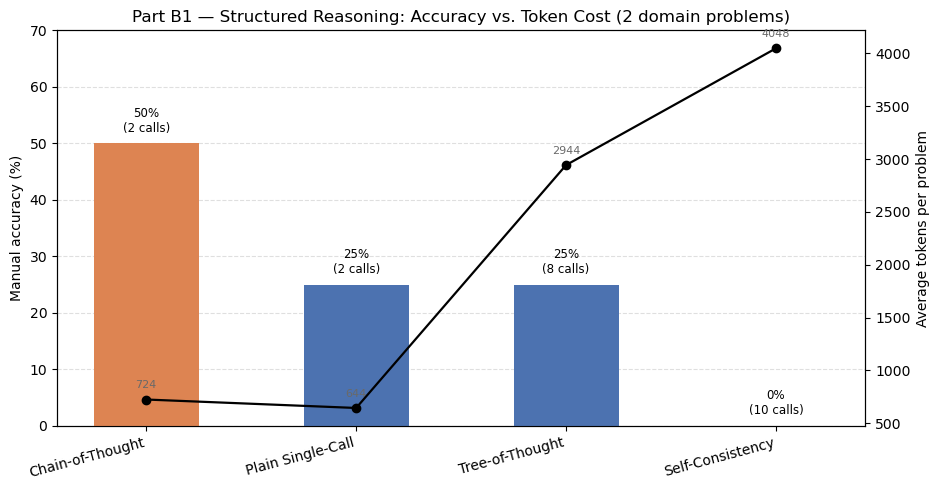

```
Orange bar = top-ranked technique by the cost-quality rule used in 8.6.
```

```python
# Visualization — Part B1 structured-reasoning comparison
import matplotlib.pyplot as plt
import numpy as np

order = sorted(part_b_b1_technique_summary, key=lambda r: r["cost_quality_rank"])
techniques = [r["technique"] for r in order]
acc = [r["normalised_accuracy_percent"] for r in order]
tokens = [r["average_tokens_per_problem"] for r in order]
calls = [r["total_model_calls"] for r in order]

fig, ax1 = plt.subplots(figsize=(9.5, 5))
x = np.arange(len(techniques))
colors = ["#DD8452" if r["cost_quality_rank"] == 1 else "#4C72B0" for r in order]

bars = ax1.bar(x, acc, width=0.5, color=colors, zorder=3)
ax1.set_xticks(x)
ax1.set_xticklabels(techniques, rotation=15, ha="right")
ax1.set_ylabel("Manual accuracy (%)")
ax1.set_ylim(0, max(acc) * 1.4)
ax1.grid(axis="y", linestyle="--", alpha=0.4, zorder=0)
ax1.set_title("Part B1 — Structured Reasoning: Accuracy vs. Token Cost (2 domain problems)")

for xi, val, call_count in zip(x, acc, calls):
    ax1.text(xi, val + 1.5, f"{val:.0f}%\n({call_count} calls)", ha="center", va="bottom", fontsize=8.5)

ax2 = ax1.twinx()
ax2.plot(x, tokens, color="black", marker="o", linewidth=1.6, zorder=4)
ax2.set_ylabel("Average tokens per problem")
for xi, val in zip(x, tokens):
    ax2.annotate(f"{val:.0f}", (xi, val), textcoords="offset points",
                 xytext=(0, 8), ha="center", fontsize=8, color="dimgray")

plt.tight_layout()
plt.show()

print("Orange bar = top-ranked technique by the cost-quality rule used in 8.6.")
```

### 8.7 Iterative Reasoning — ReAct

🔝 Back to Index

#### Purpose

ReAct combines model reasoning with external tool execution. Instead of relying on the model to perform calculations internally, the model selects a local tool, receives its verified observation, and uses that result in the next reasoning cycle.

#### Domain Problem

A production Linux log server has:

- `2,000 GB` usable capacity
- `92%` current utilisation
- `18 GB/day` growth
- A required target below `80%`

Verified cleanup candidates are:

- Expired application logs: `160 GB`, safe
- Package cache: `35 GB`, safe
- Orphaned temporary files: `40 GB`, safe
- Old crash dumps: `90 GB`, conditional on incident-owner approval
- Active audit logs: `120 GB`, prohibited from deletion

The agent determines:

1. Current used and free capacity
2. Minimum space reclaimed
3. Time remaining until 95% and 100% utilisation
4. The lowest-risk cleanup combination that reaches the target

#### Local Tools

The ReAct controller exposes three deterministic tools:

1. `assess_capacity`
2. `forecast_growth`
3. `select_cleanup_plan`

The model chooses one unused tool in each cycle. Tool arguments are normalised from the trusted scenario before execution, preventing unsupported values from entering the calculation.

```python
import csv
import itertools
import json
import math
import re
from datetime import datetime, timezone


# ==================================================================
# PART B2 — REACT CONFIGURATION
# ==================================================================

REACT_CYCLE_COUNT = 3
REACT_ACTION_MAX_NEW_TOKENS = 180
REACT_FINAL_MAX_NEW_TOKENS = 420

PART_B_REACT_JSON_PATH = (
    BENCHMARKS_DIR
    / "part_b_react_result.json"
)

PART_B_REACT_TRACE_CSV_PATH = (
    BENCHMARKS_DIR
    / "part_b_react_trace.csv"
)

PART_B_REACT_REPORT_PATH = (
    REPORTS_DIR
    / "part_b_react_report.json"
)


REACT_PROBLEM = {
    "problem_id": "REACT01",
    "title": "Production Log-Server Capacity Incident",
    "domain": "storage_capacity_incident",
    "risk_level": "high",
    "query": (
        "A production Linux log server has 2,000 GB of usable "
        "filesystem capacity and is currently 92% used. Usage is "
        "growing by 18 GB per day. Operations must reduce utilisation "
        "below 80% without deleting active audit logs. Verified cleanup "
        "candidates are: expired application logs 160 GB safe, package "
        "cache 35 GB safe, orphaned temporary files 40 GB safe, old "
        "crash dumps 90 GB conditional on incident-owner approval, and "
        "active audit logs 120 GB prohibited. Calculate the current "
        "capacity state, time until 95% and 100%, and the lowest-risk "
        "cleanup plan that reaches the target."
    ),
    "total_capacity_gb": 2000.0,
    "current_used_percent": 92.0,
    "target_used_percent": 80.0,
    "daily_growth_gb": 18.0,
    "warning_percent": 95.0,
    "full_percent": 100.0,
    "cleanup_candidates": [
        {
            "name": "Expired application logs",
            "reclaim_gb": 160.0,
            "risk": "safe",
            "allowed": True,
            "condition": None,
        },
        {
            "name": "Package cache",
            "reclaim_gb": 35.0,
            "risk": "safe",
            "allowed": True,
            "condition": None,
        },
        {
            "name": "Orphaned temporary files",
            "reclaim_gb": 40.0,
            "risk": "safe",
            "allowed": True,
            "condition": None,
        },
        {
            "name": "Old crash dumps",
            "reclaim_gb": 90.0,
            "risk": "conditional",
            "allowed": True,
            "condition": "Incident-owner approval required",
        },
        {
            "name": "Active audit logs",
            "reclaim_gb": 120.0,
            "risk": "prohibited",
            "allowed": False,
            "condition": "Must not be deleted",
        },
    ],
}


REACT_TOOL_DESCRIPTIONS = {
    "assess_capacity": (
        "Calculate current used space, free space, target maximum "
        "used space, and minimum reclaim requirement."
    ),
    "forecast_growth": (
        "Calculate days remaining until the warning and full-capacity "
        "thresholds at the confirmed daily growth rate."
    ),
    "select_cleanup_plan": (
        "Evaluate allowed cleanup combinations and select the "
        "lowest-risk plan that reaches the reclaim requirement."
    ),
}


REACT_SYSTEM_PROMPT = """
You are an enterprise IT incident-response agent using ReAct.

At each cycle, choose exactly one unused local tool. Return valid JSON
only with this structure:

{
  "thought": "Concise task-relevant reason for the next tool",
  "action": "one allowed tool name"
}

Do not calculate values yourself. Do not include an observation.
Do not repeat a previously executed tool.
""".strip()


REACT_FINAL_SYSTEM_PROMPT = """
You are a senior Linux operations engineer.

Use only the verified ReAct tool observations supplied in the prompt.
Do not recalculate using invented values.

Return:

1. Incident Assessment
2. Capacity Calculations
3. Growth Risk
4. Recommended Cleanup Plan
5. Safe Operational Procedure
6. Verification and Escalation Criteria

Clearly state that active audit logs must not be deleted and that any
conditional cleanup requires approval.
""".strip()


# ==================================================================
# LOCAL REACT TOOLS
# ==================================================================

def assess_capacity(
    total_capacity_gb,
    current_used_percent,
    target_used_percent,
):
    """
    Calculate current capacity and the minimum reclaim requirement.
    """

    current_used_gb = (
        total_capacity_gb
        * current_used_percent
        / 100.0
    )

    current_free_gb = (
        total_capacity_gb
        - current_used_gb
    )

    target_maximum_used_gb = (
        total_capacity_gb
        * target_used_percent
        / 100.0
    )

    minimum_reclaim_gb = max(
        0.0,
        current_used_gb
        - target_maximum_used_gb,
    )

    return {
        "total_capacity_gb": round(
            total_capacity_gb,
            2,
        ),
        "current_used_percent": round(
            current_used_percent,
            2,
        ),
        "current_used_gb": round(
            current_used_gb,
            2,
        ),
        "current_free_gb": round(
            current_free_gb,
            2,
        ),
        "target_used_percent": round(
            target_used_percent,
            2,
        ),
        "target_maximum_used_gb": round(
            target_maximum_used_gb,
            2,
        ),
        "minimum_reclaim_gb": round(
            minimum_reclaim_gb,
            2,
        ),
        "interpretation": (
            "At least this amount must be reclaimed to reach 80%. "
            "A small additional margin is preferable when the "
            "requirement is strictly below 80%."
        ),
    }


def forecast_growth(
    total_capacity_gb,
    current_used_percent,
    daily_growth_gb,
    warning_percent,
    full_percent,
):
    """
    Forecast the time remaining before warning and full thresholds.
    """

    current_used_gb = (
        total_capacity_gb
        * current_used_percent
        / 100.0
    )
```

```python
    warning_used_gb = (
        total_capacity_gb
        * warning_percent
        / 100.0
    )

    full_used_gb = (
        total_capacity_gb
        * full_percent
        / 100.0
    )

    remaining_to_warning_gb = max(
        0.0,
        warning_used_gb
        - current_used_gb,
    )

    remaining_to_full_gb = max(
        0.0,
        full_used_gb
        - current_used_gb,
    )

    days_to_warning = (
        remaining_to_warning_gb
        / daily_growth_gb
        if daily_growth_gb > 0
        else math.inf
    )

    days_to_full = (
        remaining_to_full_gb
        / daily_growth_gb
        if daily_growth_gb > 0
        else math.inf
    )

    return {
        "daily_growth_gb": round(
            daily_growth_gb,
            2,
        ),
        "warning_percent": round(
            warning_percent,
            2,
        ),
        "warning_used_gb": round(
            warning_used_gb,
            2,
        ),
        "remaining_to_warning_gb": round(
            remaining_to_warning_gb,
            2,
        ),
        "days_to_warning": round(
            days_to_warning,
            2,
        ),
        "full_percent": round(
            full_percent,
            2,
        ),
        "remaining_to_full_gb": round(
            remaining_to_full_gb,
            2,
        ),
        "days_to_full": round(
            days_to_full,
            2,
        ),
        "interpretation": (
            "The forecast assumes the observed 18 GB/day growth "
            "continues without cleanup or workload change."
        ),
    }


def select_cleanup_plan(
    total_capacity_gb,
    current_used_percent,
    target_used_percent,
    cleanup_candidates,
):
    """
    Select an allowed cleanup combination using this order:

    1. Reach the required reclaim amount
    2. Minimise the number of conditional items
    3. Minimise excess deletion
    4. Minimise the number of selected items
    """

    capacity_result = assess_capacity(
        total_capacity_gb=total_capacity_gb,
        current_used_percent=current_used_percent,
        target_used_percent=target_used_percent,
    )

    required_reclaim_gb = (
        capacity_result[
            "minimum_reclaim_gb"
        ]
    )

    allowed_candidates = [
        candidate
        for candidate in cleanup_candidates
        if candidate["allowed"]
        and candidate["risk"]
        != "prohibited"
    ]

    prohibited_candidates = [
        candidate
        for candidate in cleanup_candidates
        if not candidate["allowed"]
        or candidate["risk"]
        == "prohibited"
    ]

    feasible_plans = []

    for selection_size in range(
        1,
        len(allowed_candidates) + 1,
    ):
        for combination in itertools.combinations(
            allowed_candidates,
            selection_size,
        ):
            total_reclaim_gb = sum(
                candidate["reclaim_gb"]
                for candidate in combination
            )

            if total_reclaim_gb < required_reclaim_gb:
                continue

            conditional_count = sum(
                candidate["risk"]
                == "conditional"
                for candidate in combination
            )

            excess_reclaim_gb = (
                total_reclaim_gb
                - required_reclaim_gb
            )

            feasible_plans.append(
                {
                    "selected_candidates": [
                        candidate["name"]
                        for candidate in combination
                    ],
                    "selected_details": [
                        dict(candidate)
                        for candidate in combination
                    ],
                    "total_reclaim_gb": round(
                        total_reclaim_gb,
                        2,
                    ),
                    "conditional_count": (
                        conditional_count
                    ),
                    "excess_reclaim_gb": round(
                        excess_reclaim_gb,
                        2,
                    ),
                    "item_count": len(
                        combination
                    ),
                }
            )

    if not feasible_plans:
        return {
            "feasible": False,
            "required_reclaim_gb": (
                required_reclaim_gb
            ),
            "reason": (
                "No permitted cleanup combination reaches the target."
            ),
            "prohibited_candidates": [
                candidate["name"]
                for candidate in prohibited_candidates
            ],
        }

    selected_plan = sorted(
        feasible_plans,
        key=lambda plan: (
            plan["conditional_count"],
            plan["excess_reclaim_gb"],
            plan["item_count"],
            tuple(
                plan["selected_candidates"]
            ),
        ),
    )[0]

    current_used_gb = (
        total_capacity_gb
        * current_used_percent
        / 100.0
    )

    projected_used_gb = (
        current_used_gb
        - selected_plan[
            "total_reclaim_gb"
        ]
    )

    projected_used_percent = (
        projected_used_gb
        / total_capacity_gb
        * 100.0
    )

    safe_only_reclaim_gb = sum(
        candidate["reclaim_gb"]
        for candidate in allowed_candidates
        if candidate["risk"] == "safe"
    )

    return {
        "feasible": True,
        "required_reclaim_gb": round(
            required_reclaim_gb,
            2,
        ),
        "safe_only_reclaim_gb": round(
            safe_only_reclaim_gb,
            2,
        ),
        "safe_only_is_sufficient": (
            safe_only_reclaim_gb
            >= required_reclaim_gb
        ),
        "selection_policy": [
            "Reach required reclaim",
            "Minimise conditional items",
            "Minimise excess deletion",
            "Minimise selected item count",
        ],
        **selected_plan,
        "projected_used_gb": round(
            projected_used_gb,
            2,
        ),
        "projected_used_percent": round(
            projected_used_percent,
            2,
        ),
        "approval_required": any(
            detail["risk"] == "conditional"
            for detail in selected_plan[
                "selected_details"
            ]
        ),
        "prohibited_candidates": [
            candidate["name"]
            for candidate in prohibited_candidates
        ],
        "warning": (
            "Active audit logs are prohibited from deletion. "
            "Old crash dumps require incident-owner approval."
        ),
    }
```

````python
REACT_LOCAL_TOOLS = {
    "assess_capacity": assess_capacity,
    "forecast_growth": forecast_growth,
    "select_cleanup_plan": (
        select_cleanup_plan
    ),
}


# ==================================================================
# TRUSTED TOOL INPUT NORMALISATION
# ==================================================================

def build_react_tool_input(
    tool_name,
    scenario,
):
    """
    Supply trusted scenario values instead of accepting invented
    numerical arguments from the model.
    """

    if tool_name == "assess_capacity":
        return {
            "total_capacity_gb": (
                scenario[
                    "total_capacity_gb"
                ]
            ),
            "current_used_percent": (
                scenario[
                    "current_used_percent"
                ]
            ),
            "target_used_percent": (
                scenario[
                    "target_used_percent"
                ]
            ),
        }

    if tool_name == "forecast_growth":
        return {
            "total_capacity_gb": (
                scenario[
                    "total_capacity_gb"
                ]
            ),
            "current_used_percent": (
                scenario[
                    "current_used_percent"
                ]
            ),
            "daily_growth_gb": (
                scenario[
                    "daily_growth_gb"
                ]
            ),
            "warning_percent": (
                scenario[
                    "warning_percent"
                ]
            ),
            "full_percent": (
                scenario[
                    "full_percent"
                ]
            ),
        }

    if tool_name == "select_cleanup_plan":
        return {
            "total_capacity_gb": (
                scenario[
                    "total_capacity_gb"
                ]
            ),
            "current_used_percent": (
                scenario[
                    "current_used_percent"
                ]
            ),
            "target_used_percent": (
                scenario[
                    "target_used_percent"
                ]
            ),
            "cleanup_candidates": (
                scenario[
                    "cleanup_candidates"
                ]
            ),
        }

    raise KeyError(
        f"Unknown ReAct tool: {tool_name}"
    )


# ==================================================================
# JSON ACTION PARSING
# ==================================================================

def extract_first_json_object(
    text,
):
    """
    Extract the first balanced JSON object from model output.
    """

    cleaned_text = str(text).strip()

    fenced_match = re.search(
        r"```(?:json)?\s*(\{.*?\})\s*```",
        cleaned_text,
        flags=re.IGNORECASE | re.DOTALL,
    )

    if fenced_match:
        cleaned_text = (
            fenced_match.group(1)
        )

    try:
        parsed = json.loads(
            cleaned_text
        )

        if isinstance(parsed, dict):
            return parsed

    except json.JSONDecodeError:
        pass

    start_index = cleaned_text.find(
        "{"
    )

    if start_index < 0:
        return None

    depth = 0
    in_string = False
    escaped = False

    for index in range(
        start_index,
        len(cleaned_text),
    ):
        character = cleaned_text[
            index
        ]

        if escaped:
            escaped = False
            continue

        if character == "\\":
            escaped = True
            continue

        if character == '"':
            in_string = not in_string
            continue

        if in_string:
            continue

        if character == "{":
            depth += 1

        elif character == "}":
            depth -= 1

            if depth == 0:
                candidate = cleaned_text[
                    start_index:index + 1
                ]

                try:
                    parsed = json.loads(
                        candidate
                    )

                    if isinstance(
                        parsed,
                        dict,
                    ):
                        return parsed

                except json.JSONDecodeError:
                    return None

    return None


def parse_react_action(
    raw_response,
    remaining_tools,
):
    """
    Parse one model-selected action and apply a deterministic controller
    fallback when the response is malformed or repeats a tool.
    """

    parsed_json = extract_first_json_object(
        raw_response
    )

    parse_success = (
        isinstance(parsed_json, dict)
    )

    thought = ""

    requested_action = None

    if parse_success:
        thought = str(
            parsed_json.get(
                "thought",
                "",
            )
        ).strip()

        requested_action = str(
            parsed_json.get(
                "action",
                "",
            )
        ).strip()

    controller_corrected = False
    correction_reason = None

    if requested_action not in remaining_tools:
        controller_corrected = True

        correction_reason = (
            "The model action was missing, invalid, "
            "or already executed."
        )

        requested_action = (
            remaining_tools[0]
        )

    if not thought:
        thought = (
            f"Use {requested_action} to obtain the next "
            "verified observation."
        )

    return {
        "thought": thought,
        "action": requested_action,
        "parse_success": parse_success,
        "controller_corrected": (
            controller_corrected
        ),
        "correction_reason": (
            correction_reason
        ),
        "parsed_json": parsed_json,
    }


# ==================================================================
# REACT PROMPT BUILDERS
# ==================================================================
````

```python
def build_react_cycle_prompt(
    scenario,
    trace,
    remaining_tools,
    cycle_number,
):
    """
    Include all earlier observations in every subsequent cycle.
    """

    available_tool_text = "\n".join(
        (
            f"- {tool_name}: "
            f"{REACT_TOOL_DESCRIPTIONS[tool_name]}"
        )
        for tool_name in remaining_tools
    )

    if trace:
        previous_trace_text = "\n\n".join(
            [
                (
                    f"Cycle {record['cycle_number']}\n"
                    f"Action: {record['action']}\n"
                    f"Observation: "
                    f"{json.dumps(record['observation'], ensure_ascii=False)}"
                )
                for record in trace
            ]
        )
    else:
        previous_trace_text = (
            "No previous observations."
        )

    return f"""
Problem:
{scenario["query"]}

Current cycle:
{cycle_number} of {REACT_CYCLE_COUNT}

Unused local tools:
{available_tool_text}

Previous Action and Observation trace:
{previous_trace_text}

Choose the single most useful unused tool for the next verified step.
Return only the required JSON object.
""".strip()


def build_react_final_prompt(
    scenario,
    trace,
):
    """
    Build final synthesis using only verified local observations.
    """

    trace_text = "\n\n".join(
        [
            (
                f"Cycle {record['cycle_number']}\n"
                f"Thought: {record['thought']}\n"
                f"Action: {record['action']}\n"
                f"Action Input: "
                f"{json.dumps(record['action_input'], ensure_ascii=False)}\n"
                f"Observation: "
                f"{json.dumps(record['observation'], ensure_ascii=False)}"
            )
            for record in trace
        ]
    )

    return f"""
Incident:
{scenario["query"]}

Verified ReAct trace:
{trace_text}

Prepare the final incident-resolution response using only these
observations. Include the exact calculated values and approval or
prohibition conditions.
""".strip()


# ==================================================================
# EXECUTE THREE REACT CYCLES
# ==================================================================

react_trace = []

remaining_tools = list(
    REACT_LOCAL_TOOLS
)

react_total_input_tokens = 0
react_total_output_tokens = 0
react_total_latency_sec = 0.0
react_capped_call_count = 0


for cycle_number in range(
    1,
    REACT_CYCLE_COUNT + 1,
):
    cycle_prompt = build_react_cycle_prompt(
        scenario=REACT_PROBLEM,
        trace=react_trace,
        remaining_tools=remaining_tools,
        cycle_number=cycle_number,
    )

    raw_cycle_result = generate_with_metrics(
        user_prompt=cycle_prompt,
        system_prompt=REACT_SYSTEM_PROMPT,
        max_new_tokens=(
            REACT_ACTION_MAX_NEW_TOKENS
        ),
    )

    cycle_metrics = normalise_generation_result(
        raw_cycle_result
    )

    cycle_metrics = (
        apply_derived_generation_cap(
            metrics=cycle_metrics,
            max_new_tokens=(
                REACT_ACTION_MAX_NEW_TOKENS
            ),
        )
    )

    action_decision = parse_react_action(
        raw_response=cycle_metrics[
            "generated_response"
        ],
        remaining_tools=remaining_tools,
    )

    selected_action = (
        action_decision["action"]
    )

    action_input = build_react_tool_input(
        tool_name=selected_action,
        scenario=REACT_PROBLEM,
    )

    observation = REACT_LOCAL_TOOLS[
        selected_action
    ](
        **action_input
    )

    trace_record = {
        "cycle_number": cycle_number,
        "thought": (
            action_decision[
                "thought"
            ]
        ),
        "action": selected_action,
        "action_input": action_input,
        "observation": observation,
        "raw_model_response": (
            cycle_metrics[
                "generated_response"
            ]
        ),
        "parse_success": (
            action_decision[
                "parse_success"
            ]
        ),
        "controller_corrected": (
            action_decision[
                "controller_corrected"
            ]
        ),
        "correction_reason": (
            action_decision[
                "correction_reason"
            ]
        ),
        "previous_observation_count": (
            len(react_trace)
        ),
        "input_tokens": (
            cycle_metrics[
                "input_tokens"
            ]
        ),
        "output_tokens": (
            cycle_metrics[
                "output_tokens"
            ]
        ),
        "total_tokens": (
            cycle_metrics[
                "total_tokens"
            ]
        ),
        "latency_sec": (
            cycle_metrics[
                "latency_sec"
            ]
        ),
        "generation_capped": (
            cycle_metrics[
                "generation_capped"
            ]
        ),
    }

    react_trace.append(
        trace_record
    )

    remaining_tools.remove(
        selected_action
    )

    react_total_input_tokens += (
        cycle_metrics[
            "input_tokens"
        ]
    )

    react_total_output_tokens += (
        cycle_metrics[
            "output_tokens"
        ]
    )

    react_total_latency_sec += (
        cycle_metrics[
            "latency_sec"
        ]
    )

    react_capped_call_count += int(
        cycle_metrics[
            "generation_capped"
        ]
    )


# ==================================================================
# FINAL ANSWER FROM THE COMPLETE TRACE
# ==================================================================

react_final_prompt = build_react_final_prompt(
    scenario=REACT_PROBLEM,
    trace=react_trace,
)


raw_final_result = generate_with_metrics(
    user_prompt=react_final_prompt,
    system_prompt=(
        REACT_FINAL_SYSTEM_PROMPT
    ),
    max_new_tokens=(
        REACT_FINAL_MAX_NEW_TOKENS
    ),
)


final_metrics = normalise_generation_result(
    raw_final_result
)
```

```python
final_metrics = apply_derived_generation_cap(
    metrics=final_metrics,
    max_new_tokens=(
        REACT_FINAL_MAX_NEW_TOKENS
    ),
)


react_total_input_tokens += (
    final_metrics[
        "input_tokens"
    ]
)

react_total_output_tokens += (
    final_metrics[
        "output_tokens"
    ]
)

react_total_latency_sec += (
    final_metrics[
        "latency_sec"
    ]
)

react_capped_call_count += int(
    final_metrics[
        "generation_capped"
    ]
)


# ==================================================================
# CREATE CANONICAL REACT RESULT
# ==================================================================

part_b_react_result = {
    "problem_id": (
        REACT_PROBLEM[
            "problem_id"
        ]
    ),
    "problem_title": (
        REACT_PROBLEM[
            "title"
        ]
    ),
    "domain": (
        REACT_PROBLEM[
            "domain"
        ]
    ),
    "risk_level": (
        REACT_PROBLEM[
            "risk_level"
        ]
    ),
    "technique": "ReAct",
    "query": (
        REACT_PROBLEM[
            "query"
        ]
    ),
    "cycle_count": len(
        react_trace
    ),
    "trace": react_trace,
    "final_response": (
        final_metrics[
            "generated_response"
        ]
    ),
    "final_response_metrics": (
        final_metrics
    ),
    "model_calls": (
        REACT_CYCLE_COUNT + 1
    ),
    "local_tool_calls": len(
        react_trace
    ),
    "executed_tools": [
        record["action"]
        for record in react_trace
    ],
    "controller_correction_count": sum(
        record[
            "controller_corrected"
        ]
        for record in react_trace
    ),
    "action_parse_success_count": sum(
        record[
            "parse_success"
        ]
        for record in react_trace
    ),
    "total_input_tokens": (
        react_total_input_tokens
    ),
    "total_output_tokens": (
        react_total_output_tokens
    ),
    "total_tokens": (
        react_total_input_tokens
        + react_total_output_tokens
    ),
    "total_latency_sec": round(
        react_total_latency_sec,
        4,
    ),
    "generation_capped_call_count": (
        react_capped_call_count
    ),
    "run_timestamp_utc": (
        datetime.now(
            timezone.utc
        ).isoformat()
    ),
}


# ==================================================================
# SAVE JSON ARTIFACT
# ==================================================================

with PART_B_REACT_JSON_PATH.open(
    "w",
    encoding="utf-8",
) as json_file:
    json.dump(
        part_b_react_result,
        json_file,
        indent=2,
        ensure_ascii=False,
    )


# ==================================================================
# SAVE TRACE CSV
# ==================================================================

react_trace_csv_fields = [
    "cycle_number",
    "thought",
    "action",
    "action_input",
    "observation",
    "parse_success",
    "controller_corrected",
    "correction_reason",
    "previous_observation_count",
    "input_tokens",
    "output_tokens",
    "total_tokens",
    "latency_sec",
    "generation_capped",
]


with PART_B_REACT_TRACE_CSV_PATH.open(
    "w",
    encoding="utf-8",
    newline="",
) as csv_file:
    writer = csv.DictWriter(
        csv_file,
        fieldnames=react_trace_csv_fields,
    )

    writer.writeheader()

    for record in react_trace:
        csv_record = {
            field_name: record.get(
                field_name,
                "",
            )
            for field_name
            in react_trace_csv_fields
        }

        csv_record["action_input"] = (
            json.dumps(
                record[
                    "action_input"
                ],
                ensure_ascii=False,
            )
        )

        csv_record["observation"] = (
            json.dumps(
                record[
                    "observation"
                ],
                ensure_ascii=False,
            )
        )

        writer.writerow(
            csv_record
        )


# ==================================================================
# BUILD REPORT
# ==================================================================

capacity_observation = next(
    record["observation"]
    for record in react_trace
    if record["action"]
    == "assess_capacity"
)

growth_observation = next(
    record["observation"]
    for record in react_trace
    if record["action"]
    == "forecast_growth"
)

cleanup_observation = next(
    record["observation"]
    for record in react_trace
    if record["action"]
    == "select_cleanup_plan"
)


part_b_react_report = {
    "requirement": (
        "Thought → Action → Observation loop "
        "with at least three cycles"
    ),
    "cycle_count": len(
        react_trace
    ),
    "local_tool_calls": len(
        react_trace
    ),
    "observation_feed_counts": [
        record[
            "previous_observation_count"
        ]
        for record in react_trace
    ],
    "verified_results": {
        "current_used_gb": (
            capacity_observation[
                "current_used_gb"
            ]
        ),
        "current_free_gb": (
            capacity_observation[
                "current_free_gb"
            ]
        ),
        "minimum_reclaim_gb": (
            capacity_observation[
                "minimum_reclaim_gb"
            ]
        ),
        "days_to_95_percent": (
            growth_observation[
                "days_to_warning"
            ]
        ),
        "days_to_100_percent": (
            growth_observation[
                "days_to_full"
            ]
        ),
        "selected_cleanup_items": (
            cleanup_observation[
                "selected_candidates"
            ]
        ),
        "selected_reclaim_gb": (
            cleanup_observation[
                "total_reclaim_gb"
            ]
        ),
        "projected_used_percent": (
            cleanup_observation[
                "projected_used_percent"
            ]
        ),
        "approval_required": (
            cleanup_observation[
                "approval_required"
            ]
        ),
    },
    "result_artifact": str(
        PART_B_REACT_JSON_PATH
    ),
    "trace_artifact": str(
        PART_B_REACT_TRACE_CSV_PATH
    ),
}
```

```python
with PART_B_REACT_REPORT_PATH.open(
    "w",
    encoding="utf-8",
) as report_file:
    json.dump(
        part_b_react_report,
        report_file,
        indent=2,
        ensure_ascii=False,
    )


# ==================================================================
# VALIDATION
# ==================================================================

react_validation_checks = {
    "At least three ReAct cycles executed": (
        len(react_trace) >= 3
    ),
    "Exactly three local tool calls executed": (
        len(react_trace) == 3
    ),
    "Every Action invoked a registered local tool": all(
        record["action"]
        in REACT_LOCAL_TOOLS
        for record in react_trace
    ),
    "All three local tools were used once": (
        set(
            record["action"]
            for record in react_trace
        )
        == set(
            REACT_LOCAL_TOOLS
        )
    ),
    "Observations accumulated across cycles": (
        [
            record[
                "previous_observation_count"
            ]
            for record in react_trace
        ]
        == [
            0,
            1,
            2,
        ]
    ),
    "Every observation contains structured data": all(
        isinstance(
            record["observation"],
            dict,
        )
        and bool(
            record["observation"]
        )
        for record in react_trace
    ),
    "Final answer is present": bool(
        part_b_react_result[
            "final_response"
        ]
    ),
    "Four total model calls were used": (
        part_b_react_result[
            "model_calls"
        ]
        == 4
    ),
    "Aggregate token count is positive": (
        part_b_react_result[
            "total_tokens"
        ]
        > 0
    ),
    "Aggregate latency is positive": (
        part_b_react_result[
            "total_latency_sec"
        ]
        > 0
    ),
    "Capacity calculation is correct": (
        capacity_observation[
            "current_used_gb"
        ]
        == 1840.0
        and capacity_observation[
            "current_free_gb"
        ]
        == 160.0
        and capacity_observation[
            "minimum_reclaim_gb"
        ]
        == 240.0
    ),
    "Growth forecast is correct": (
        growth_observation[
            "days_to_warning"
        ]
        == 3.33
        and growth_observation[
            "days_to_full"
        ]
        == 8.89
    ),
    "Cleanup plan reaches below eighty percent": (
        cleanup_observation[
            "projected_used_percent"
        ]
        < 80.0
    ),
    "Active audit logs are excluded": (
        "Active audit logs"
        not in cleanup_observation[
            "selected_candidates"
        ]
    ),
}


# ==================================================================
# DISPLAY FULL REACT TRACE
# ==================================================================

print("PART B2 — REACT FULL TRACE")
print("=" * 125)


for record in react_trace:
    print(
        f"\nCYCLE {record['cycle_number']}"
    )

    print("-" * 125)

    print(
        f"Thought     : "
        f"{record['thought']}"
    )

    print(
        f"Action      : "
        f"{record['action']}"
    )

    print(
        "Action Input:"
    )

    print(
        json.dumps(
            record[
                "action_input"
            ],
            indent=2,
            ensure_ascii=False,
        )
    )

    print(
        "Observation:"
    )

    print(
        json.dumps(
            record[
                "observation"
            ],
            indent=2,
            ensure_ascii=False,
        )
    )

    print(
        f"Parse success       : "
        f"{record['parse_success']}"
    )

    print(
        f"Controller corrected: "
        f"{record['controller_corrected']}"
    )

    print(
        f"Previous observations supplied: "
        f"{record['previous_observation_count']}"
    )

    print(
        f"Tokens: {record['total_tokens']} | "
        f"Latency: {record['latency_sec']:.4f}s | "
        f"Capped: {record['generation_capped']}"
    )


print(
    "\nFINAL REACT ANSWER"
)

print("-" * 125)

print(
    part_b_react_result[
        "final_response"
    ]
)

print("-" * 125)

print(
    f"Model calls          : "
    f"{part_b_react_result['model_calls']}"
)

print(
    f"Local tool calls     : "
    f"{part_b_react_result['local_tool_calls']}"
)

print(
    f"Total tokens         : "
    f"{part_b_react_result['total_tokens']}"
)

print(
    f"Total latency        : "
    f"{part_b_react_result['total_latency_sec']:.4f}s"
)

print(
    f"Controller corrections: "
    f"{part_b_react_result['controller_correction_count']}"
)


print("\nVALIDATION")
print("-" * 125)


for check_name, passed in (
    react_validation_checks.items()
):
    print(
        f"{check_name:<72} : "
        f"{'PASS' if passed else 'FAIL'}"
    )


print("-" * 125)

print(
    f"Result JSON : "
    f"{PART_B_REACT_JSON_PATH}"
)

print(
    f"Trace CSV   : "
    f"{PART_B_REACT_TRACE_CSV_PATH}"
)

print(
    f"Report JSON : "
    f"{PART_B_REACT_REPORT_PATH}"
)

print("=" * 125)


if not all(
    react_validation_checks.values()
):
    failed_checks = [
        check_name
        for check_name, passed
        in react_validation_checks.items()
        if not passed
    ]

    raise RuntimeError(
        "Part B2 ReAct validation failed for: "
        + ", ".join(failed_checks)
    )


print(
    "Part B2 ReAct execution completed successfully."
)
```

```
PART B2 — REACT FULL TRACE
=============================================================================================================================

CYCLE 1
-----------------------------------------------------------------------------------------------------------------------------
Thought     : Calculate the current capacity state, time until 95% and 100%, and the lowest-risk cleanup plan that reaches the target.
Action      : assess_capacity
Action Input:
{
  "total_capacity_gb": 2000.0,
  "current_used_percent": 92.0,
  "target_used_percent": 80.0
}
Observation:
{
  "total_capacity_gb": 2000.0,
  "current_used_percent": 92.0,
  "current_used_gb": 1840.0,
  "current_free_gb": 160.0,
  "target_used_percent": 80.0,
  "target_maximum_used_gb": 1600.0,
  "minimum_reclaim_gb": 240.0,
  "interpretation": "At least this amount must be reclaimed to reach 80%. A small additional margin is preferable when the requirement is strictly below 80%."
}
Parse success       : True
Controller corrected: False
Previous observations supplied: 0
Tokens: 388 | Latency: 2.6392s | Capped: False

CYCLE 2
-----------------------------------------------------------------------------------------------------------------------------
Thought     : Forecast growth to determine how long it will take to reach 95% and 100% capacity.
Action      : forecast_growth
Action Input:
{
  "total_capacity_gb": 2000.0,
  "current_used_percent": 92.0,
  "daily_growth_gb": 18.0,
  "warning_percent": 95.0,
  "full_percent": 100.0
```

[output cut: 165 more lines]

```
Every observation contains structured data                               : PASS
Final answer is present                                                  : PASS
Four total model calls were used                                         : PASS
Aggregate token count is positive                                        : PASS
Aggregate latency is positive                                            : PASS
Capacity calculation is correct                                          : PASS
Growth forecast is correct                                               : PASS
Cleanup plan reaches below eighty percent                                : PASS
Active audit logs are excluded                                           : PASS
-----------------------------------------------------------------------------------------------------------------------------
Result JSON : /home/jovyan/llmlab/assignment2a_workspace_20260731_182730/benchmarks/part_b_react_result.json
Trace CSV   : /home/jovyan/llmlab/assignment2a_workspace_20260731_182730/benchmarks/part_b_react_trace.csv
Report JSON : /home/jovyan/llmlab/assignment2a_workspace_20260731_182730/reports/part_b_react_report.json
=============================================================================================================================
Part B2 ReAct execution completed successfully.
```

#### Observation

🔝 Back to Index

The ReAct implementation satisfied the required three `Thought → Action → Observation` cycles. Every action invoked a registered local function, and the accumulated observations were supplied to subsequent cycles without controller correction.

The tools correctly established:

- Current usage: `1,840 GB`
- Current free capacity: `160 GB`
- Minimum reclaim requirement: `240 GB`
- Time to 95%: `3.33 days`
- Time to full capacity: `8.89 days`
- Selected cleanup: expired application logs plus approved old crash dumps
- Projected utilisation: `79.5%`

The final model response preserved the verified calculations but did not explicitly name both selected cleanup items. The ReAct mechanics are complete, while final-answer completeness remains a separate quality consideration.

### 8.8 Custom Chain 1 — Plan → Solve → Verify

🔝 Back to Index

#### Purpose

The `Plan → Solve → Verify` chain separates high-stakes resolution into three controlled stages:

1. **Plan**  
   Identify the evidence, dependencies, remediation order, verification gates, and rollback requirements without immediately performing destructive actions.
2. **Solve**  
   Convert the approved plan into a concrete operational procedure.
3. **Verify**  
   Independently compare the draft against the problem-specific critical requirements and material-error constraints, then produce a corrected final answer.

#### Application

The chain is applied to both multi-step domain problems:

- MSP01 — Post-Change VPN Gateway Outage
- MSP02 — Compromised Administrator Account and Persistence

Each problem requires three model calls. The stage outputs, token consumption, latency, cap status, and final response are stored for later comparison with the Plain Single-Call baseline.

```python
import csv
import json
from datetime import datetime, timezone


# ==================================================================
# PART B3 — PLAN → SOLVE → VERIFY CONFIGURATION
# ==================================================================

PSV_PLAN_MAX_NEW_TOKENS = 260
PSV_SOLVE_MAX_NEW_TOKENS = 420
PSV_VERIFY_MAX_NEW_TOKENS = 500


PART_B_PSV_JSON_PATH = (
    BENCHMARKS_DIR
    / "part_b_plan_solve_verify_results.json"
)

PART_B_PSV_CSV_PATH = (
    BENCHMARKS_DIR
    / "part_b_plan_solve_verify_results.csv"
)

PART_B_PSV_CHECKPOINT_PATH = (
    BENCHMARKS_DIR
    / "part_b_plan_solve_verify_checkpoint.json"
)

PART_B_PSV_REPORT_PATH = (
    REPORTS_DIR
    / "part_b_plan_solve_verify_report.json"
)


PSV_PLAN_SYSTEM_PROMPT = """
You are a senior enterprise IT incident planner.

Create a concise operational plan for the supplied high-stakes problem.

Rules:

- Use only confirmed facts.
- Do not invent versions, paths, users, interfaces, services, or causes.
- Preserve evidence before destructive remediation.
- Use successful health signals to avoid unnecessary changes.
- Include dependencies, safe ordering, verification gates, and rollback.
- Do not provide speculative internal reasoning.
- Do not produce the final answer yet.

Return only:

1. Confirmed Situation
2. Immediate Safety Controls
3. Evidence and Diagnostic Plan
4. Remediation Plan
5. Verification Gates
6. Rollback or Escalation Plan
""".strip()


PSV_SOLVE_SYSTEM_PROMPT = """
You are a senior enterprise IT operations and incident-response engineer.

Convert the supplied approved plan into a concrete operational
resolution procedure.

Rules:

- Use only facts from the problem and plan.
- Preserve evidence before destructive action.
- Use exact supplied account, service, interface, subnet, and host scope.
- Include persistence, verification, and rollback.
- Do not reproduce prompt instructions.
- Avoid repetition.
- Do not claim that an action succeeded unless verification proves it.

Return only:

1. Diagnosis
2. Evidence Preservation
3. Ordered Remediation
4. Persistence or Recovery Controls
5. Verification
6. Rollback or Escalation Criteria
""".strip()


PSV_VERIFY_SYSTEM_PROMPT = """
You are an independent senior incident-response verifier.

Review the supplied problem, plan, and draft procedure against the
provided critical requirements and prohibited material errors.

Correct the procedure before returning it.

Rules:

- Preserve evidence before destructive remediation.
- Use only confirmed values from the problem.
- Remove invented facts and unsupported commands.
- Do not delete or reset healthy components unnecessarily.
- Ensure the complete affected scope is addressed.
- Include persistence, verification gates, rollback, and monitoring.
- Do not reproduce the evaluation checklist, prompt instructions,
  review notes, or scoring commentary.
- Return only the corrected operational answer.

Required final structure:

1. Diagnosis
2. Evidence Preservation
3. Ordered Remediation
4. Persistence or Recovery Controls
5. Verification
6. Rollback or Escalation Criteria
""".strip()


PSV_CONTROL_MARKERS = [
    "Critical requirements that must be satisfied:",
    "Material errors that must be avoided:",
    "Approved plan:",
    "Draft procedure:",
    "Verifier notes:",
    "Evaluation checklist:",
]


# ==================================================================
# PROBLEM FIELD HELPERS
# ==================================================================

def get_problem_list_field(
    problem,
    possible_keys,
):
    """
    Return the first available list-valued problem field.
    """

    for key in possible_keys:
        value = problem.get(key)

        if isinstance(value, list):
            return value

    return []


def format_list_items(items):
    """
    Format a list for insertion into a prompt.
    """

    if not items:
        return "- Not explicitly provided"

    return "\n".join(
        f"- {item}"
        for item in items
    )


def clean_psv_final_response(
    response_text,
):
    """
    Remove copied prompt-control material while retaining the raw
    verifier response separately for auditability.
    """

    cleaned_text = str(
        response_text
    ).strip()

    lower_text = cleaned_text.lower()
    marker_positions = []

    for marker in PSV_CONTROL_MARKERS:
        marker_position = lower_text.find(
            marker.lower()
        )

        if marker_position >= 0:
            marker_positions.append(
                marker_position
            )

    if marker_positions:
        cleaned_text = cleaned_text[
            :min(marker_positions)
        ].rstrip()

    return cleaned_text


# ==================================================================
# PROMPT BUILDERS
# ==================================================================

def build_psv_plan_prompt(
    problem,
):
    confirmed_observations = (
        get_problem_list_field(
            problem,
            [
                "confirmed_observations",
                "confirmed_facts",
                "observations",
            ],
        )
    )

    return f"""
Problem ID:
{problem["problem_id"]}

Problem:
{problem["query"]}

Confirmed observations:
{format_list_items(confirmed_observations)}

Produce the operational plan only. Prioritise evidence preservation,
safe ordering, exact scope, verification, and rollback.
""".strip()


def build_psv_solve_prompt(
    problem,
    plan_response,
):
    return f"""
Problem ID:
{problem["problem_id"]}

Problem:
{problem["query"]}

Approved plan:
{plan_response}

Convert this plan into a complete and technically safe operational
procedure. Do not omit persistence, verification, rollback, or
cross-host scope where applicable.
""".strip()


def build_psv_verify_prompt(
    problem,
    plan_response,
    draft_response,
):
    critical_requirements = (
        get_problem_list_field(
            problem,
            [
                "critical_requirements",
                "required_elements",
                "success_requirements",
            ],
        )
    )
```

```python
    material_errors = (
        get_problem_list_field(
            problem,
            [
                "material_errors",
                "prohibited_actions",
                "unsafe_actions",
            ],
        )
    )

    return f"""
Problem ID:
{problem["problem_id"]}

Problem:
{problem["query"]}

Approved plan:
{plan_response}

Draft procedure:
{draft_response}

Critical requirements that must be satisfied:
{format_list_items(critical_requirements)}

Material errors that must be avoided:
{format_list_items(material_errors)}

Silently verify and correct the draft. Return only the final corrected
operational procedure under the six required headings.
""".strip()


# ==================================================================
# STAGE EXECUTION HELPER
# ==================================================================

def run_psv_stage(
    problem_id,
    stage_name,
    system_prompt,
    user_prompt,
    max_new_tokens,
):
    """
    Execute and measure one Plan → Solve → Verify stage.
    """

    raw_result = generate_with_metrics(
        user_prompt=user_prompt,
        system_prompt=system_prompt,
        max_new_tokens=max_new_tokens,
    )

    metrics = normalise_generation_result(
        raw_result
    )

    metrics = apply_derived_generation_cap(
        metrics=metrics,
        max_new_tokens=max_new_tokens,
    )

    return {
        "problem_id": problem_id,
        "stage": stage_name,
        "system_prompt": system_prompt,
        "user_prompt": user_prompt,
        **metrics,
        "run_timestamp_utc": (
            datetime.now(
                timezone.utc
            ).isoformat()
        ),
    }


# ==================================================================
# EXECUTE PLAN → SOLVE → VERIFY ON BOTH PROBLEMS
# ==================================================================

part_b_psv_results = []


for problem in part_b_multistep_problems:
    problem_id = problem[
        "problem_id"
    ]

    print(
        f"\nRunning Plan → Solve → Verify for "
        f"{problem_id}..."
    )


    # --------------------------------------------------------------
    # Stage 1 — Plan
    # --------------------------------------------------------------

    print("  Stage 1/3 — Plan")

    plan_stage = run_psv_stage(
        problem_id=problem_id,
        stage_name="Plan",
        system_prompt=(
            PSV_PLAN_SYSTEM_PROMPT
        ),
        user_prompt=(
            build_psv_plan_prompt(
                problem
            )
        ),
        max_new_tokens=(
            PSV_PLAN_MAX_NEW_TOKENS
        ),
    )


    # --------------------------------------------------------------
    # Stage 2 — Solve
    # --------------------------------------------------------------

    print("  Stage 2/3 — Solve")

    solve_stage = run_psv_stage(
        problem_id=problem_id,
        stage_name="Solve",
        system_prompt=(
            PSV_SOLVE_SYSTEM_PROMPT
        ),
        user_prompt=(
            build_psv_solve_prompt(
                problem=problem,
                plan_response=(
                    plan_stage[
                        "generated_response"
                    ]
                ),
            )
        ),
        max_new_tokens=(
            PSV_SOLVE_MAX_NEW_TOKENS
        ),
    )


    # --------------------------------------------------------------
    # Stage 3 — Verify
    # --------------------------------------------------------------

    print("  Stage 3/3 — Verify")

    verify_stage = run_psv_stage(
        problem_id=problem_id,
        stage_name="Verify",
        system_prompt=(
            PSV_VERIFY_SYSTEM_PROMPT
        ),
        user_prompt=(
            build_psv_verify_prompt(
                problem=problem,
                plan_response=(
                    plan_stage[
                        "generated_response"
                    ]
                ),
                draft_response=(
                    solve_stage[
                        "generated_response"
                    ]
                ),
            )
        ),
        max_new_tokens=(
            PSV_VERIFY_MAX_NEW_TOKENS
        ),
    )


    raw_final_response = (
        verify_stage[
            "generated_response"
        ]
    )

    cleaned_final_response = (
        clean_psv_final_response(
            raw_final_response
        )
    )


    final_diagnostic_scoring = (
        score_tot_candidate(
            problem_id=problem_id,
            response_text=(
                cleaned_final_response
            ),
        )
    )


    stage_records = [
        plan_stage,
        solve_stage,
        verify_stage,
    ]


    total_input_tokens = sum(
        stage["input_tokens"]
        for stage in stage_records
    )

    total_output_tokens = sum(
        stage["output_tokens"]
        for stage in stage_records
    )

    total_latency_sec = round(
        sum(
            stage["latency_sec"]
            for stage in stage_records
        ),
        4,
    )


    copied_control_markers = [
        marker
        for marker in PSV_CONTROL_MARKERS
        if marker.lower()
        in raw_final_response.lower()
    ]


    problem_result = {
        "problem_id": problem_id,
        "problem_title": (
            problem["title"]
        ),
        "domain": problem["domain"],
        "risk_level": (
            problem["risk_level"]
        ),
        "technique": (
            "Plan-Solve-Verify"
        ),
        "query": problem["query"],
        "stages": stage_records,
        "plan_response": (
            plan_stage[
                "generated_response"
            ]
        ),
        "solve_response": (
            solve_stage[
                "generated_response"
            ]
        ),
        "verify_response_raw": (
            raw_final_response
        ),
        "final_response": (
            cleaned_final_response
        ),
        "final_response_scoring": (
            final_diagnostic_scoring
        ),
        "copied_control_markers": (
            copied_control_markers
        ),
        "model_calls": 3,
        "total_input_tokens": (
            total_input_tokens
        ),
        "total_output_tokens": (
            total_output_tokens
        ),
        "total_tokens": (
            total_input_tokens
            + total_output_tokens
        ),
        "total_latency_sec": (
            total_latency_sec
        ),
        "capped_stage_count": sum(
            stage["generation_capped"]
            for stage in stage_records
        ),
        "run_timestamp_utc": (
            datetime.now(
                timezone.utc
            ).isoformat()
        ),
    }
```

```python
    part_b_psv_results.append(
        problem_result
    )


    with PART_B_PSV_CHECKPOINT_PATH.open(
        "w",
        encoding="utf-8",
    ) as checkpoint_file:
        json.dump(
            part_b_psv_results,
            checkpoint_file,
            indent=2,
            ensure_ascii=False,
        )


# ==================================================================
# SAVE CANONICAL JSON
# ==================================================================

with PART_B_PSV_JSON_PATH.open(
    "w",
    encoding="utf-8",
) as json_file:
    json.dump(
        part_b_psv_results,
        json_file,
        indent=2,
        ensure_ascii=False,
    )


# ==================================================================
# SAVE SUMMARY CSV
# ==================================================================

psv_csv_fields = [
    "problem_id",
    "problem_title",
    "technique",
    "model_calls",
    "total_input_tokens",
    "total_output_tokens",
    "total_tokens",
    "total_latency_sec",
    "capped_stage_count",
    "automated_score",
    "automated_maximum",
    "copied_control_markers",
    "plan_response",
    "solve_response",
    "final_response",
]


with PART_B_PSV_CSV_PATH.open(
    "w",
    encoding="utf-8",
    newline="",
) as csv_file:
    writer = csv.DictWriter(
        csv_file,
        fieldnames=psv_csv_fields,
    )

    writer.writeheader()


    for result in part_b_psv_results:
        writer.writerow(
            {
                "problem_id": (
                    result["problem_id"]
                ),
                "problem_title": (
                    result["problem_title"]
                ),
                "technique": (
                    result["technique"]
                ),
                "model_calls": (
                    result["model_calls"]
                ),
                "total_input_tokens": (
                    result[
                        "total_input_tokens"
                    ]
                ),
                "total_output_tokens": (
                    result[
                        "total_output_tokens"
                    ]
                ),
                "total_tokens": (
                    result["total_tokens"]
                ),
                "total_latency_sec": (
                    result[
                        "total_latency_sec"
                    ]
                ),
                "capped_stage_count": (
                    result[
                        "capped_stage_count"
                    ]
                ),
                "automated_score": (
                    result[
                        "final_response_scoring"
                    ][
                        "final_score"
                    ]
                ),
                "automated_maximum": (
                    result[
                        "final_response_scoring"
                    ][
                        "maximum_score"
                    ]
                ),
                "copied_control_markers": (
                    json.dumps(
                        result[
                            "copied_control_markers"
                        ],
                        ensure_ascii=False,
                    )
                ),
                "plan_response": (
                    result["plan_response"]
                ),
                "solve_response": (
                    result["solve_response"]
                ),
                "final_response": (
                    result["final_response"]
                ),
            }
        )


# ==================================================================
# SAVE DESIGN REPORT
# ==================================================================

part_b_psv_report = {
    "chain_name": (
        "Plan → Solve → Verify"
    ),
    "intended_use": (
        "High-stakes operational and incident-response queries"
    ),
    "stage_count_per_problem": 3,
    "problems_evaluated": [
        result["problem_id"]
        for result in part_b_psv_results
    ],
    "stage_definitions": {
        "Plan": (
            "Establish evidence, dependencies, order, "
            "verification gates, and rollback."
        ),
        "Solve": (
            "Convert the approved plan into a concrete "
            "operational procedure."
        ),
        "Verify": (
            "Check the draft against reference requirements "
            "and return a corrected final procedure."
        ),
    },
    "results": [
        {
            "problem_id": (
                result["problem_id"]
            ),
            "model_calls": (
                result["model_calls"]
            ),
            "total_tokens": (
                result["total_tokens"]
            ),
            "total_latency_sec": (
                result[
                    "total_latency_sec"
                ]
            ),
            "capped_stage_count": (
                result[
                    "capped_stage_count"
                ]
            ),
            "automated_diagnostic_score": (
                result[
                    "final_response_scoring"
                ][
                    "final_score"
                ]
            ),
            "automated_diagnostic_maximum": (
                result[
                    "final_response_scoring"
                ][
                    "maximum_score"
                ]
            ),
        }
        for result in part_b_psv_results
    ],
}


with PART_B_PSV_REPORT_PATH.open(
    "w",
    encoding="utf-8",
) as report_file:
    json.dump(
        part_b_psv_report,
        report_file,
        indent=2,
        ensure_ascii=False,
    )


# ==================================================================
# VALIDATION
# ==================================================================

expected_psv_stages = {
    "Plan",
    "Solve",
    "Verify",
}


psv_validation_checks = {
    "Two problems were evaluated": (
        len(part_b_psv_results) == 2
    ),
    "Both required problem IDs are present": (
        {
            result["problem_id"]
            for result in part_b_psv_results
        }
        == {
            "MSP01",
            "MSP02",
        }
    ),
    "Every problem contains three stages": all(
        len(result["stages"]) == 3
        for result in part_b_psv_results
    ),
    "Every problem contains Plan, Solve, and Verify": all(
        {
            stage["stage"]
            for stage in result["stages"]
        }
        == expected_psv_stages
        for result in part_b_psv_results
    ),
    "Each problem used three model calls": all(
        result["model_calls"] == 3
        for result in part_b_psv_results
    ),
    "All stage responses contain text": all(
        stage["generated_response"]
        for result in part_b_psv_results
        for stage in result["stages"]
    ),
    "All cleaned final responses contain text": all(
        result["final_response"]
        for result in part_b_psv_results
    ),
    "No copied control marker remains in final answer": all(
        not any(
            marker.lower()
            in result["final_response"].lower()
            for marker in PSV_CONTROL_MARKERS
        )
        for result in part_b_psv_results
    ),
    "All aggregate token counts are positive": all(
        result["total_tokens"] > 0
        for result in part_b_psv_results
    ),
    "All aggregate latencies are positive": all(
        result["total_latency_sec"] > 0
        for result in part_b_psv_results
    ),
    "JSON artifact exists": (
        PART_B_PSV_JSON_PATH.exists()
    ),
    "CSV artifact exists": (
        PART_B_PSV_CSV_PATH.exists()
    ),
    "Report artifact exists": (
        PART_B_PSV_REPORT_PATH.exists()
    ),
}
```

```python
# ==================================================================
# DISPLAY FULL CHAIN OUTPUTS
# ==================================================================

print(
    "PART B3 — PLAN → SOLVE → VERIFY RESULTS"
)

print("=" * 130)


for result in part_b_psv_results:
    print(
        f"\n{result['problem_id']} — "
        f"{result['problem_title']}"
    )

    print("-" * 130)

    for stage in result["stages"]:
        print(
            f"\n{stage['stage'].upper()} STAGE"
        )

        print("-" * 130)

        print(
            stage[
                "generated_response"
            ]
        )

        print("-" * 130)

        print(
            f"Input tokens: "
            f"{stage['input_tokens']} | "
            f"Output tokens: "
            f"{stage['output_tokens']} | "
            f"Total tokens: "
            f"{stage['total_tokens']} | "
            f"Latency: "
            f"{stage['latency_sec']:.4f}s | "
            f"Capped: "
            f"{stage['generation_capped']}"
        )


    print(
        "\nFINAL CLEANED RESPONSE"
    )

    print("-" * 130)

    print(
        result["final_response"]
    )

    print("-" * 130)

    print(
        f"Diagnostic score: "
        f"{result['final_response_scoring']['final_score']}/"
        f"{result['final_response_scoring']['maximum_score']} | "
        f"Model calls: {result['model_calls']} | "
        f"Total tokens: {result['total_tokens']} | "
        f"Total latency: "
        f"{result['total_latency_sec']:.4f}s | "
        f"Capped stages: "
        f"{result['capped_stage_count']}/3"
    )


print("\n" + "=" * 130)
print("VALIDATION")
print("-" * 130)


for check_name, passed in (
    psv_validation_checks.items()
):
    print(
        f"{check_name:<72} : "
        f"{'PASS' if passed else 'FAIL'}"
    )


print("-" * 130)

print(
    f"Results JSON : "
    f"{PART_B_PSV_JSON_PATH}"
)

print(
    f"Results CSV  : "
    f"{PART_B_PSV_CSV_PATH}"
)

print(
    f"Checkpoint   : "
    f"{PART_B_PSV_CHECKPOINT_PATH}"
)

print(
    f"Report JSON  : "
    f"{PART_B_PSV_REPORT_PATH}"
)

print("=" * 130)


if not all(
    psv_validation_checks.values()
):
    failed_checks = [
        check_name
        for check_name, passed
        in psv_validation_checks.items()
        if not passed
    ]

    raise RuntimeError(
        "Plan → Solve → Verify validation failed for: "
        + ", ".join(failed_checks)
    )


print(
    "Plan → Solve → Verify execution completed successfully."
)
```

```
Running Plan → Solve → Verify for MSP01...
  Stage 1/3 — Plan
  Stage 2/3 — Solve
  Stage 3/3 — Verify

Running Plan → Solve → Verify for MSP02...
  Stage 1/3 — Plan
  Stage 2/3 — Solve
  Stage 3/3 — Verify
PART B3 — PLAN → SOLVE → VERIFY RESULTS
==================================================================================================================================

MSP01 — Post-Change VPN Gateway Outage
----------------------------------------------------------------------------------------------------------------------------------

PLAN STAGE
----------------------------------------------------------------------------------------------------------------------------------
1. Confirmed Situation
- WireGuard handshake succeeds.
- VPN subnet is 10.90.90.0/24.
- Outbound interface is eth0.
- net.ipv4.ip_forward currently evaluates to 0.
- No subnet-specific MASQUERADE rule is present.
- The gateway0 systemd unit changed on disk.

2. Immediate Safety Controls
- Ensure all WireGuard clients have completed their handshakes.
- Ensure all WireGuard clients are configured to use the correct IP address for the gateway0 interface.
- Ensure all WireGuard clients are configured to use the correct DNS server for the gateway0 interface.
- Ensure all WireGuard clients are configured to use the correct default route for the gateway0 interface.
- Ensure all WireGuard clients are configured to use the correct MTU for the gateway0 interface.
- Ensure all WireGuard clients are configured to use the correct IP protocol version for the gateway0 interface.
- Ensure all WireGuard clients are configured to use the correct IP protocol number for the gateway0 interface.
- Ensure all WireGuard clients are configured to use the correct IP protocol family for the gateway0 interface.
- Ensure all WireGuard clients are configured to use the correct IP protocol type for the gateway0 interface.
- Ensure all Wire
----------------------------------------------------------------------------------------------------------------------------------
Input tokens: 378 | Output tokens: 260 | Total tokens: 638 | Latency: 14.8263s | Capped: True

SOLVE STAGE
```

[output cut: 285 more lines]

```
All stage responses contain text                                         : PASS
All cleaned final responses contain text                                 : PASS
No copied control marker remains in final answer                         : PASS
All aggregate token counts are positive                                  : PASS
All aggregate latencies are positive                                     : PASS
JSON artifact exists                                                     : PASS
CSV artifact exists                                                      : PASS
Report artifact exists                                                   : PASS
----------------------------------------------------------------------------------------------------------------------------------
Results JSON : /home/jovyan/llmlab/assignment2a_workspace_20260731_182730/benchmarks/part_b_plan_solve_verify_results.json
Results CSV  : /home/jovyan/llmlab/assignment2a_workspace_20260731_182730/benchmarks/part_b_plan_solve_verify_results.csv
Checkpoint   : /home/jovyan/llmlab/assignment2a_workspace_20260731_182730/benchmarks/part_b_plan_solve_verify_checkpoint.json
Report JSON  : /home/jovyan/llmlab/assignment2a_workspace_20260731_182730/reports/part_b_plan_solve_verify_report.json
==================================================================================================================================
Plan → Solve → Verify execution completed successfully.
```

#### Observation

🔝 Back to Index

The `Plan → Solve → Verify` chain executed correctly as a three-stage workflow for both problems, and all structural validations passed.

For MSP01, all three stages reached their generation limits and repeated speculative client-configuration checks instead of producing the required forwarding, NAT, persistence, verification, and rollback procedure. Its final diagnostic score was only `3/16`.

For MSP02, the chain produced broader coverage and scored `12/20`, but it still contained unsafe sequencing. It disabled SSH access and the suspicious service before clearly preserving evidence, and later proposed re-enabling the suspicious `backup-sync.service`. It also omitted targeted session termination, credential rotation, trusted-rebuild criteria, and recurrence monitoring.

These results are retained without post-hoc regeneration. They demonstrate that adding verification stages does not guarantee correction when earlier-stage errors are propagated through the chain.

### 8.9 Custom Chain 2 — Decompose → Solve-each → Synthesise

🔝 Back to Index

#### Purpose

The `Decompose → Solve-each → Synthesise` chain is designed for problems containing several interdependent technical workstreams.

The chain separates the task into three stages:

1. **Decompose**  
   Divide the incident into four distinct operational subproblems.
2. **Solve-each**  
   Produce a focused solution for every identified subproblem while preserving dependencies and safety constraints.
3. **Synthesise**  
   Merge the individual solutions into one ordered incident-resolution procedure, remove contradictions, and apply problem-specific verification and rollback requirements.

#### Application

The chain is applied to:

- MSP01 — Post-Change VPN Gateway Outage
- MSP02 — Compromised Administrator Account and Persistence

Each problem uses three model calls. The implementation records:

- Parsed subproblems
- Per-subproblem solutions
- Final synthesised response
- Token and latency measurements
- Generation-limit status
- Automated diagnostic requirement coverage

The final quality score will later be assigned through the same manual reference-grounded review used for the other reasoning techniques.

```python
import csv
import json
import re
from datetime import datetime, timezone


# ==================================================================
# PART B3 — DECOMPOSE → SOLVE-EACH → SYNTHESISE CONFIGURATION
# ==================================================================

DSS_DECOMPOSE_MAX_NEW_TOKENS = 200
DSS_SOLVE_EACH_MAX_NEW_TOKENS = 480
DSS_SYNTHESISE_MAX_NEW_TOKENS = 500

DSS_EXPECTED_SUBPROBLEM_COUNT = 4


PART_B_DSS_JSON_PATH = (
    BENCHMARKS_DIR
    / "part_b_decompose_solve_synthesise_results.json"
)

PART_B_DSS_CSV_PATH = (
    BENCHMARKS_DIR
    / "part_b_decompose_solve_synthesise_results.csv"
)

PART_B_DSS_CHECKPOINT_PATH = (
    BENCHMARKS_DIR
    / "part_b_decompose_solve_synthesise_checkpoint.json"
)

PART_B_DSS_REPORT_PATH = (
    REPORTS_DIR
    / "part_b_decompose_solve_synthesise_report.json"
)


DSS_DECOMPOSE_SYSTEM_PROMPT = """
You are a senior enterprise incident architect.

Divide the supplied multi-part technical problem into exactly four
non-overlapping operational subproblems.

Rules:

- Use only confirmed facts.
- Do not invent causes, systems, users, versions, paths, or commands.
- Cover evidence, remediation, persistence or recovery, verification,
  and rollback across the four subproblems.
- Keep each subproblem concise.
- Do not solve the subproblems yet.
- Return exactly four lines using this format:

SUBPROBLEM_1: <description>
SUBPROBLEM_2: <description>
SUBPROBLEM_3: <description>
SUBPROBLEM_4: <description>
""".strip()


DSS_SOLVE_EACH_SYSTEM_PROMPT = """
You are a senior enterprise IT operations and incident-response
engineer.

Solve each supplied subproblem separately.

Rules:

- Use only the confirmed facts in the original problem.
- Preserve evidence before destructive remediation.
- Do not invent software versions, users, interfaces, subnets,
  services, paths, or evidence.
- Respect the dependency order between subproblems.
- Use exact supplied values.
- Provide no more than four concise bullets per subproblem.
- Include concrete verification or completion criteria.
- Do not merge the subproblems yet.

Return:

SOLUTION_1:
- ...

SOLUTION_2:
- ...

SOLUTION_3:
- ...

SOLUTION_4:
- ...
""".strip()


DSS_SYNTHESISE_SYSTEM_PROMPT = """
You are an independent senior enterprise incident-response engineer.

Merge the supplied subproblem solutions into one safe and ordered
operational procedure.

Rules:

- Use only confirmed facts and supported actions.
- Preserve evidence before destructive changes.
- Remove duplicated, contradictory, invented, or unsafe steps.
- Use exact supplied users, services, interfaces, subnets, and scope.
- Do not reset or replace healthy components unnecessarily.
- Ensure persistence or recovery controls are included.
- Ensure verification, rollback, and escalation criteria are included.
- Do not reproduce prompt instructions, checklists, or evaluation text.
- Return only the final operational procedure.
- Use no more than six concise bullets under each heading.

Required headings:

1. Diagnosis
2. Evidence Preservation
3. Ordered Remediation
4. Persistence or Recovery Controls
5. Verification
6. Rollback or Escalation Criteria
""".strip()


DSS_CONTROL_MARKERS = [
    "Critical requirements:",
    "Material errors to avoid:",
    "Parsed subproblems:",
    "Per-subproblem solutions:",
    "Evaluation checklist:",
    "Prompt instructions:",
]


# ==================================================================
# DOMAIN-SPECIFIC FALLBACK DECOMPOSITIONS
# ==================================================================

DSS_FALLBACK_SUBPROBLEMS = {
    "MSP01": [
        {
            "subproblem_id": "SUBPROBLEM_1",
            "description": (
                "Preserve and inspect the current WireGuard, systemd, "
                "sysctl, routing, firewall, NAT, and log state."
            ),
        },
        {
            "subproblem_id": "SUBPROBLEM_2",
            "description": (
                "Restore and persist IPv4 forwarding while retaining "
                "the already-successful WireGuard handshake."
            ),
        },
        {
            "subproblem_id": "SUBPROBLEM_3",
            "description": (
                "Restore the exact 10.90.90.0/24 MASQUERADE path through "
                "eth0 and safely reload the changed gateway0 unit."
            ),
        },
        {
            "subproblem_id": "SUBPROBLEM_4",
            "description": (
                "Verify service, forwarding, NAT, routing, WireGuard, "
                "and end-to-end connectivity, with rollback criteria."
            ),
        },
    ],

    "MSP02": [
        {
            "subproblem_id": "SUBPROBLEM_1",
            "description": (
                "Contain the affected host and preserve volatile, log, "
                "process, network, session, and suspicious-file evidence."
            ),
        },
        {
            "subproblem_id": "SUBPROBLEM_2",
            "description": (
                "Protect opsuser, quarantine the unknown authorised key, "
                "and terminate only the identified compromised session."
            ),
        },
        {
            "subproblem_id": "SUBPROBLEM_3",
            "description": (
                "Investigate and remove backup-sync.service persistence "
                "after evidence capture and scope the vulnerable package "
                "across all three related hosts."
            ),
        },
        {
            "subproblem_id": "SUBPROBLEM_4",
            "description": (
                "Patch, rotate affected credentials, determine whether a "
                "trusted rebuild is required, validate before reconnecting, "
                "and monitor recurrence."
            ),
        },
    ],
}


# ==================================================================
# GENERIC PROBLEM-FIELD HELPERS
# ==================================================================

def get_dss_problem_list_field(
    problem,
    possible_keys,
):
    """
    Return the first available list-valued field from a problem record.
    """
```

```python
    for key in possible_keys:
        value = problem.get(key)

        if isinstance(value, list):
            return value

    return []


def format_dss_list(items):
    """
    Format a sequence as prompt-ready bullet points.
    """

    if not items:
        return "- Not explicitly provided"

    return "\n".join(
        f"- {item}"
        for item in items
    )


# ==================================================================
# DECOMPOSITION PARSER
# ==================================================================

def parse_dss_subproblems(
    problem_id,
    decomposition_response,
):
    """
    Parse SUBPROBLEM_1 through SUBPROBLEM_4.

    A transparent domain-specific fallback is used when the model
    response does not contain four valid subproblems.
    """

    parsed_subproblems = []

    pattern = re.compile(
        r"SUBPROBLEM[_\s-]*(\d+)\s*:\s*"
        r"(.*?)(?="
        r"\n\s*SUBPROBLEM[_\s-]*\d+\s*:|"
        r"\Z)",
        flags=re.IGNORECASE | re.DOTALL,
    )

    matches = pattern.findall(
        str(decomposition_response).strip()
    )

    for number_text, description in matches:
        number = int(number_text)

        cleaned_description = re.sub(
            r"\s+",
            " ",
            description,
        ).strip(" -\n\t")

        if (
            1 <= number
            <= DSS_EXPECTED_SUBPROBLEM_COUNT
            and cleaned_description
        ):
            parsed_subproblems.append(
                {
                    "subproblem_id": (
                        f"SUBPROBLEM_{number}"
                    ),
                    "description": (
                        cleaned_description
                    ),
                }
            )


    # Remove duplicates and restore numeric order.
    unique_subproblems = {}

    for subproblem in parsed_subproblems:
        unique_subproblems[
            subproblem["subproblem_id"]
        ] = subproblem


    parsed_subproblems = sorted(
        unique_subproblems.values(),
        key=lambda item: int(
            item["subproblem_id"].split(
                "_"
            )[-1]
        ),
    )


    fallback_used = (
        len(parsed_subproblems)
        != DSS_EXPECTED_SUBPROBLEM_COUNT
    )


    if fallback_used:
        parsed_subproblems = [
            dict(item)
            for item in DSS_FALLBACK_SUBPROBLEMS[
                problem_id
            ]
        ]


    return {
        "subproblems": parsed_subproblems,
        "fallback_used": fallback_used,
        "model_parsed_count": len(
            unique_subproblems
        ),
    }


# ==================================================================
# SYNTHESIS CLEANING
# ==================================================================

def clean_dss_final_response(
    response_text,
):
    """
    Remove copied prompt-control content from the final synthesis.
    """

    cleaned_text = str(
        response_text
    ).strip()

    lower_text = cleaned_text.lower()
    marker_positions = []


    for marker in DSS_CONTROL_MARKERS:
        marker_position = lower_text.find(
            marker.lower()
        )

        if marker_position >= 0:
            marker_positions.append(
                marker_position
            )


    if marker_positions:
        cleaned_text = cleaned_text[
            :min(marker_positions)
        ].rstrip()


    return cleaned_text


# ==================================================================
# PROMPT BUILDERS
# ==================================================================

def build_dss_decompose_prompt(
    problem,
):
    confirmed_observations = (
        get_dss_problem_list_field(
            problem,
            [
                "confirmed_observations",
                "confirmed_facts",
                "observations",
            ],
        )
    )

    return f"""
Problem ID:
{problem["problem_id"]}

Problem:
{problem["query"]}

Confirmed observations:
{format_dss_list(confirmed_observations)}

Divide the problem into exactly four operational subproblems. Ensure
that all required incident phases can later be solved and synthesised.
""".strip()


def build_dss_solve_each_prompt(
    problem,
    parsed_subproblems,
):
    confirmed_observations = (
        get_dss_problem_list_field(
            problem,
            [
                "confirmed_observations",
                "confirmed_facts",
                "observations",
            ],
        )
    )


    subproblem_text = "\n".join(
        (
            f"{subproblem['subproblem_id']}: "
            f"{subproblem['description']}"
        )
        for subproblem
        in parsed_subproblems
    )


    return f"""
Problem ID:
{problem["problem_id"]}

Original problem:
{problem["query"]}

Confirmed observations:
{format_dss_list(confirmed_observations)}

Subproblems:
{subproblem_text}

Solve all four subproblems separately. Preserve the supplied numbering
and return SOLUTION_1 through SOLUTION_4.
""".strip()


def build_dss_synthesise_prompt(
    problem,
    parsed_subproblems,
    solve_each_response,
):
    critical_requirements = (
        get_dss_problem_list_field(
            problem,
            [
                "critical_requirements",
                "required_elements",
                "success_requirements",
            ],
        )
    )

    material_errors = (
        get_dss_problem_list_field(
            problem,
            [
                "material_errors",
                "prohibited_actions",
                "unsafe_actions",
            ],
        )
    )


    subproblem_text = "\n".join(
        (
            f"- {subproblem['subproblem_id']}: "
            f"{subproblem['description']}"
        )
        for subproblem
        in parsed_subproblems
    )


    return f"""
Problem ID:
{problem["problem_id"]}

Original problem:
{problem["query"]}

Parsed subproblems:
{subproblem_text}

Per-subproblem solutions:
{solve_each_response}

Critical requirements:
{format_dss_list(critical_requirements)}
```

```python
Material errors to avoid:
{format_dss_list(material_errors)}

Silently reconcile the four solutions and return only one complete,
safe, ordered, and non-repetitive operational procedure.
""".strip()


# ==================================================================
# STAGE EXECUTION
# ==================================================================

def run_dss_stage(
    problem_id,
    stage_name,
    system_prompt,
    user_prompt,
    max_new_tokens,
):
    """
    Execute one deterministic stage and return normalised metrics.
    """

    raw_result = generate_with_metrics(
        user_prompt=user_prompt,
        system_prompt=system_prompt,
        max_new_tokens=max_new_tokens,
    )


    metrics = normalise_generation_result(
        raw_result
    )


    metrics = apply_derived_generation_cap(
        metrics=metrics,
        max_new_tokens=max_new_tokens,
    )


    return {
        "problem_id": problem_id,
        "stage": stage_name,
        "system_prompt": system_prompt,
        "user_prompt": user_prompt,
        **metrics,
        "run_timestamp_utc": (
            datetime.now(
                timezone.utc
            ).isoformat()
        ),
    }


# ==================================================================
# EXECUTE DECOMPOSE → SOLVE-EACH → SYNTHESISE
# ==================================================================

part_b_dss_results = []


for problem in part_b_multistep_problems:
    problem_id = problem[
        "problem_id"
    ]


    print(
        f"\nRunning Decompose → Solve-each → Synthesise "
        f"for {problem_id}..."
    )


    # --------------------------------------------------------------
    # Stage 1 — Decompose
    # --------------------------------------------------------------

    print("  Stage 1/3 — Decompose")

    decompose_stage = run_dss_stage(
        problem_id=problem_id,
        stage_name="Decompose",
        system_prompt=(
            DSS_DECOMPOSE_SYSTEM_PROMPT
        ),
        user_prompt=(
            build_dss_decompose_prompt(
                problem
            )
        ),
        max_new_tokens=(
            DSS_DECOMPOSE_MAX_NEW_TOKENS
        ),
    )


    decomposition_parse = (
        parse_dss_subproblems(
            problem_id=problem_id,
            decomposition_response=(
                decompose_stage[
                    "generated_response"
                ]
            ),
        )
    )


    parsed_subproblems = (
        decomposition_parse[
            "subproblems"
        ]
    )


    # --------------------------------------------------------------
    # Stage 2 — Solve each subproblem
    # --------------------------------------------------------------

    print("  Stage 2/3 — Solve-each")

    solve_each_stage = run_dss_stage(
        problem_id=problem_id,
        stage_name="Solve-each",
        system_prompt=(
            DSS_SOLVE_EACH_SYSTEM_PROMPT
        ),
        user_prompt=(
            build_dss_solve_each_prompt(
                problem=problem,
                parsed_subproblems=(
                    parsed_subproblems
                ),
            )
        ),
        max_new_tokens=(
            DSS_SOLVE_EACH_MAX_NEW_TOKENS
        ),
    )


    # --------------------------------------------------------------
    # Stage 3 — Synthesise
    # --------------------------------------------------------------

    print("  Stage 3/3 — Synthesise")

    synthesise_stage = run_dss_stage(
        problem_id=problem_id,
        stage_name="Synthesise",
        system_prompt=(
            DSS_SYNTHESISE_SYSTEM_PROMPT
        ),
        user_prompt=(
            build_dss_synthesise_prompt(
                problem=problem,
                parsed_subproblems=(
                    parsed_subproblems
                ),
                solve_each_response=(
                    solve_each_stage[
                        "generated_response"
                    ]
                ),
            )
        ),
        max_new_tokens=(
            DSS_SYNTHESISE_MAX_NEW_TOKENS
        ),
    )


    raw_final_response = (
        synthesise_stage[
            "generated_response"
        ]
    )


    cleaned_final_response = (
        clean_dss_final_response(
            raw_final_response
        )
    )


    final_diagnostic_scoring = (
        score_tot_candidate(
            problem_id=problem_id,
            response_text=(
                cleaned_final_response
            ),
        )
    )


    stage_records = [
        decompose_stage,
        solve_each_stage,
        synthesise_stage,
    ]


    total_input_tokens = sum(
        stage["input_tokens"]
        for stage in stage_records
    )

    total_output_tokens = sum(
        stage["output_tokens"]
        for stage in stage_records
    )

    total_latency_sec = round(
        sum(
            stage["latency_sec"]
            for stage in stage_records
        ),
        4,
    )


    copied_control_markers = [
        marker
        for marker in DSS_CONTROL_MARKERS
        if marker.lower()
        in raw_final_response.lower()
    ]


    problem_result = {
        "problem_id": problem_id,
        "problem_title": (
            problem["title"]
        ),
        "domain": problem["domain"],
        "risk_level": (
            problem["risk_level"]
        ),
        "technique": (
            "Decompose-Solve-Synthesise"
        ),
        "query": problem["query"],
        "stages": stage_records,
        "decomposition_response": (
            decompose_stage[
                "generated_response"
            ]
        ),
        "parsed_subproblems": (
            parsed_subproblems
        ),
        "decomposition_fallback_used": (
            decomposition_parse[
                "fallback_used"
            ]
        ),
        "model_parsed_subproblem_count": (
            decomposition_parse[
                "model_parsed_count"
            ]
        ),
        "solve_each_response": (
            solve_each_stage[
                "generated_response"
            ]
        ),
        "synthesise_response_raw": (
            raw_final_response
        ),
        "final_response": (
            cleaned_final_response
        ),
        "final_response_scoring": (
            final_diagnostic_scoring
        ),
        "copied_control_markers": (
            copied_control_markers
        ),
        "model_calls": 3,
        "total_input_tokens": (
            total_input_tokens
        ),
        "total_output_tokens": (
            total_output_tokens
        ),
        "total_tokens": (
            total_input_tokens
            + total_output_tokens
        ),
        "total_latency_sec": (
            total_latency_sec
        ),
        "capped_stage_count": sum(
            stage["generation_capped"]
            for stage in stage_records
        ),
        "run_timestamp_utc": (
            datetime.now(
                timezone.utc
            ).isoformat()
        ),
    }
```

[output not shown]